# Match day 9 Season 2627

Liverpool vs Arsenal - 01-11-2026

|  | Possession Possession % | Possession On Ball Time | Possession Touches | Possession PKBox Touches | Possession Field Tilt % | Shots Total Shots | Shots OFF Shots | Shots ONT Shots | Shots 6yrd box Shots | Shots PK Box Shots | Shots Outside Box Shots | Shots Blocked Shots | Shots BCs | Shots Goals | Shots xG | Shots NPxG | Shots xGOT | Threat EPV | Threat EPV % xG Con. | Threat EPV % NPxG Con. | Passes Attempted Passes | Passes Successful Passes | Passes Pass Success % | Passes Long Passes | Passes Long Ball Rate | Passes Crosses | Passes Cross Success % | Passes Corners | Passes Short Corners | … |
| --- | --- | --- | --- | --- | --- | --- | --- | --- | --- | --- | --- | --- | --- | --- | --- | --- | --- | --- | --- | --- | --- | --- | --- | --- | --- | --- | --- | --- | --- | --- |
| 1st Quarter |  |  |  |  |  |  |  |  |  |  |  |  |  |  |  |  |  |  |  |  |  |  |  |  |  |  |  |  |  | … |
| Arsenal | 56.1% | 11.60 | 176 | 11 | 72.6% | 4 | 2 | 2 | 1 | 3 | 1 | 0 | 1 | 1 | 0.77 | 0.77 | 1.09 | 1.09 | 70.3% | 70.3% | 112 | 93 | 83.0% | 12 | 10.7% | 4 | 50.0% | 1 | 1 | … |
| Liverpool | 43.9% | 9.90 | 138 | 7 | 27.4% | 0 | 0 | 0 | 0 | 0 | 0 | 0 | 0 | 0 | 0.00 | 0.00 | 0.00 | 0.21 | 0.0% | 0.0% | 85 | 65 | 76.5% | 12 | 14.1% | 6 | 0.0% | 2 | 0 | … |
| 2nd Quarter |  |  |  |  |  |  |  |  |  |  |  |  |  |  |  |  |  |  |  |  |  |  |  |  |  |  |  |  |  | … |
| Arsenal | 38.4% | 5.90 | 116 | 4 | 21.3% | 1 | 0 | 0 | 0 | 0 | 1 | 1 | 0 | 0 | 0.05 | 0.05 | 0.00 | 0.26 | 19.6% | 19.6% | 67 | 44 | 65.7% | 12 | 17.9% | 0 | 0.0% | 0 | 0 | … |
| Liverpool | 61.6% | 11.40 | 186 | 24 | 78.7% | 8 | 6 | 0 | 0 | 6 | 2 | 2 | 1 | 0 | 0.41 | 0.41 | 0.00 | 1.21 | 34.0% | 34.0% | 129 | 113 | 87.6% | 7 | 5.4% | 12 | 33.3% | 4 | 1 | … |
| 3rd Quarter |  |  |  |  |  |  |  |  |  |  |  |  |  |  |  |  |  |  |  |  |  |  |  |  |  |  |  |  |  | … |
| Arsenal | 51.7% | 11.80 | 183 | 4 | 55.4% | 3 | 1 | 0 | 0 | 1 | 2 | 2 | 0 | 0 | 0.10 | 0.10 | 0.00 | 0.37 | 27.0% | 27.0% | 120 | 89 | 74.2% | 25 | 20.8% | 3 | 0.0% | 2 | 1 | … |
| Liverpool | 48.3% | 8.30 | 171 | 9 | 44.6% | 3 | 1 | 0 | 0 | 3 | 0 | 2 | 0 | 0 | 0.27 | 0.27 | 0.00 | 0.55 | 48.8% | 48.8% | 114 | 87 | 76.3% | 13 | 11.4% | 5 | 0.0% | 0 | 0 | … |
| 4th Quarter |  |  |  |  |  |  |  |  |  |  |  |  |  |  |  |  |  |  |  |  |  |  |  |  |  |  |  |  |  | … |
| Arsenal | 39.2% | 10.50 | 127 | 5 | 20.7% | 2 | 1 | 1 | 1 | 2 | 0 | 0 | 0 | 0 | 0.07 | 0.07 | 0.36 | 0.36 | 19.2% | 19.2% | 73 | 43 | 58.9% | 16 | 21.9% | 3 | 66.7% | 1 | 0 | … |
| Liverpool | 60.8% | 9.30 | 197 | 15 | 79.3% | 6 | 1 | 0 | 1 | 5 | 1 | 5 | 0 | 0 | 0.37 | 0.37 | 0.00 | 1.17 | 31.7% | 31.7% | 136 | 115 | 84.6% | 12 | 8.8% | 10 | 10.0% | 1 | 0 | … |

X @Barts78 · Bluesky @barts78 · Mastodon @DrBarts · GitHub Barts78 · LinkedIn Phil-barter · Data: Opta

**Match Summary - By Game State**

Liverpool vs Arsenal - 01-11-2026

|  | Possession Possession % | Possession On Ball Time | Possession Touches | Possession PKBox Touches | Possession Field Tilt % | Shots Total Shots | Shots OFF Shots | Shots SoT | Shots 6yrd box Shots | Shots PK Box Shots | Shots Outside Box Shots | Shots Blocked Shots | Shots BCs | Shots Goals | Shots xG | Shots NPxG | Shots xGOT | Threat EPV | Threat EPV % xG Con. | Threat EPV % NPxG Con. | Passes Attempted Passes | Passes Successful Passes | Passes Pass Success % | Passes Long Passes | Passes Long Ball Rate | Passes Crosses | Passes Cross Success % | Passes Corners | Passes Short Corners | … |
| --- | --- | --- | --- | --- | --- | --- | --- | --- | --- | --- | --- | --- | --- | --- | --- | --- | --- | --- | --- | --- | --- | --- | --- | --- | --- | --- | --- | --- | --- | --- |
| Away Lead |  |  |  |  |  |  |  |  |  |  |  |  |  |  |  |  |  |  |  |  |  |  |  |  |  |  |  |  |  | … |
| Arsenal | 43.6% | 30.80 | 482 | 21 | 32.5% | 8 | 3 | 2 | 1 | 5 | 3 | 3 | 0 | 0 | 0.33 | 0.33 | 0.46 | 1.44 | 23.0% | 23.0% | 288 | 200 | 69.4% | 56 | 19.4% | 7 | 42.9% | 3 | 1 | … |
| Liverpool | 56.4% | 34.50 | 623 | 53 | 67.5% | 17 | 8 | 0 | 1 | 14 | 3 | 9 | 1 | 0 | 1.05 | 1.05 | 0.00 | 3.07 | 34.1% | 34.1% | 426 | 356 | 83.6% | 36 | 8.4% | 32 | 15.6% | 7 | 1 | … |
| Draw |  |  |  |  |  |  |  |  |  |  |  |  |  |  |  |  |  |  |  |  |  |  |  |  |  |  |  |  |  | … |
| Arsenal | 63.5% | 8.90 | 120 | 3 | 88.6% | 2 | 1 | 1 | 1 | 1 | 1 | 0 | 1 | 1 | 0.66 | 0.66 | 0.99 | 0.65 | 102.0% | 102.0% | 84 | 69 | 82.1% | 9 | 10.7% | 3 | 33.3% | 1 | 1 | … |
| Liverpool | 36.5% | 4.60 | 69 | 2 | 11.4% | 0 | 0 | 0 | 0 | 0 | 0 | 0 | 0 | 0 | 0.00 | 0.00 | 0.00 | 0.06 | 0.0% | 0.0% | 38 | 24 | 63.2% | 8 | 21.1% | 1 | 0.0% | 0 | 0 | … |

X @Barts78 · Bluesky @barts78 · Mastodon @DrBarts · GitHub Barts78 · LinkedIn Phil-barter · Data: Opta

**Season Summary Tables**

**Season Summary - Full Games**

Up to Liverpool vs Arsenal - 01-11-2026

| Possession % | Touches | PKBox Touches | Field Tilt % | Total Shots | OFF Shots | SoT | 6yrd box Shots | PK Box Shots | Outside Box Shots | BCs | Goals | xG | NPxG | xGOT | EPV | EPV % xG Con. | Attempted Passes | Successful Passes | Pass Success % | Long Passes | Long Ball Rate | Crosses | Cross Success % | Corners | Short Corners | Possession Control | Poss Control /100 Touches | EPV % NPxG Con. |
| --- | --- | --- | --- | --- | --- | --- | --- | --- | --- | --- | --- | --- | --- | --- | --- | --- | --- | --- | --- | --- | --- | --- | --- | --- | --- | --- | --- | --- |
| All Oppo |  |  |  |  |  |  |  |  |  |  |  |  |  |  |  |  |  |  |  |  |  |  |  |  |  |  |  |  |
| 47.6% | 5,556 | 226 | 42.8% | 110 | 45 | 27 | 13 | 67 | 43 | 15 | 9 | 10.46 | 9.67 | 9.63 | 18.01 | 58.1% | 3615 | 2859 | 79.1% | 520 | 14.4% | 134 | 21.6% | 37 | 9 | -834 | -15.0 | 53.7% |
| Liverpool |  |  |  |  |  |  |  |  |  |  |  |  |  |  |  |  |  |  |  |  |  |  |  |  |  |  |  |  |
| 52.4% | 6,125 | 260 | 57.2% | 140 | 48 | 39 | 11 | 85 | 55 | 12 | 11 | 12.50 | 11.71 | 11.93 | 21.15 | 59.1% | 4156 | 3456 | 83.2% | 445 | 10.7% | 172 | 18.6% | 45 | 9 | -754 | -12.3 | 55.4% |

X @Barts78 · Bluesky @barts78 · Mastodon @DrBarts · GitHub Barts78 · LinkedIn Phil-barter · Data: Opta

**Season Summary - By Half**

Up to Liverpool vs Arsenal - 01-11-2026

|  | Possession Possession % | Possession Touches | Possession PKBox Touches | Possession Field Tilt % | Shots Total Shots | Shots OFF Shots | Shots SoT | Shots 6yrd box Shots | Shots PK Box Shots | Shots Outside Box Shots | Shots BCs | Shots Goals | Shots xG | Shots NPxG | Shots xGOT | Threat EPV | Threat EPV % xG Con. | Threat EPV % NPxG Con. | Passes Attempted Passes | Passes Successful Passes | Passes Pass Success % | Passes Long Passes | Passes Long Ball Rate | Passes Crosses | Passes Cross Success % | Passes Corners | Passes Short Corners | Possession Control | Poss Control /100 Touches | … |
| --- | --- | --- | --- | --- | --- | --- | --- | --- | --- | --- | --- | --- | --- | --- | --- | --- | --- | --- | --- | --- | --- | --- | --- | --- | --- | --- | --- | --- | --- | --- |
| First Half |  |  |  |  |  |  |  |  |  |  |  |  |  |  |  |  |  |  |  |  |  |  |  |  |  |  |  |  |  | … |
| All Oppo | 47.6% | 2,777 | 117 | 41.7% | 52 | 19 | 12 | 8 | 36 | 16 | 8 | 4 | 4.81 | 4.81 | 4.05 | 9.41 | 51.1% | 51.1% | 1818 | 1434 | 78.9% | 256 | 14.1% | 61 | 19.7% | 20 | 6 |  |  | … |
| Liverpool | 52.4% | 3,051 | 127 | 58.3% | 62 | 26 | 17 | 4 | 34 | 28 | 5 | 4 | 4.33 | 4.33 | 4.04 | 10.26 | 42.2% | 42.2% | 2109 | 1731 | 82.1% | 223 | 10.6% | 81 | 19.8% | 26 | 5 | -359 | -11.8 | … |
| Second Half |  |  |  |  |  |  |  |  |  |  |  |  |  |  |  |  |  |  |  |  |  |  |  |  |  |  |  |  |  | … |
| All Oppo | 47.5% | 2,779 | 109 | 43.9% | 58 | 26 | 15 | 5 | 31 | 27 | 7 | 5 | 5.65 | 4.86 | 5.58 | 8.60 | 65.7% | 56.5% | 1797 | 1425 | 79.3% | 264 | 14.7% | 73 | 23.3% | 17 | 3 | -391 | -14.1 | … |
| Liverpool | 52.5% | 3,074 | 133 | 56.1% | 78 | 22 | 22 | 7 | 51 | 27 | 7 | 7 | 8.17 | 7.38 | 7.89 | 10.90 | 75.0% | 67.7% | 2047 | 1725 | 84.3% | 222 | 10.8% | 91 | 17.6% | 19 | 4 | -395 | -12.8 | … |

X @Barts78 · Bluesky @barts78 · Mastodon @DrBarts · GitHub Barts78 · LinkedIn Phil-barter · Data: Opta

**Season Summary - By Game Period**

Up to Liverpool vs Arsenal - 01-11-2026

|  | Possession Possession % | Possession Touches | Possession PKBox Touches | Possession Field Tilt % | Shots Total Shots | Shots OFF Shots | Shots ONT Shots | Shots 6yrd box Shots | Shots PK Box Shots | Shots Outside Box Shots | Shots BCs | Shots Goals | Shots xG | Shots NPxG | Shots xGOT | Threat EPV | Threat EPV % xG Con. | Threat EPV % NPxG Con. | Passes Attempted Passes | Passes Successful Passes | Passes Pass Success % | Passes Long Passes | Passes Long Ball Rate | Passes Crosses | Passes Cross Success % | Passes Corners | Passes Short Corners | Possession Control | Poss Control /100 Touches | … |
| --- | --- | --- | --- | --- | --- | --- | --- | --- | --- | --- | --- | --- | --- | --- | --- | --- | --- | --- | --- | --- | --- | --- | --- | --- | --- | --- | --- | --- | --- | --- |
| 0 - 15 |  |  |  |  |  |  |  |  |  |  |  |  |  |  |  |  |  |  |  |  |  |  |  |  |  |  |  |  |  | … |
| All Oppo | 48.4% | 991 | 31 | 46.6% | 12 | 5 | 2 | 2 | 7 | 5 | 5 | 2 | 1.97 | 1.97 | 1.19 | 3.11 | 63.4% | 63.4% | 671 | 513 | 76.5% | 105 | 15.7% | 17 | 11.8% | 5 | 3 |  |  | … |
| Liverpool | 51.6% | 1,058 | 29 | 53.4% | 11 | 4 | 3 | 0 | 8 | 3 | 0 | 2 | 0.83 | 0.83 | 0.45 | 2.81 | 29.5% | 29.5% | 751 | 576 | 76.7% | 95 | 12.7% | 16 | 12.5% | 5 | 2 | -146 | -13.8 | … |
| 16 - 30 |  |  |  |  |  |  |  |  |  |  |  |  |  |  |  |  |  |  |  |  |  |  |  |  |  |  |  |  |  | … |
| All Oppo | 45.9% | 830 | 41 | 38.7% | 18 | 4 | 4 | 4 | 15 | 3 | 2 | 1 | 1.40 | 1.40 | 1.68 | 2.87 | 48.8% | 48.8% | 507 | 408 | 80.5% | 62 | 12.2% | 23 | 30.4% | 8 | 2 | -137 | -16.5 | … |
| Liverpool | 54.1% | 979 | 50 | 61.3% | 27 | 11 | 8 | 3 | 14 | 13 | 3 | 2 | 2.11 | 2.11 | 3.08 | 3.59 | 58.8% | 58.8% | 669 | 573 | 85.7% | 60 | 9.0% | 33 | 18.2% | 10 | 1 | -89 | -9.1 | … |
| 31 - 45 |  |  |  |  |  |  |  |  |  |  |  |  |  |  |  |  |  |  |  |  |  |  |  |  |  |  |  |  |  | … |
| All Oppo | 48.5% | 956 | 45 | 41.0% | 22 | 10 | 6 | 2 | 14 | 8 | 1 | 1 | 1.44 | 1.44 | 1.18 | 3.43 | 41.9% | 41.9% | 640 | 513 | 80.2% | 89 | 13.9% | 21 | 14.3% | 7 | 1 | -134 | -14.0 | … |
| Liverpool | 51.5% | 1,014 | 48 | 59.0% | 24 | 11 | 6 | 1 | 12 | 12 | 2 | 0 | 1.39 | 1.39 | 0.51 | 3.85 | 36.1% | 36.1% | 689 | 582 | 84.5% | 68 | 9.9% | 32 | 25.0% | 11 | 2 | -124 | -12.2 | … |
| 46 - 60 |  |  |  |  |  |  |  |  |  |  |  |  |  |  |  |  |  |  |  |  |  |  |  |  |  |  |  |  |  | … |
| All Oppo | 41.7% | 815 | 34 | 31.1% | 15 | 10 | 3 | 1 | 9 | 6 | 2 | 1 | 1.34 | 1.34 | 1.57 | 2.19 | 61.1% | 61.1% | 477 | 356 | 74.6% | 81 | 17.0% | 18 | 16.7% | 3 | 1 | -114 | -14.0 | … |
| Liverpool | 58.3% | 1,139 | 44 | 68.9% | 32 | 9 | 9 | 4 | 21 | 11 | 4 | 3 | 4.00 | 4.00 | 3.22 | 4.37 | 91.5% | 91.5% | 782 | 661 | 84.5% | 73 | 9.3% | 35 | 20.0% | 7 | 1 | -151 | -13.3 | … |
| 61 - 75 |  |  |  |  |  |  |  |  |  |  |  |  |  |  |  |  |  |  |  |  |  |  |  |  |  |  |  |  |  | … |
| All Oppo | 48.2% | 832 | 45 | 50.7% | 22 | 8 | 9 | 2 | 14 | 8 | 3 | 3 | 2.32 | 1.53 | 2.68 | 3.17 | 73.2% | 48.2% | 550 | 446 | 81.1% | 83 | 15.1% | 26 | 34.6% | 7 | 1 | -118 | -14.2 | … |
| Liverpool | 51.8% | 895 | 42 | 49.3% | 19 | 5 | 7 | 1 | 11 | 8 | 0 | 2 | 1.55 | 1.55 | 1.85 | 2.67 | 57.9% | 57.9% | 604 | 511 | 84.6% | 71 | 11.8% | 24 | 8.3% | 7 | 3 | -92 | -10.3 | … |
| 76 - 90 |  |  |  |  |  |  |  |  |  |  |  |  |  |  |  |  |  |  |  |  |  |  |  |  |  |  |  |  |  | … |
| All Oppo | 52.1% | 877 | 26 | 48.5% | 15 | 6 | 2 | 2 | 6 | 9 | 2 | 1 | 1.80 | 1.80 | 1.20 | 2.68 | 67.1% | 67.1% | 601 | 488 | 81.2% | 73 | 12.2% | 26 | 19.2% | 5 | 0 | -119 | -13.6 | … |
| Liverpool | 47.9% | 807 | 35 | 51.5% | 20 | 5 | 3 | 2 | 15 | 5 | 1 | 1 | 1.34 | 1.34 | 1.69 | 2.87 | 46.7% | 46.7% | 521 | 437 | 83.9% | 58 | 11.1% | 22 | 22.7% | 4 | 0 | -124 | -15.4 | … |
| 90 + |  |  |  |  |  |  |  |  |  |  |  |  |  |  |  |  |  |  |  |  |  |  |  |  |  |  |  |  |  | … |
| All Oppo | 52.3% | 255 | 4 | 49.7% | 6 | 2 | 1 | 0 | 2 | 4 | 0 | 0 | 0.19 | 0.19 | 0.13 | 0.56 | 34.2% | 34.2% | 169 | 135 | 79.9% | 27 | 16.0% | 3 | 0.0% | 2 | 1 | -40 | -15.7 | … |
| Liverpool | 47.7% | 233 | 12 | 50.3% | 7 | 3 | 3 | 0 | 4 | 3 | 2 | 1 | 1.28 | 0.49 | 1.13 | 0.98 | 130.6% | 50.0% | 140 | 116 | 82.9% | 20 | 14.3% | 10 | 20.0% | 1 | 0 | -28 | -12.0 | … |

X @Barts78 · Bluesky @barts78 · Mastodon @DrBarts · GitHub Barts78 · LinkedIn Phil-barter · Data: Opta

**Season Summary - By Game State**

Up to Liverpool vs Arsenal - 01-11-2026

|  | Possession Possession % | Possession Touches | Possession PKBox Touches | Possession Field Tilt % | Shots Total Shots | Shots OFF Shots | Shots SoT | Shots 6yrd box Shots | Shots PK Box Shots | Shots Outside Box Shots | Shots BCs | Shots Goals | Shots xG | Shots NPxG | Shots xGOT | Threat EPV | Threat EPV % xG Con. | Threat EPV % NPxG Con. | Passes Attempted Passes | Passes Successful Passes | Passes Pass Success % | Passes Long Passes | Passes Long Ball Rate | Passes Crosses | Passes Cross Success % | Passes Corners | Passes Short Corners | Possession Control | Poss Control /100 Touches | … |
| --- | --- | --- | --- | --- | --- | --- | --- | --- | --- | --- | --- | --- | --- | --- | --- | --- | --- | --- | --- | --- | --- | --- | --- | --- | --- | --- | --- | --- | --- | --- |
| Away Garbage Time |  |  |  |  |  |  |  |  |  |  |  |  |  |  |  |  |  |  |  |  |  |  |  |  |  |  |  |  |  | … |
| All Oppo | 53.1% | 823 | 29 | 58.7% | 22 | 9 | 6 | 3 | 7 | 15 | 1 | 1 | 1.77 | 1.77 | 1.68 | 2.60 | 68.0% | 68.0% | 609 | 532 | 87.4% | 52 | 8.5% | 17 | 35.3% | 6 | 1 |  |  | … |
| Liverpool | 46.9% | 728 | 17 | 41.3% | 9 | 1 | 6 | 0 | 3 | 6 | 0 | 0 | 0.53 | 0.53 | 2.20 | 2.06 | 25.7% | 25.7% | 508 | 444 | 87.4% | 57 | 11.2% | 9 | 22.2% | 3 | 0 | -65 | -8.9 | … |
| Away Lead |  |  |  |  |  |  |  |  |  |  |  |  |  |  |  |  |  |  |  |  |  |  |  |  |  |  |  |  |  | … |
| All Oppo | 43.8% | 1,184 | 46 | 35.6% | 18 | 8 | 5 | 2 | 12 | 6 | 0 | 1 | 1.11 | 1.11 | 1.49 | 3.73 | 29.7% | 29.7% | 695 | 510 | 73.4% | 128 | 18.4% | 30 | 26.7% | 6 | 1 | -182 | -15.4 | … |
| Liverpool | 56.2% | 1,519 | 83 | 64.4% | 35 | 12 | 8 | 2 | 26 | 9 | 2 | 3 | 3.39 | 3.39 | 2.39 | 6.39 | 53.1% | 53.1% | 1033 | 876 | 84.8% | 91 | 8.8% | 60 | 15.0% | 14 | 3 | -194 | -12.8 | … |
| Draw |  |  |  |  |  |  |  |  |  |  |  |  |  |  |  |  |  |  |  |  |  |  |  |  |  |  |  |  |  | … |
| All Oppo | 46.5% | 2,312 | 95 | 42.6% | 41 | 14 | 12 | 6 | 32 | 9 | 12 | 7 | 5.08 | 4.29 | 5.43 | 7.76 | 65.4% | 55.3% | 1517 | 1176 | 77.5% | 233 | 15.4% | 57 | 15.8% | 21 | 7 | -384 | -16.6 | … |
| Liverpool | 53.5% | 2,660 | 89 | 57.4% | 54 | 23 | 13 | 4 | 31 | 23 | 6 | 4 | 4.67 | 4.67 | 3.15 | 8.48 | 55.1% | 55.1% | 1858 | 1524 | 82.0% | 203 | 10.9% | 68 | 16.2% | 15 | 4 | -335 | -12.6 | … |
| Home Garbage Time |  |  |  |  |  |  |  |  |  |  |  |  |  |  |  |  |  |  |  |  |  |  |  |  |  |  |  |  |  | … |
| All Oppo | 62.7% | 657 | 37 | 68.4% | 16 | 8 | 1 | 1 | 9 | 7 | 0 | 0 | 1.09 | 1.09 | 0.09 | 2.58 | 42.3% | 42.3% | 472 | 404 | 85.6% | 45 | 9.5% | 21 | 23.8% | 2 | 0 | -90 | -13.7 | … |
| Liverpool | 37.3% | 391 | 18 | 31.6% | 8 | 4 | 1 | 2 | 5 | 3 | 0 | 0 | 0.66 | 0.66 | 0.05 | 1.21 | 54.5% | 54.5% | 223 | 157 | 70.4% | 44 | 19.7% | 4 | 50.0% | 4 | 0 | -57 | -14.6 | … |
| Home Lead |  |  |  |  |  |  |  |  |  |  |  |  |  |  |  |  |  |  |  |  |  |  |  |  |  |  |  |  |  | … |
| All Oppo | 41.2% | 580 | 19 | 26.8% | 13 | 6 | 3 | 1 | 7 | 6 | 2 | 0 | 1.41 | 1.41 | 0.94 | 1.34 | 105.5% | 105.5% | 322 | 237 | 73.6% | 62 | 19.2% | 9 | 11.1% | 2 | 0 | -94 | -16.2 | … |
| Liverpool | 58.8% | 827 | 53 | 73.2% | 34 | 8 | 11 | 3 | 20 | 14 | 4 | 4 | 3.25 | 2.46 | 4.14 | 3.01 | 108.0% | 81.7% | 534 | 455 | 85.2% | 50 | 9.4% | 31 | 25.8% | 9 | 2 | -103 | -12.5 | … |

X @Barts78 · Bluesky @barts78 · Mastodon @DrBarts · GitHub Barts78 · LinkedIn Phil-barter · Data: Opta

**Season Summary - By Match Day**

Up to Liverpool vs Arsenal - 01-11-2026

|  | Fixture | Possession Possession % | Possession Touches | Possession PKBox Touches | Possession Field Tilt % | Shots Total Shots | Shots OFF Shots | Shots SoT | Shots 6yrd box Shots | Shots PK Box Shots | Shots Outside Box Shots | Shots BCs | Shots Goals | Shots xG | Shots NPxG | Shots xGOT | Threat EPV | Threat EPV % xG Con. | Threat EPV % NPxG Con. | Passes Attempted Passes | Passes Successful Passes | Passes Pass Success % | Passes Long Passes | Passes Long Ball Rate | Passes Crosses | Passes Cross Success % | Passes Corners | Passes Short Corners | Possession Control | … |
| --- | --- | --- | --- | --- | --- | --- | --- | --- | --- | --- | --- | --- | --- | --- | --- | --- | --- | --- | --- | --- | --- | --- | --- | --- | --- | --- | --- | --- | --- | --- |
| 1 |  |  |  |  |  |  |  |  |  |  |  |  |  |  |  |  |  |  |  |  |  |  |  |  |  |  |  |  |  | … |
| All Oppo | Newcastle vs Liverpool | 43.8% | 518 | 16 | 31.2% | 13 | 5 | 4 | 1 | 6 | 7 | 3 | 2 | 1.43 | 1.43 | 1.30 | 1.23 | 116.1% | 116.1% | 292 | 222 | 76.0% | 50 | 17.1% | 8 | 12.5% | 2 | 0 |  | … |
| Liverpool | Newcastle vs Liverpool | 56.2% | 666 | 39 | 68.8% | 27 | 4 | 7 | 2 | 16 | 11 | 3 | 2 | 2.74 | 1.95 | 2.73 | 2.24 | 122.3% | 87.1% | 440 | 370 | 84.1% | 47 | 10.7% | 27 | 25.9% | 6 | 0 | -91 | … |
| 2 |  |  |  |  |  |  |  |  |  |  |  |  |  |  |  |  |  |  |  |  |  |  |  |  |  |  |  |  |  | … |
| All Oppo | Liverpool vs Nottingham Forest | 37.2% | 520 | 23 | 28.1% | 12 | 3 | 3 | 3 | 11 | 1 | 5 | 2 | 2.30 | 1.51 | 1.28 | 1.89 | 121.5% | 79.8% | 288 | 193 | 67.0% | 75 | 26.0% | 7 | 28.6% | 5 | 0 | -84 | … |
| Liverpool | Liverpool vs Nottingham Forest | 62.8% | 878 | 23 | 71.9% | 13 | 5 | 4 | 1 | 8 | 5 | 1 | 2 | 1.73 | 1.73 | 2.02 | 3.38 | 51.2% | 51.2% | 631 | 562 | 89.1% | 46 | 7.3% | 30 | 16.7% | 3 | 1 | -97 | … |
| 3 |  |  |  |  |  |  |  |  |  |  |  |  |  |  |  |  |  |  |  |  |  |  |  |  |  |  |  |  |  | … |
| All Oppo | Ipswich vs Liverpool | 45.4% | 620 | 16 | 43.0% | 14 | 5 | 5 | 2 | 4 | 10 | 0 | 0 | 0.76 | 0.76 | 0.76 | 1.92 | 39.6% | 39.6% | 428 | 357 | 83.4% | 41 | 9.6% | 15 | 26.7% | 4 | 0 | -83 | … |
| Liverpool | Ipswich vs Liverpool | 54.6% | 745 | 20 | 57.0% | 10 | 1 | 7 | 0 | 5 | 5 | 0 | 2 | 0.67 | 0.67 | 1.94 | 2.32 | 28.9% | 28.9% | 531 | 471 | 88.7% | 54 | 10.2% | 11 | 27.3% | 3 | 0 | -60 | … |
| 4 |  |  |  |  |  |  |  |  |  |  |  |  |  |  |  |  |  |  |  |  |  |  |  |  |  |  |  |  |  | … |
| All Oppo | Liverpool vs Fulham | 45.6% | 592 | 25 | 36.5% | 10 | 3 | 3 | 0 | 8 | 2 | 1 | 0 | 0.71 | 0.71 | 0.82 | 1.56 | 45.4% | 45.4% | 394 | 303 | 76.9% | 60 | 15.2% | 16 | 18.8% | 8 | 1 | -93 | … |
| Liverpool | Liverpool vs Fulham | 54.4% | 705 | 18 | 63.5% | 14 | 6 | 3 | 2 | 9 | 5 | 4 | 0 | 1.13 | 1.13 | 0.66 | 2.38 | 47.5% | 47.5% | 495 | 413 | 83.4% | 52 | 10.5% | 25 | 20.0% | 5 | 1 | -87 | … |
| 5 |  |  |  |  |  |  |  |  |  |  |  |  |  |  |  |  |  |  |  |  |  |  |  |  |  |  |  |  |  | … |
| All Oppo | Bournemouth vs Liverpool | 46.7% | 612 | 27 | 53.6% | 9 | 5 | 2 | 2 | 5 | 4 | 1 | 0 | 0.76 | 0.76 | 1.04 | 2.59 | 29.4% | 29.4% | 382 | 297 | 77.7% | 53 | 13.9% | 27 | 22.2% | 3 | 1 | -109 | … |
| Liverpool | Bournemouth vs Liverpool | 53.3% | 699 | 19 | 46.4% | 12 | 3 | 3 | 0 | 7 | 5 | 1 | 1 | 1.58 | 1.58 | 1.13 | 2.05 | 77.2% | 77.2% | 474 | 384 | 81.0% | 60 | 12.7% | 13 | 7.7% | 3 | 0 | -86 | … |
| 6 |  |  |  |  |  |  |  |  |  |  |  |  |  |  |  |  |  |  |  |  |  |  |  |  |  |  |  |  |  | … |
| All Oppo | Liverpool vs Man City | 61.2% | 746 | 28 | 62.7% | 15 | 7 | 4 | 1 | 8 | 7 | 2 | 3 | 1.31 | 1.31 | 1.68 | 2.15 | 60.9% | 60.9% | 551 | 489 | 88.7% | 50 | 9.1% | 12 | 16.7% | 6 | 3 | -79 | … |
| Liverpool | Liverpool vs Man City | 38.8% | 473 | 16 | 37.3% | 13 | 3 | 6 | 1 | 6 | 7 | 0 | 0 | 0.87 | 0.87 | 0.93 | 1.39 | 62.5% | 62.5% | 296 | 238 | 80.4% | 40 | 13.5% | 13 | 15.4% | 5 | 0 | -58 | … |
| 7 |  |  |  |  |  |  |  |  |  |  |  |  |  |  |  |  |  |  |  |  |  |  |  |  |  |  |  |  |  | … |
| All Oppo | Brentford vs Liverpool | 42.7% | 538 | 27 | 32.8% | 10 | 4 | 2 | 1 | 9 | 1 | 1 | 1 | 0.87 | 0.87 | 1.21 | 1.63 | 53.3% | 53.3% | 329 | 244 | 74.2% | 61 | 18.5% | 16 | 12.5% | 3 | 2 | -88 | … |
| Liverpool | Brentford vs Liverpool | 57.3% | 723 | 39 | 67.2% | 21 | 12 | 5 | 1 | 10 | 11 | 1 | 2 | 1.52 | 1.52 | 1.27 | 2.37 | 64.2% | 64.2% | 499 | 413 | 82.8% | 45 | 9.0% | 15 | 13.3% | 9 | 6 | -93 | … |
| 8 |  |  |  |  |  |  |  |  |  |  |  |  |  |  |  |  |  |  |  |  |  |  |  |  |  |  |  |  |  | … |
| All Oppo | Liverpool vs Brighton | 59.8% | 808 | 40 | 61.8% | 17 | 9 | 1 | 1 | 10 | 7 | 1 | 0 | 1.33 | 1.33 | 0.09 | 2.95 | 45.1% | 45.1% | 579 | 485 | 83.8% | 65 | 11.2% | 23 | 21.7% | 2 | 0 | -122 | … |
| Liverpool | Liverpool vs Brighton | 40.2% | 544 | 31 | 38.2% | 13 | 6 | 4 | 3 | 10 | 3 | 1 | 2 | 1.21 | 1.21 | 1.25 | 1.90 | 63.8% | 63.8% | 326 | 225 | 69.0% | 57 | 17.5% | 5 | 40.0% | 4 | 0 | -88 | … |
| 9 |  |  |  |  |  |  |  |  |  |  |  |  |  |  |  |  |  |  |  |  |  |  |  |  |  |  |  |  |  | … |
| All Oppo | Liverpool vs Arsenal | 46.5% | 602 | 24 | 38.5% | 10 | 4 | 3 | 2 | 6 | 4 | 1 | 1 | 0.99 | 0.99 | 1.45 | 2.08 | 47.5% | 47.5% | 372 | 269 | 72.3% | 65 | 17.5% | 10 | 40.0% | 4 | 2 | -104 | … |
| Liverpool | Liverpool vs Arsenal | 53.5% | 692 | 55 | 61.5% | 17 | 8 | 0 | 1 | 14 | 3 | 1 | 0 | 1.05 | 1.05 | 0.00 | 3.14 | 33.5% | 33.5% | 464 | 380 | 81.9% | 44 | 9.5% | 33 | 15.2% | 7 | 1 | -94 | … |

X @Barts78 · Bluesky @barts78 · Mastodon @DrBarts · GitHub Barts78 · LinkedIn Phil-barter · Data: Opta

**Match Goals Probablity xG only**

[figure not shown]

**Match Goals Probablity Blended**

[figure not shown]

**Match Goals Probablity Optimistic**

[figure not shown]

**Match Goals Probablity Pessimistic**

[figure not shown]

**Match Result Probablity - All Models**

[figure not shown]

**Match Result Probablity xG only**

[figure not shown]

**Match Result Probablity Blended**

[figure not shown]

**Match Result Probablity Optimistic**

[figure not shown]

**Match Result Probablity Pessimistic**

[figure not shown]

Home Match territory plot

[figure not shown]

Away Match teratitory plot

[figure not shown]

Substitution Impact

**Substitution Impact - Before and After Each Sub Window**

Liverpool vs Arsenal - 01-11-2026 | xG and EPV per 10 minutes, field tilt and PPDA within each window

[output not shown]

Windows split at each substitution (subs within 3 minutes are grouped). Short windows are noisy, so read alongside the minutes column.  
X @Barts78 · Bluesky @barts78 · Mastodon @DrBarts · GitHub Barts78 · LinkedIn Phil-barter · Data: Opta

Match vs Season Average

[figure not shown]

Home Pass Maps

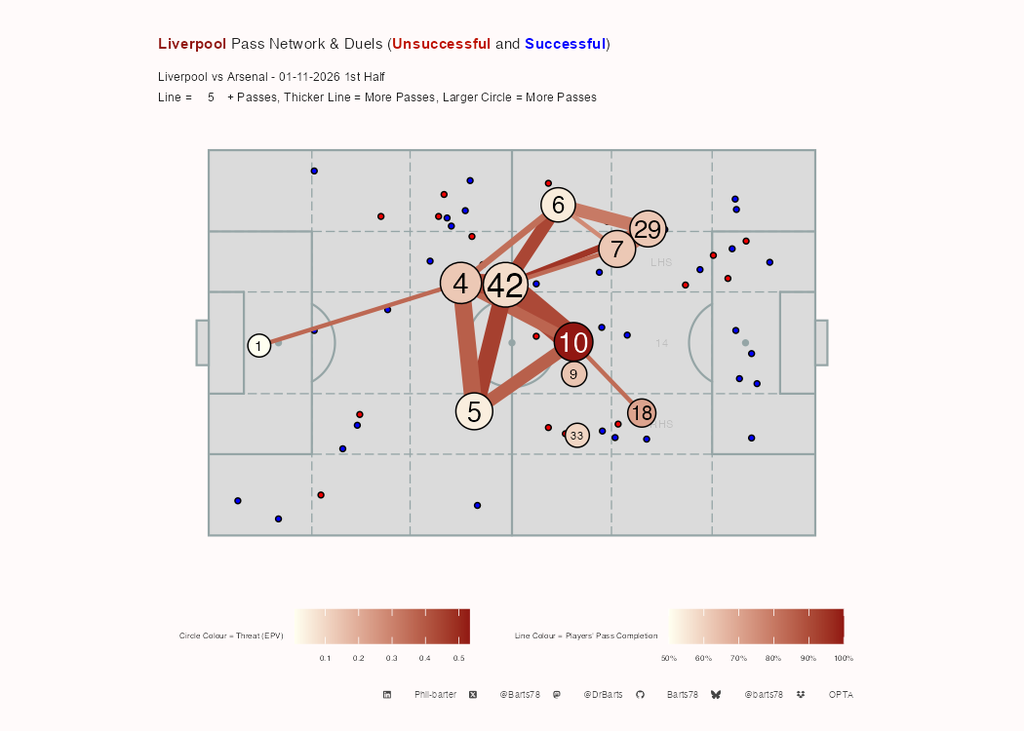

Away Pass Maps

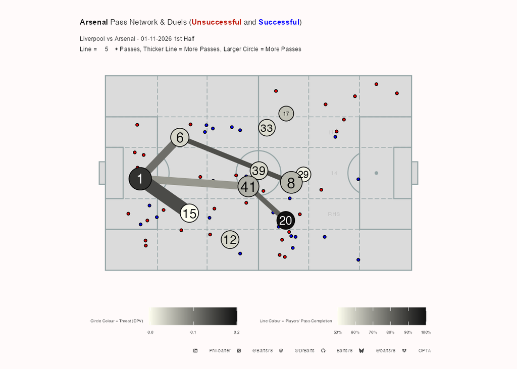

Home Pass Maps by Time

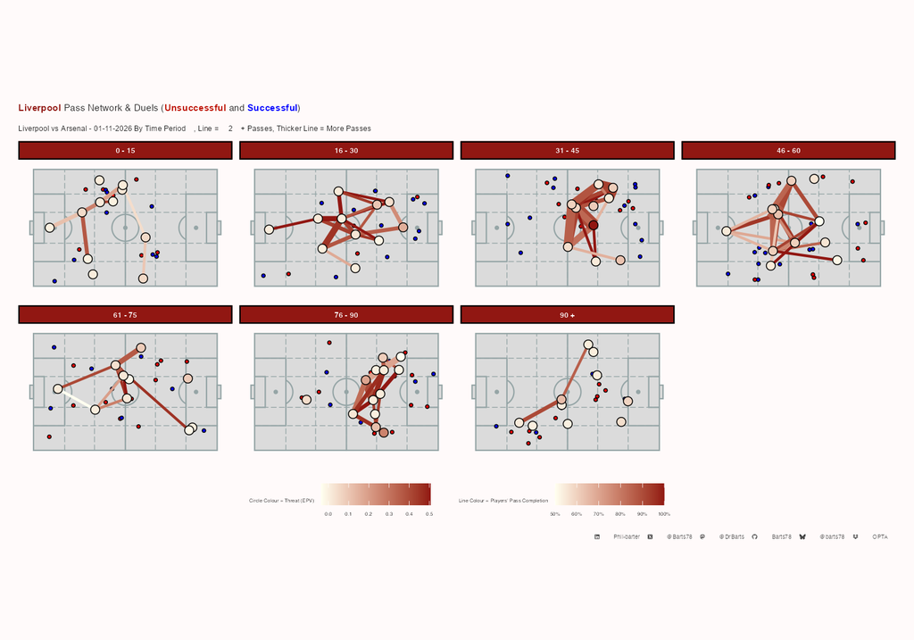

Away Pass Maps by Time

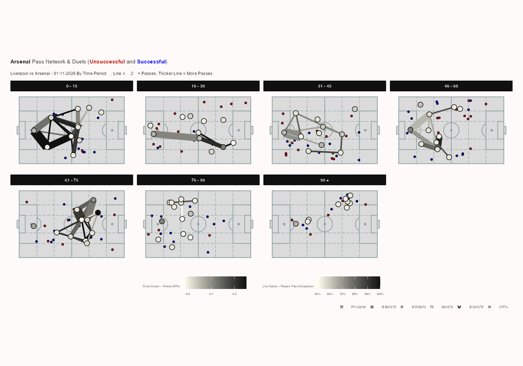

Home Attacking Pass Maps

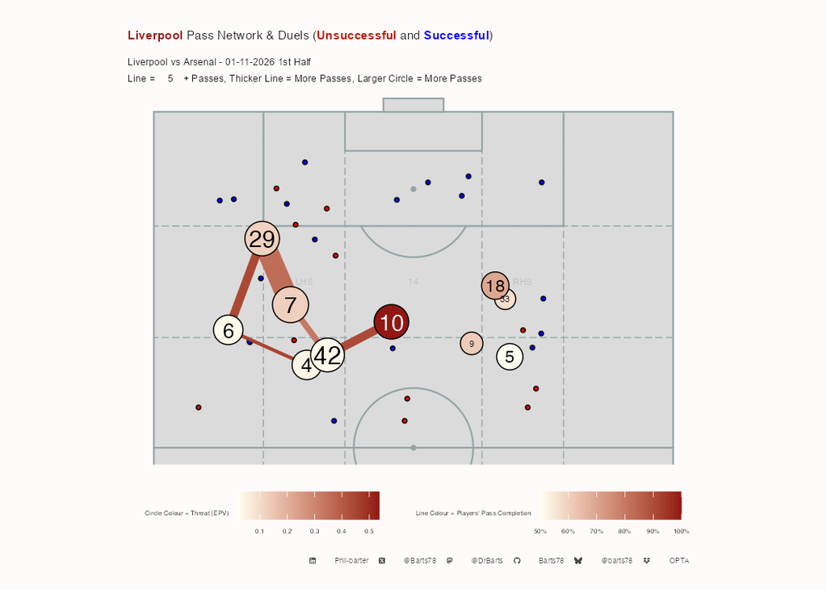

Away Attacking Pass Maps

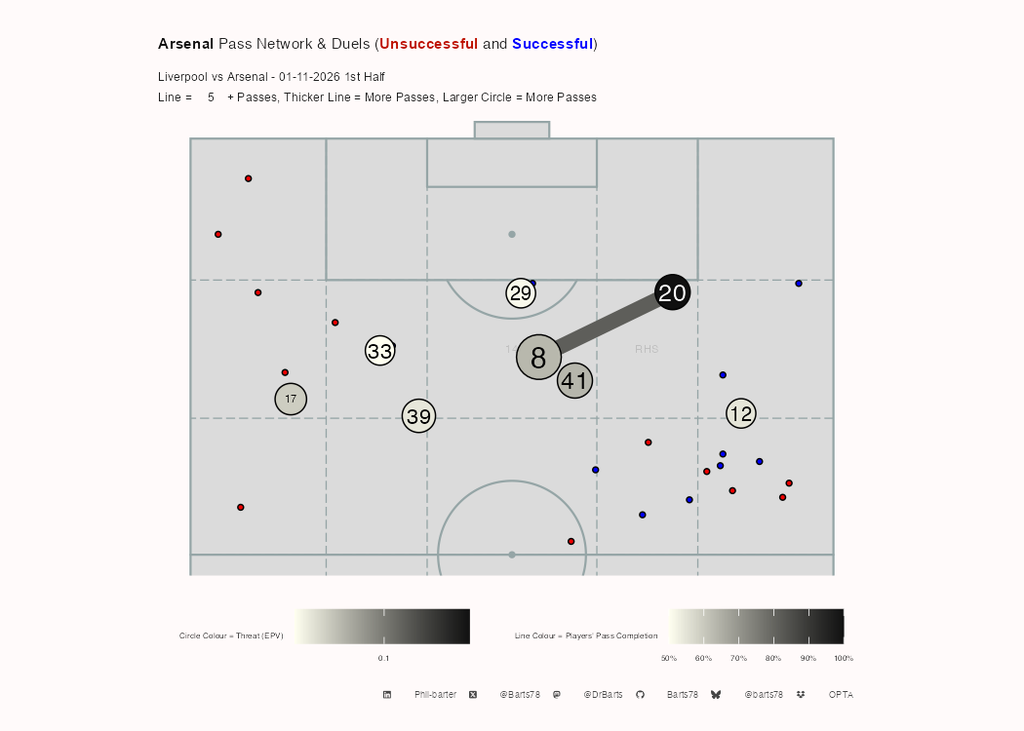

Home Attacking Pass Maps by Time

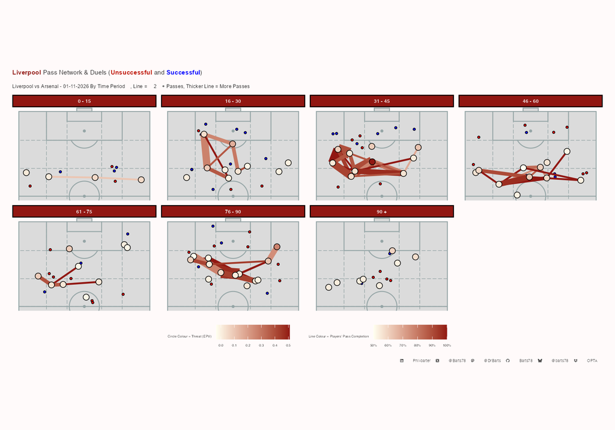

Away Attacking Pass Maps by Time

[figure not shown]

**Pass Connections by Passer**

Liverpool Open Play Passing connections

Liverpool vs Arsenal - 01-11-2026 | Completed passes only, min 5 per pair. Passer Completion % = all of the passer's attempts

|  | Completed Passes | % of Passer's Completions | % of Receiver's Receptions | Passer Completion % | Long Passes | Final Third Passes | PK Box Passes | Crosses | Key Passes | Prog Passes | EPV | EPV / Pass | Pass Time |
| --- | --- | --- | --- | --- | --- | --- | --- | --- | --- | --- | --- | --- | --- |
| Alexis Mac Allister |  |  |  |  |  |  |  |  |  |  |  |  |  |
| Dominik Szoboszlai | 6 | 11% | 24% | 87% | 0 | 3 | 1 | 0 | 0 | 0 | 0.039 | 0.006 | 2.83 |
| Jérémy Jacquet | 10 | 19% | 26% | 87% | 0 | 4 | 0 | 0 | 0 | 0 | 0.019 | 0.002 | 2.10 |
| Trey Nyoni | 8 | 15% | 20% | 87% | 0 | 3 | 0 | 0 | 0 | 0 | 0.019 | 0.002 | 1.88 |
| Virgil van Dijk | 9 | 17% | 18% | 87% | 0 | 5 | 0 | 0 | 0 | 2 | 0.043 | 0.005 | 1.89 |
| Alisson Becker |  |  |  |  |  |  |  |  |  |  |  |  |  |
| Jérémy Jacquet | 5 | 33% | 13% | 68% | 0 | 0 | 0 | 0 | 0 | 0 | 0.006 | 0.001 | 2.60 |
| Virgil van Dijk | 5 | 33% | 10% | 68% | 1 | 0 | 0 | 0 | 0 | 0 | 0.015 | 0.003 | 2.40 |
| Bradley Barcola |  |  |  |  |  |  |  |  |  |  |  |  |  |
| Florian Wirtz | 9 | 41% | 29% | 71% | 0 | 8 | 1 | 0 | 0 | 3 | 0.149 | 0.017 | 1.44 |
| Florian Wirtz |  |  |  |  |  |  |  |  |  |  |  |  |  |
| Alexis Mac Allister | 6 | 21% | 15% | 83% | 0 | 3 | 0 | 0 | 0 | 2 | 0.025 | 0.004 | 3.33 |
| Bradley Barcola | 5 | 17% | 15% | 83% | 0 | 5 | 1 | 0 | 0 | 1 | 0.070 | 0.014 | 2.20 |
| Milos Kerkez | 5 | 17% | 15% | 83% | 0 | 1 | 1 | 0 | 0 | 0 | 0.025 | 0.005 | 2.00 |
| Jérémy Jacquet |  |  |  |  |  |  |  |  |  |  |  |  |  |
| Alexis Mac Allister | 6 | 14% | 15% | 81% | 0 | 0 | 0 | 0 | 0 | 1 | 0.015 | 0.002 | 2.50 |
| Trey Nyoni | 7 | 17% | 18% | 81% | 0 | 1 | 0 | 0 | 0 | 0 | 0.015 | 0.002 | 4.86 |
| Virgil van Dijk | 12 | 29% | 24% | 81% | 0 | 0 | 0 | 0 | 0 | 0 | 0.012 | 0.001 | 2.33 |
| Milos Kerkez |  |  |  |  |  |  |  |  |  |  |  |  |  |
| Bradley Barcola | 6 | 25% | 18% | 80% | 0 | 4 | 0 | 0 | 0 | 0 | 0.037 | 0.006 | 3.17 |
| Virgil van Dijk | 5 | 21% | 10% | 80% | 0 | 1 | 0 | 0 | 0 | 0 | 0.011 | 0.002 | 3.40 |
| Trey Nyoni |  |  |  |  |  |  |  |  |  |  |  |  |  |
| Alexis Mac Allister | 9 | 17% | 23% | 96% | 0 | 1 | 0 | 0 | 0 | 4 | 0.034 | 0.004 | 2.22 |
| Bradley Barcola | 5 | 9% | 15% | 96% | 1 | 1 | 0 | 0 | 0 | 0 | 0.022 | 0.004 | 4.60 |
| Jérémy Jacquet | 7 | 13% | 18% | 96% | 0 | 0 | 0 | 0 | 0 | 0 | 0.006 | 0.001 | 3.00 |
| Milos Kerkez | 11 | 20% | 33% | 96% | 0 | 2 | 0 | 0 | 0 | 0 | 0.036 | 0.003 | 3.55 |
| Virgil van Dijk | 10 | 18% | 20% | 96% | 0 | 0 | 0 | 0 | 0 | 0 | 0.011 | 0.001 | 2.80 |
| Virgil van Dijk |  |  |  |  |  |  |  |  |  |  |  |  |  |
| Alexis Mac Allister | 5 | 9% | 13% | 82% | 0 | 0 | 0 | 0 | 0 | 2 | 0.021 | 0.004 | 3.80 |
| Dominik Szoboszlai | 5 | 9% | 20% | 82% | 0 | 0 | 0 | 0 | 0 | 1 | 0.010 | 0.002 | 3.80 |
| Florian Wirtz | 5 | 9% | 16% | 82% | 0 | 0 | 0 | 0 | 0 | 3 | 0.020 | 0.004 | 3.00 |
| Jérémy Jacquet | 6 | 11% | 16% | 82% | 0 | 0 | 0 | 0 | 0 | 0 | 0.004 | 0.001 | 3.83 |
| Milos Kerkez | 7 | 13% | 21% | 82% | 0 | 2 | 0 | 0 | 0 | 0 | 0.028 | 0.004 | 3.29 |
| Trey Nyoni | 13 | 24% | 33% | 82% | 0 | 1 | 0 | 0 | 0 | 0 | 0.012 | 0.001 | 3.23 |

X @Barts78 · Bluesky @barts78 · Mastodon @DrBarts · GitHub Barts78 · LinkedIn Phil-barter · Data: Opta

**Pass Connections by Receiver**

Liverpool Open Play Passing connections

Liverpool vs Arsenal - 01-11-2026 | Completed passes only, min 5 per pair. Passer Completion % = all of the passer's attempts

|  | Completed Passes | % of Passer's Completions | % of Receiver's Receptions | Passer Completion % | Long Passes | Final Third Passes | PK Box Passes | Crosses | Key Passes | Prog Passes | EPV | EPV / Pass | Pass Time |
| --- | --- | --- | --- | --- | --- | --- | --- | --- | --- | --- | --- | --- | --- |
| Dominik Szoboszlai |  |  |  |  |  |  |  |  |  |  |  |  |  |
| Alexis Mac Allister | 6 | 11% | 24% | 87% | 0 | 3 | 1 | 0 | 0 | 0 | 0.039 | 0.006 | 2.83 |
| Virgil van Dijk | 5 | 9% | 20% | 82% | 0 | 0 | 0 | 0 | 0 | 1 | 0.010 | 0.002 | 3.80 |
| Jérémy Jacquet |  |  |  |  |  |  |  |  |  |  |  |  |  |
| Alexis Mac Allister | 10 | 19% | 26% | 87% | 0 | 4 | 0 | 0 | 0 | 0 | 0.019 | 0.002 | 2.10 |
| Alisson Becker | 5 | 33% | 13% | 68% | 0 | 0 | 0 | 0 | 0 | 0 | 0.006 | 0.001 | 2.60 |
| Trey Nyoni | 7 | 13% | 18% | 96% | 0 | 0 | 0 | 0 | 0 | 0 | 0.006 | 0.001 | 3.00 |
| Virgil van Dijk | 6 | 11% | 16% | 82% | 0 | 0 | 0 | 0 | 0 | 0 | 0.004 | 0.001 | 3.83 |
| Trey Nyoni |  |  |  |  |  |  |  |  |  |  |  |  |  |
| Alexis Mac Allister | 8 | 15% | 20% | 87% | 0 | 3 | 0 | 0 | 0 | 0 | 0.019 | 0.002 | 1.88 |
| Jérémy Jacquet | 7 | 17% | 18% | 81% | 0 | 1 | 0 | 0 | 0 | 0 | 0.015 | 0.002 | 4.86 |
| Virgil van Dijk | 13 | 24% | 33% | 82% | 0 | 1 | 0 | 0 | 0 | 0 | 0.012 | 0.001 | 3.23 |
| Virgil van Dijk |  |  |  |  |  |  |  |  |  |  |  |  |  |
| Alexis Mac Allister | 9 | 17% | 18% | 87% | 0 | 5 | 0 | 0 | 0 | 2 | 0.043 | 0.005 | 1.89 |
| Alisson Becker | 5 | 33% | 10% | 68% | 1 | 0 | 0 | 0 | 0 | 0 | 0.015 | 0.003 | 2.40 |
| Jérémy Jacquet | 12 | 29% | 24% | 81% | 0 | 0 | 0 | 0 | 0 | 0 | 0.012 | 0.001 | 2.33 |
| Milos Kerkez | 5 | 21% | 10% | 80% | 0 | 1 | 0 | 0 | 0 | 0 | 0.011 | 0.002 | 3.40 |
| Trey Nyoni | 10 | 18% | 20% | 96% | 0 | 0 | 0 | 0 | 0 | 0 | 0.011 | 0.001 | 2.80 |
| Florian Wirtz |  |  |  |  |  |  |  |  |  |  |  |  |  |
| Bradley Barcola | 9 | 41% | 29% | 71% | 0 | 8 | 1 | 0 | 0 | 3 | 0.149 | 0.017 | 1.44 |
| Virgil van Dijk | 5 | 9% | 16% | 82% | 0 | 0 | 0 | 0 | 0 | 3 | 0.020 | 0.004 | 3.00 |
| Alexis Mac Allister |  |  |  |  |  |  |  |  |  |  |  |  |  |
| Florian Wirtz | 6 | 21% | 15% | 83% | 0 | 3 | 0 | 0 | 0 | 2 | 0.025 | 0.004 | 3.33 |
| Jérémy Jacquet | 6 | 14% | 15% | 81% | 0 | 0 | 0 | 0 | 0 | 1 | 0.015 | 0.002 | 2.50 |
| Trey Nyoni | 9 | 17% | 23% | 96% | 0 | 1 | 0 | 0 | 0 | 4 | 0.034 | 0.004 | 2.22 |
| Virgil van Dijk | 5 | 9% | 13% | 82% | 0 | 0 | 0 | 0 | 0 | 2 | 0.021 | 0.004 | 3.80 |
| Bradley Barcola |  |  |  |  |  |  |  |  |  |  |  |  |  |
| Florian Wirtz | 5 | 17% | 15% | 83% | 0 | 5 | 1 | 0 | 0 | 1 | 0.070 | 0.014 | 2.20 |
| Milos Kerkez | 6 | 25% | 18% | 80% | 0 | 4 | 0 | 0 | 0 | 0 | 0.037 | 0.006 | 3.17 |
| Trey Nyoni | 5 | 9% | 15% | 96% | 1 | 1 | 0 | 0 | 0 | 0 | 0.022 | 0.004 | 4.60 |
| Milos Kerkez |  |  |  |  |  |  |  |  |  |  |  |  |  |
| Florian Wirtz | 5 | 17% | 15% | 83% | 0 | 1 | 1 | 0 | 0 | 0 | 0.025 | 0.005 | 2.00 |
| Trey Nyoni | 11 | 20% | 33% | 96% | 0 | 2 | 0 | 0 | 0 | 0 | 0.036 | 0.003 | 3.55 |
| Virgil van Dijk | 7 | 13% | 21% | 82% | 0 | 2 | 0 | 0 | 0 | 0 | 0.028 | 0.004 | 3.29 |

X @Barts78 · Bluesky @barts78 · Mastodon @DrBarts · GitHub Barts78 · LinkedIn Phil-barter · Data: Opta

**Away Pass Connections by Passer**

Arsenal Open Play Passing connections

Liverpool vs Arsenal - 01-11-2026 | Completed passes only, min 5 per pair. Passer Completion % = all of the passer's attempts

|  | Completed Passes | % of Passer's Completions | % of Receiver's Receptions | Passer Completion % | Long Passes | Final Third Passes | PK Box Passes | Crosses | Key Passes | Prog Passes | EPV | EPV / Pass | Pass Time |
| --- | --- | --- | --- | --- | --- | --- | --- | --- | --- | --- | --- | --- | --- |
| David Raya |  |  |  |  |  |  |  |  |  |  |  |  |  |
| Gabriel Magalhães | 5 | 18% | 20% | 53% | 0 | 0 | 0 | 0 | 0 | 0 | 0.003 | 0.001 | 4.00 |
| Declan Rice |  |  |  |  |  |  |  |  |  |  |  |  |  |
| Ezri Konsa | 6 | 16% | 40% | 86% | 0 | 0 | 0 | 0 | 0 | 0 | 0.011 | 0.002 | 2.83 |
| Jurriën Timber | 5 | 13% | 20% | 86% | 0 | 0 | 0 | 0 | 1 | 1 | 0.015 | 0.003 | 2.00 |
| Noni Madueke | 8 | 21% | 31% | 86% | 0 | 4 | 0 | 0 | 0 | 1 | 0.039 | 0.005 | 3.62 |
| Ezri Konsa |  |  |  |  |  |  |  |  |  |  |  |  |  |
| David Raya | 13 | 54% | 52% | 86% | 0 | 0 | 0 | 0 | 0 | 0 | 0.017 | 0.001 | 3.15 |
| Gabriel Magalhães |  |  |  |  |  |  |  |  |  |  |  |  |  |
| Christos Tzolis | 5 | 16% | 17% | 82% | 0 | 0 | 0 | 0 | 0 | 0 | 0.011 | 0.002 | 2.60 |
| David Raya | 7 | 22% | 28% | 82% | 1 | 0 | 0 | 0 | 0 | 0 | 0.013 | 0.002 | 4.86 |
| Martin Ødegaard | 5 | 16% | 22% | 82% | 0 | 0 | 0 | 0 | 0 | 0 | 0.007 | 0.001 | 3.80 |
| Martin Ødegaard |  |  |  |  |  |  |  |  |  |  |  |  |  |
| Christos Tzolis | 8 | 24% | 28% | 79% | 1 | 3 | 0 | 0 | 0 | 1 | 0.042 | 0.005 | 4.25 |
| Declan Rice | 6 | 18% | 18% | 79% | 0 | 4 | 2 | 0 | 1 | 0 | 0.043 | 0.007 | 3.33 |
| Riccardo Calafiori | 5 | 15% | 29% | 79% | 1 | 1 | 0 | 0 | 0 | 1 | 0.041 | 0.008 | 3.20 |

X @Barts78 · Bluesky @barts78 · Mastodon @DrBarts · GitHub Barts78 · LinkedIn Phil-barter · Data: Opta

**Away Pass Connections by Receiver**

Arsenal Open Play Passing connections

Liverpool vs Arsenal - 01-11-2026 | Completed passes only, min 5 per pair. Passer Completion % = all of the passer's attempts

|  | Completed Passes | % of Passer's Completions | % of Receiver's Receptions | Passer Completion % | Long Passes | Final Third Passes | PK Box Passes | Crosses | Key Passes | Prog Passes | EPV | EPV / Pass | Pass Time |
| --- | --- | --- | --- | --- | --- | --- | --- | --- | --- | --- | --- | --- | --- |
| Gabriel Magalhães |  |  |  |  |  |  |  |  |  |  |  |  |  |
| David Raya | 5 | 18% | 20% | 53% | 0 | 0 | 0 | 0 | 0 | 0 | 0.003 | 0.001 | 4.00 |
| Ezri Konsa |  |  |  |  |  |  |  |  |  |  |  |  |  |
| Declan Rice | 6 | 16% | 40% | 86% | 0 | 0 | 0 | 0 | 0 | 0 | 0.011 | 0.002 | 2.83 |
| Jurriën Timber |  |  |  |  |  |  |  |  |  |  |  |  |  |
| Declan Rice | 5 | 13% | 20% | 86% | 0 | 0 | 0 | 0 | 1 | 1 | 0.015 | 0.003 | 2.00 |
| Noni Madueke |  |  |  |  |  |  |  |  |  |  |  |  |  |
| Declan Rice | 8 | 21% | 31% | 86% | 0 | 4 | 0 | 0 | 0 | 1 | 0.039 | 0.005 | 3.62 |
| David Raya |  |  |  |  |  |  |  |  |  |  |  |  |  |
| Ezri Konsa | 13 | 54% | 52% | 86% | 0 | 0 | 0 | 0 | 0 | 0 | 0.017 | 0.001 | 3.15 |
| Gabriel Magalhães | 7 | 22% | 28% | 82% | 1 | 0 | 0 | 0 | 0 | 0 | 0.013 | 0.002 | 4.86 |
| Christos Tzolis |  |  |  |  |  |  |  |  |  |  |  |  |  |
| Gabriel Magalhães | 5 | 16% | 17% | 82% | 0 | 0 | 0 | 0 | 0 | 0 | 0.011 | 0.002 | 2.60 |
| Martin Ødegaard | 8 | 24% | 28% | 79% | 1 | 3 | 0 | 0 | 0 | 1 | 0.042 | 0.005 | 4.25 |
| Martin Ødegaard |  |  |  |  |  |  |  |  |  |  |  |  |  |
| Gabriel Magalhães | 5 | 16% | 22% | 82% | 0 | 0 | 0 | 0 | 0 | 0 | 0.007 | 0.001 | 3.80 |
| Declan Rice |  |  |  |  |  |  |  |  |  |  |  |  |  |
| Martin Ødegaard | 6 | 18% | 18% | 79% | 0 | 4 | 2 | 0 | 1 | 0 | 0.043 | 0.007 | 3.33 |
| Riccardo Calafiori |  |  |  |  |  |  |  |  |  |  |  |  |  |
| Martin Ødegaard | 5 | 15% | 29% | 79% | 1 | 1 | 0 | 0 | 0 | 1 | 0.041 | 0.008 | 3.20 |

X @Barts78 · Bluesky @barts78 · Mastodon @DrBarts · GitHub Barts78 · LinkedIn Phil-barter · Data: Opta

Home Passing Tree Plot

[figure not shown]

Away Passing Tree Plot

[figure not shown]

Home wave plot

[figure not shown]

Away wave plot

[figure not shown]

**Home 1st Half Pass receiving Areas**

[figure not shown]

**Home 2nd Half Pass receiving Areas**

[figure not shown]

**Home Up to 1st Sub Pass receiving Areas**

[figure not shown]

**Away 1st Half Pass receiving Areas**

[figure not shown]

**Away 2nd Half Pass receiving Areas**

[figure not shown]

**Away Up to 1st Sub Pass receiving Areas**

[figure not shown]

Home Passing chains

[figure not shown]

Away Passing Chains

[figure not shown]

**Full time**

Liverpool FT Passing Chain Length (5, 6-10, 11-15, 16 +) & Distance (m)

Liverpool vs Arsenal - 01-11-2026

|  | Pass Chain Length | Total Chain Passes | Max Chain Length | Average Chain Length | Percent of Teams Passes | Total Chain Distance | Max Chain Distance | Average Chain Distance | Percent of Teams Passing Distance |
| --- | --- | --- | --- | --- | --- | --- | --- | --- | --- |
|  | VLow | 233 | 5 | 3 | 57% | 3,439.25 | 100.28 | 14.80 | 57% |
|  | Low | 65 | 8 | 7 | 16% | 946.41 | 161.22 | 14.60 | 16% |
|  | Medium | 36 | 12 | 12 | 9% | 487.75 | 181.47 | 13.50 | 8% |
|  | High | 76 | 22 | 19 | 19% | 1,136.19 | 344.00 | 14.90 | 19% |
| Overall Totals | — | 410 | 47 | 41 | — | 6,010 | 787 | 58 | — |
| Overall Average | — | 102 | 12 | 10 | — | 1,502 | 197 | 14 | — |

X @Barts78 · Bluesky @barts78 · Mastodon @DrBarts · GitHub Barts78 · LinkedIn Phil-barter · Data: Opta

**1st Half**

Liverpool 1st Half Passing Chain Length (5, 6-10, 11-15, 16 +) & Distance (m)

Liverpool vs Arsenal - 01-11-2026

|  | Pass Chain Length | Total Chain Passes | Max Chain Length | Average Chain Length | Percent of Teams Passes | Total Chain Distance | Max Chain Distance | Average Chain Distance | Percent of Teams Passing Distance |
| --- | --- | --- | --- | --- | --- | --- | --- | --- | --- |
|  | VLow | 98 | 5 | 2 | 51% | 1,430.61 | 100.28 | 14.60 | 52% |
|  | Low | 31 | 8 | 8 | 16% | 441.15 | 149.68 | 14.20 | 16% |
|  | Medium | 24 | 12 | 12 | 12% | 306.28 | 157.82 | 12.80 | 11% |
|  | High | 39 | 22 | 20 | 20% | 576.79 | 344.00 | 14.80 | 21% |
| Overall Totals | — | 192 | 47 | 42 | — | 2,755 | 752 | 56 | — |
| Overall Average | — | 48 | 12 | 10 | — | 689 | 188 | 14 | — |

X @Barts78 · Bluesky @barts78 · Mastodon @DrBarts · GitHub Barts78 · LinkedIn Phil-barter · Data: Opta

**2nd Half**

Liverpool 2nd Half Passing Chain Length (5, 6-10, 11-15, 16 +) & Distance (m)

Liverpool vs Arsenal - 01-11-2026

|  | Pass Chain Length | Total Chain Passes | Max Chain Length | Average Chain Length | Percent of Teams Passes | Total Chain Distance | Max Chain Distance | Average Chain Distance | Percent of Teams Passing Distance |
| --- | --- | --- | --- | --- | --- | --- | --- | --- | --- |
|  | VLow | 135 | 5 | 3 | 62% | 2,008.64 | 99.16 | 14.90 | 62% |
|  | Low | 34 | 7 | 6 | 16% | 505.26 | 161.22 | 14.90 | 16% |
|  | Medium | 12 | 12 | 12 | 6% | 181.47 | 181.47 | 15.10 | 6% |
|  | High | 37 | 21 | 19 | 17% | 559.40 | 298.52 | 15.10 | 17% |
| Overall Totals | — | 218 | 45 | 40 | — | 3,255 | 740 | 60 | — |
| Overall Average | — | 54 | 11 | 10 | — | 814 | 185 | 15 | — |

X @Barts78 · Bluesky @barts78 · Mastodon @DrBarts · GitHub Barts78 · LinkedIn Phil-barter · Data: Opta

**Away Full time**

Arsenal FT Passing Chain Length (5, 6-10, 11-15, 16 +) & Distance (m)

Liverpool vs Arsenal - 01-11-2026

|  | Pass Chain Length | Total Chain Passes | Max Chain Length | Average Chain Length | Percent of Teams Passes | Total Chain Distance | Max Chain Distance | Average Chain Distance | Percent of Teams Passing Distance |
| --- | --- | --- | --- | --- | --- | --- | --- | --- | --- |
|  | VLow | 211 | 5 | 3 | 72% | 3,098.39 | 139.97 | 14.70 | 74% |
|  | Low | 49 | 10 | 7 | 17% | 585.85 | 114.89 | 12.00 | 14% |
|  | Medium | 35 | 13 | 12 | 12% | 528.31 | 202.41 | 15.10 | 13% |
| Overall Totals | — | 295 | 28 | 22 | — | 4,213 | 457 | 42 | — |
| Overall Average | — | 98 | 9 | 7 | — | 1,404 | 152 | 14 | — |

X @Barts78 · Bluesky @barts78 · Mastodon @DrBarts · GitHub Barts78 · LinkedIn Phil-barter · Data: Opta

**Away 1st Half**

Arsenal 1st Half Passing Chain Length (5, 6-10, 11-15, 16 +) & Distance (m)

Liverpool vs Arsenal - 01-11-2026

|  | Pass Chain Length | Total Chain Passes | Max Chain Length | Average Chain Length | Percent of Teams Passes | Total Chain Distance | Max Chain Distance | Average Chain Distance | Percent of Teams Passing Distance |
| --- | --- | --- | --- | --- | --- | --- | --- | --- | --- |
|  | VLow | 121 | 5 | 3 | 79% | 1,727.99 | 139.97 | 14.30 | 81% |
|  | Low | 20 | 7 | 6 | 13% | 245.94 | 103.57 | 12.30 | 12% |
|  | Medium | 13 | 13 | 13 | 8% | 160.72 | 160.72 | 12.40 | 8% |
| Overall Totals | — | 154 | 25 | 22 | — | 2,135 | 404 | 39 | — |
| Overall Average | — | 51 | 8 | 7 | — | 712 | 135 | 13 | — |

X @Barts78 · Bluesky @barts78 · Mastodon @DrBarts · GitHub Barts78 · LinkedIn Phil-barter · Data: Opta

**Away 2nd Half**

Arsenal 2nd Half Passing Chain Length (5, 6-10, 11-15, 16 +) & Distance (m)

Liverpool vs Arsenal - 01-11-2026

|  | Pass Chain Length | Total Chain Passes | Max Chain Length | Average Chain Length | Percent of Teams Passes | Total Chain Distance | Max Chain Distance | Average Chain Distance | Percent of Teams Passing Distance |
| --- | --- | --- | --- | --- | --- | --- | --- | --- | --- |
|  | VLow | 90 | 5 | 2 | 64% | 1,370.40 | 89.39 | 15.20 | 66% |
|  | Low | 29 | 10 | 8 | 21% | 339.91 | 114.89 | 11.70 | 16% |
|  | Medium | 22 | 11 | 11 | 16% | 367.59 | 202.41 | 16.70 | 18% |
| Overall Totals | — | 141 | 26 | 21 | — | 2,078 | 407 | 44 | — |
| Overall Average | — | 47 | 9 | 7 | — | 693 | 136 | 15 | — |

X @Barts78 · Bluesky @barts78 · Mastodon @DrBarts · GitHub Barts78 · LinkedIn Phil-barter · Data: Opta

**Home Z14 RS By Half**

[figure not shown]

**Home Z14 RS By Game Period**

[figure not shown]

**Away Z14 RS By Half**

[figure not shown]

**Away Z14 RS By Game Period**

[figure not shown]

**Home Long Passes By half**

[figure not shown]

**Home Long Passes By Game Period**

[figure not shown]

**Away Long Passes By Half**

[figure not shown]

**Away Long Passes By Game period**

[figure not shown]

Set-Piece Summary

**Set Pieces**

Liverpool vs Arsenal - 01-11-2026

|  | Liverpool | Arsenal |
| --- | --- | --- |
| Corners |  |  |
| Corners taken | 7 | 4 |
| Short | 1 | 2 |
| Direct | 6 | 2 |
| Direct - first contact won | 1 (17%) | 1 (50%) |
| Free kicks |  |  |
| Free kicks (passes) | 12 | 20 |
| Into final third / box | 2 | 11 |
| Into box | 1 | 1 |
| Throw-ins |  |  |
| Throw-ins | 25 | 18 |
| Retained (first touch) | 80% | 89% |
| Shots by situation |  |  |
| Open-play shots | 13 | 9 |
| Open-play xG | 0.93 | 0.95 |
| Open-play goals | 0 | 1 |
| Set-piece shots | 4 | 1 |
| Set-piece xG | 0.12 | 0.04 |
| Set-piece goals | 0 | 0 |
| Penalties | 0 | 0 |
| Penalty xG | 0.00 | 0.00 |
| Set-piece share of xG | 11% | 4% |

First contact: the team that touches the ball first after the delivery (aerial duels go to the winner). Throw-ins retained = first touch by the taking team.  
X @Barts78 · Bluesky @barts78 · Mastodon @DrBarts · GitHub Barts78 · LinkedIn Phil-barter · Data: Opta

**Corners**

[figure not shown]

**Free Kicks**

[figure not shown]

**Corners**

[figure not shown]

**Free Kicks**

[figure not shown]

**Sequence Map**

[figure not shown]

**Sequence Table**

**Liverpool - Shot-Creating Sequences**

Liverpool vs Arsenal - 01-11-2026

| Min | Shooter | Result | xG | Situation | Started by | Started from | Start zone | Passes | Duration (s) |
| --- | --- | --- | --- | --- | --- | --- | --- | --- | --- |
| 27' | Gakpo | Blocked | 0.04 | Set piece | Wirtz | Free kick | Att third, Right half-space | 4 | 13 |
| 27' | van Dijk | Off target | 0.03 | Set piece | Gakpo | Corner | Att third, Right wing | 1 | 3 |
| 28' | Araujo | Blocked | 0.01 | Set piece | Gakpo | Corner | Att third, Left wing | 5 | 15 |
| 31' | Kerkez | Off target | 0.12 | Open play | Kerkez | Open-play regain | Att third, Central | 0 | 0 |
| 33' | Mac Allister | Off target | 0.02 | Open play | Mac Allister | Open-play regain | Def third, Central | 3 | 18 |
| 36' | Isak | Off target | 0.05 | Open play | Nyoni | Open-play regain | Att third, Left half-space | 3 | 11 |
| 39' | Wirtz | Post | 0.04 | Set piece | Gakpo | Corner | Att third, Right wing | 3 | 89 |
| 43' | Mac Allister | Off target | 0.10 | Open play | Jacquet | Open-play regain | Mid third, Central | 3 | 10 |
| 54' | Wirtz | Blocked | 0.06 | Open play | Nyoni | Open-play regain | Att third, Central | 1 | 2 |
| 56' | Isak | Off target | 0.03 | Open play | Nyoni | Free kick | Def third, Left half-space | 4 | 15 |
| 66' | Wirtz | Blocked | 0.18 | Open play | Wirtz | Open-play regain | Att third, Central | 0 | 0 |
| 75' | van Dijk | Blocked | 0.02 | Open play | van Dijk | Goal kick | Def third, Central | 21 | 56 |
| 77' | Araujo | Blocked | 0.18 | Open play | Mac Allister | Open-play regain | Mid third, Central | 13 | 47 |
| 87' | Ngumoha | Blocked | 0.03 | Open play | Ngumoha | Throw-in | Att third, Right wing | 7 | 28 |
| 90+1' | Muñoz | Blocked | 0.02 | Open play | Mac Allister | Open-play regain | Mid third, Right half-space | 7 | 16 |
| 90+1' | Ngumoha | Blocked | 0.05 | Open play | Mac Allister | Open-play regain | Mid third, Right half-space | 7 | 19 |
| 90+2' | Barcola | Off target | 0.07 | Open play | Koumas | Open-play regain | Mid third, Left wing | 5 | 19 |

X @Barts78 · Bluesky @barts78 · Mastodon @DrBarts · GitHub Barts78 · LinkedIn Phil-barter · Data: Opta

**Sequence Map**

[figure not shown]

**Sequence Table**

**Arsenal - Shot-Creating Sequences**

Liverpool vs Arsenal - 01-11-2026

| Min | Shooter | Result | xG | Situation | Started by | Started from | Start zone | Passes | Duration (s) |
| --- | --- | --- | --- | --- | --- | --- | --- | --- | --- |
| 15' | Rice | Off target | 0.02 | Open play | Calafiori | Throw-in | Att third, Left wing | 8 | 24 |
| 16' | Havertz | Goal | 0.64 | Open play | Ødegaard | Open-play regain | Att third, Left half-space | 4 | 11 |
| 24' | Guimarães | Off target | 0.05 | Open play | Madueke | Open-play regain | Def third, Right half-space | 7 | 24 |
| 25' | Rice | Saved | 0.06 | Open play | Ødegaard | Open-play regain | Att third, Right half-space | 1 | 1 |
| 45+1' | Rice | Blocked | 0.05 | Open play | Madueke | Open-play regain | Def third, Right half-space | 14 | 47 |
| 55' | Guimarães | Off target | 0.05 | Open play | Timber | Open-play regain | Mid third, Central | 6 | 34 |
| 65' | Madueke | Blocked | 0.03 | Open play | Timber | Throw-in | Att third, Right wing | 3 | 9 |
| 71' | Timber | Blocked | 0.02 | Open play | Lewis-Skelly | Open-play regain | Att third, Right half-space | 1 | 4 |
| 73' | Tzolis | Saved | 0.03 | Open play | Konsa | Free kick | Def third, Right half-space | 11 | 32 |
| 74' | Lewis-Skelly | Off target | 0.04 | Set piece | Ødegaard | Corner | Att third, Right wing | 1 | 2 |

X @Barts78 · Bluesky @barts78 · Mastodon @DrBarts · GitHub Barts78 · LinkedIn Phil-barter · Data: Opta

Entries by Channel

**Box and Final-Third Entries (open play)**

Liverpool vs Arsenal - 01-11-2026

|  | Box entries Passes | Box entries Carries | Box entries Total | Box entries Success % | Final-third entries Passes | Final-third entries Carries | Final-third entries Total | Final-third entries Success % |
| --- | --- | --- | --- | --- | --- | --- | --- | --- |
| Liverpool |  |  |  |  |  |  |  |  |
| Left wing | 19 | 2 | 21 | 38% | 18 | 5 | 23 | 57% |
| Left half-space | 3 | 1 | 4 | 100% | 16 | 6 | 22 | 77% |
| Central | 12 | 1 | 13 | 54% | 19 | 2 | 21 | 86% |
| Right half-space | 5 | 0 | 5 | 80% | 12 | 1 | 13 | 69% |
| Right wing | 10 | 2 | 12 | 25% | 7 | 1 | 8 | 38% |
| Total | 49 | 6 | 55 | 47% | 72 | 15 | 87 | 69% |
| Arsenal |  |  |  |  |  |  |  |  |
| Left wing | 4 | 4 | 8 | 38% | 8 | 5 | 13 | 62% |
| Left half-space | 2 | 0 | 2 | 50% | 5 | 1 | 6 | 67% |
| Central | 1 | 1 | 2 | 0% | 10 | 0 | 10 | 30% |
| Right half-space | 5 | 1 | 6 | 67% | 5 | 1 | 6 | 67% |
| Right wing | 1 | 1 | 2 | 100% | 4 | 3 | 7 | 71% |
| Total | 13 | 7 | 20 | 50% | 32 | 10 | 42 | 57% |

Channel = where the pass or carry started. Left/right from the attacking team's view. Set pieces excluded.  
X @Barts78 · Bluesky @barts78 · Mastodon @DrBarts · GitHub Barts78 · LinkedIn Phil-barter · Data: Opta

**Box**

[figure not shown]

**Final Third**

[figure not shown]

**Box**

[figure not shown]

**Final Third**

[figure not shown]

**Match Stats**

**Passing stats**

Liverpool vs Arsenal - 01-11-2026

|  | Name | Mins | % of Team Possession | xA | xT | Attempted Passes | Successful Passes | Pass Success % | Assists | BCs | Key Passes | Long Ps | Final 3rd P | Prog Ps | PK Box P | Pass Received | PPs Received | KPs Recieved | Recieveing Suc | EPV Recieved | EPV Created | % of Team EPV |
| --- | --- | --- | --- | --- | --- | --- | --- | --- | --- | --- | --- | --- | --- | --- | --- | --- | --- | --- | --- | --- | --- | --- |
| Keeper | Alisson Becker | 99 | 0.04 | 0 | 0.04 | 22 | 15 | 0.68 | 0 | 0 | 0 | 10 | 0 | 1 | 0 | 17 | 0 | 0 | 0.823529411764706 | 0.102 | 0.061 | 0.02 |
| Defender | Jérémy Jacquet | 99 | 0.1 | 0 | 0.12 | 52 | 42 | 0.81 | 0 | 0 | 1 | 5 | 6 | 4 | 0 | 51 | 0 | 0 | 0.745098039215686 | 0.219 | 0.239 | 0.08 |
| Defender | Virgil van Dijk | 99 | 0.12 | 0 | 0.35 | 67 | 55 | 0.82 | 0 | 0 | 2 | 9 | 10 | 7 | 3 | 60 | 6 | 1 | 0.816666666666667 | 0.692 | 0.382 | 0.12 |
| Defender | Milos Kerkez | 83 | 0.08 | 0 | 0.31 | 30 | 24 | 0.8 | 0 | 0 | 3 | 2 | 11 | 3 | 0 | 41 | 1 | 0 | 0.804878048780488 | 0.196 | 0.463 | 0.15 |
| Defender | Ronald Araujo | 83 | 0.06 | 0.19 | 0.02 | 18 | 12 | 0.67 | 0 | 0 | 0 | 2 | 5 | 1 | 1 | 33 | 2 | 1 | 0.393939393939394 | 0.547 | 0.046 | 0.01 |
| Defender | Kostas Tsimikas | 16 | 0.02 | 0 | 0.09 | 6 | 5 | 0.83 | 0 | 0 | 0 | 0 | 4 | 2 | 0 | 11 | 1 | 0 | 0.818181818181818 | 0.135 | 0.106 | 0.03 |
| Defender | Víctor Muñoz | 16 | 0.02 | 0.02 | 0.02 | 7 | 5 | 0.71 | 0 | 0 | 1 | 0 | 5 | 0 | 1 | 9 | 0 | 1 | 0.888888888888889 | 0.056 | 0.028 | 0.01 |
| Midfielder | Alexis Mac Allister | 99 | 0.11 | 0.07 | 0.3 | 61 | 53 | 0.87 | 0 | 1 | 1 | 3 | 26 | 6 | 3 | 53 | 12 | 0 | 0.735849056603774 | 0.266 | 0.395 | 0.13 |
| Midfielder | Bradley Barcola | 99 | 0.09 | 0.07 | 0.29 | 31 | 22 | 0.71 | 0 | 0 | 1 | 1 | 25 | 6 | 7 | 39 | 9 | 1 | 0.897435897435897 | 0.401 | 0.304 | 0.1 |
| Midfielder | Florian Wirtz | 83 | 0.08 | 0 | 0.16 | 35 | 29 | 0.83 | 0 | 0 | 0 | 1 | 18 | 5 | 5 | 38 | 10 | 0 | 0.842105263157895 | 0.282 | 0.201 | 0.06 |

[output cut: 6 more lines]

X @Barts78 · Bluesky @barts78 · Mastodon @DrBarts · GitHub Barts78 · LinkedIn Phil-barter · Data: Opta

**Touches and Carries**

Liverpool vs Arsenal - 01-11-2026

|  | Name | Mins | Touches | Def 3rd | Mid 3rd | Final 3rd | PK Box | Total / Min | Def 3rd % TT | Mid Third % TT | Final 3rd % TT | PK Box % TT | Carries | % Carries Prog | % Carries F 3rd | % Carries D Prog | Total Dribbles | Dribbles Won | Dribbles Lost | Dribble Success |
| --- | --- | --- | --- | --- | --- | --- | --- | --- | --- | --- | --- | --- | --- | --- | --- | --- | --- | --- | --- | --- |
| Keeper | Alisson Becker | 99 | 29 | 27 | 2 | 0 | 0 | 0.292929292929293 | 0.931034482758621 | 0.0689655172413793 | 0 | 0 | 4 | 0 | 0 | 0 | 0 | 0 | 0 | 0 |
| Defender | Jérémy Jacquet | 99 | 70 | 30 | 32 | 8 | 0 | 0.707070707070707 | 0.428571428571429 | 0.457142857142857 | 0.114285714285714 | 0 | 14 | 0.214285714285714 | 0.428571428571429 | 0.287801265652349 | 1 | 0 | 1 | 0 |
| Defender | Virgil van Dijk | 99 | 81 | 28 | 39 | 14 | 5 | 0.818181818181818 | 0.345679012345679 | 0.481481481481481 | 0.172839506172839 | 0.0617283950617284 | 12 | 0.166666666666667 | 0.0833333333333333 | 0.246653662473936 | 0 | 0 | 0 | 0 |
| Defender | Milos Kerkez | 83 | 58 | 12 | 25 | 21 | 3 | 0.698795180722892 | 0.206896551724138 | 0.431034482758621 | 0.362068965517241 | 0.0517241379310345 | 1 | 1 | 2 | 1 | 0 | 0 | 0 | 0 |
| Defender | Ronald Araujo | 83 | 44 | 18 | 16 | 10 | 4 | 0.530120481927711 | 0.409090909090909 | 0.363636363636364 | 0.227272727272727 | 0.0909090909090909 | 1 | 0 | 1 | 0 | 1 | 0 | 1 | 0 |
| Defender | Kostas Tsimikas | 16 | 14 | 1 | 4 | 9 | 0 | 0.875 | 0.0714285714285714 | 0.285714285714286 | 0.642857142857143 | 0 | 1 | 1 | 1 | 1 | 0 | 0 | 0 | 0 |
| Defender | Víctor Muñoz | 16 | 14 | 4 | 0 | 10 | 3 | 0.875 | 0.285714285714286 | 0 | 0.714285714285714 | 0.214285714285714 | 4 | 0 | 1 | 0 | 1 | 0 | 1 | 0 |
| Midfielder | Alexis Mac Allister | 99 | 76 | 8 | 34 | 34 | 5 | 0.767676767676768 | 0.105263157894737 | 0.447368421052632 | 0.447368421052632 | 0.0657894736842105 | 10 | 0.2 | 0.4 | 0.180037211338514 | 1 | 1 | 0 | 1 |
| Midfielder | Bradley Barcola | 99 | 59 | 6 | 8 | 45 | 16 | 0.595959595959596 | 0.101694915254237 | 0.135593220338983 | 0.76271186440678 | 0.271186440677966 | 1 | 0 | 3 | 0 | 7 | 3 | 4 | 0.428571428571429 |
| Midfielder | Florian Wirtz | 83 | 55 | 5 | 24 | 26 | 7 | 0.662650602409639 | 0.0909090909090909 | 0.436363636363636 | 0.472727272727273 | 0.127272727272727 | 5 | 0.4 | 0.4 | 0.463779374635852 | 3 | 0 | 3 | 0 |

[output cut: 6 more lines]

X @Barts78 · Bluesky @barts78 · Mastodon @DrBarts · GitHub Barts78 · LinkedIn Phil-barter · Data: Opta

**Shooting stats**

Liverpool vs Arsenal - 01-11-2026

|  | Name | Mins | Total Shots | SoT | 6 yard box | PK Box Shot | Out Box Shots | Blocked Shot | Goals | xG | xGOT | xG/Shot | Shot Accuracy | Shot Quality |
| --- | --- | --- | --- | --- | --- | --- | --- | --- | --- | --- | --- | --- | --- | --- |
| Keeper | Alisson Becker | 99 | 0 | 0 | 0 | 0 | 0 | 0 | 0 | 0 | 0 | 0 | 0 | 0 |
| Defender | Jérémy Jacquet | 99 | 0 | 0 | 0 | 0 | 0 | 0 | 0 | 0 | 0 | 0 | 0 | 0 |
| Defender | Virgil van Dijk | 99 | 2 | 0 | 0 | 1 | 1 | 1 | 0 | 0.05 | 0 | 0.025 | 0 | -1 |
| Defender | Milos Kerkez | 83 | 1 | 0 | 0 | 1 | 0 | 0 | 0 | 0.12 | 0 | 0.12 | 0 | -1 |
| Defender | Ronald Araujo | 83 | 2 | 0 | 1 | 2 | 0 | 2 | 0 | 0.19 | 0 | 0.095 | 0 | -1 |
| Defender | Kostas Tsimikas | 16 | 0 | 0 | 0 | 0 | 0 | 0 | 0 | 0 | 0 | 0 | 0 | 0 |
| Defender | Víctor Muñoz | 16 | 1 | 0 | 0 | 1 | 0 | 1 | 0 | 0.02 | 0 | 0.02 | 0 | -1 |
| Midfielder | Alexis Mac Allister | 99 | 2 | 0 | 0 | 1 | 1 | 0 | 0 | 0.12 | 0 | 0.06 | 0 | -1 |
| Midfielder | Bradley Barcola | 99 | 1 | 0 | 0 | 1 | 0 | 0 | 0 | 0.07 | 0 | 0.07 | 0 | -1 |
| Midfielder | Florian Wirtz | 83 | 3 | 0 | 0 | 2 | 1 | 2 | 0 | 0.28 | 0 | 0.0933333333333333 | 0 | -1 |

[output cut: 6 more lines]

X @Barts78 · Bluesky @barts78 · Mastodon @DrBarts · GitHub Barts78 · LinkedIn Phil-barter · Data: Opta

**Defensive stats**

Liverpool vs Arsenal - 01-11-2026

|  | Name | Mins | Aerials Total | Aerials Won | Aerial Success % | Duels Total | Duels Won | Duel Success | Tackles Total | Tackles Won | Tackles Lost | Interceptions Total | Recoverys Total | Clearances Total | Fouls Total | Fouls Conceeded | Fouls Received | Offside Won | Offside Lost | EPV Faced | EPV Won | EPV Lost | Possession Control | Poss Control /100 Touches |
| --- | --- | --- | --- | --- | --- | --- | --- | --- | --- | --- | --- | --- | --- | --- | --- | --- | --- | --- | --- | --- | --- | --- | --- | --- |
| Keeper | Alisson Becker | 99 | 0 | 0 | 0 | 0 | 0 | 0 | 0 | 0 | 0 | 0 | 1 | 0 | 0 | 0 | 0 | 0 | 0 | 0.002 | 1 | 0 | -6 | -20.7 |
| Defender | Jérémy Jacquet | 99 | 3 | 2 | 0.666666666666667 | 10 | 5 | 0.5 | 5 | 5 | 0 | 3 | 5 | 0 | 3 | 1 | 2 | 1 | 0 | 0.02 | 0.3 | 0.7 | 0 | 0 |
| Defender | Virgil van Dijk | 99 | 8 | 8 | 1 | 1 | 0 | 0 | 0 | 0 | 0 | 1 | 5 | 5 | 1 | 1 | 0 | 0 | 1 | 0.049 | 1 | 0 | -2 | -2.5 |
| Defender | Milos Kerkez | 83 | 6 | 4 | 0.666666666666667 | 5 | 1 | 0.2 | 2 | 1 | 1 | 1 | 3 | 5 | 2 | 2 | 0 | 1 | 0 | 0.01 | 0.9 | 0.1 | -7 | -12.1 |
| Defender | Ronald Araujo | 83 | 10 | 6 | 0.6 | 5 | 3 | 0.6 | 2 | 2 | 0 | 1 | 2 | 9 | 2 | 1 | 1 | 1 | 0 | 0.072 | 0.875 | 0.125 | -4 | -9.1 |
| Defender | Kostas Tsimikas | 16 | 1 | 1 | 1 | 1 | 0 | 0 | 0 | 0 | 0 | 0 | 0 | 0 | 1 | 1 | 0 | 0 | 0 | 0 | 0 | 0 | -4 | -28.6 |
| Defender | Víctor Muñoz | 16 | 3 | 0 | 0 | 0 | 0 | 0 | 0 | 0 | 0 | 0 | 0 | 1 | 0 | 0 | 0 | 0 | 0 | 0.014 | 1 | 0 | -7 | -50 |
| Midfielder | Alexis Mac Allister | 99 | 3 | 1 | 0.333333333333333 | 8 | 3 | 0.375 | 3 | 3 | 0 | 1 | 7 | 0 | 4 | 4 | 0 | 0 | 1 | 0.491 | 0.983706720977597 | 0.0162932790224033 | -2 | -2.6 |
| Midfielder | Bradley Barcola | 99 | 3 | 1 | 0.333333333333333 | 16 | 4 | 0.25 | 3 | 1 | 2 | 1 | 2 | 1 | 2 | 1 | 1 | 0 | 0 | 0.001 | 1 | 0 | -22 | -37.3 |
| Midfielder | Florian Wirtz | 83 | 1 | 0 | 0 | 12 | 2 | 0.166666666666667 | 3 | 1 | 2 | 1 | 2 | 0 | 4 | 2 | 2 | 0 | 0 | 0.055 | 0.454545454545454 | 0.545454545454545 | -14 | -25.5 |

[output cut: 6 more lines]

Greyed Poss Control /100 Touches = fewer than 20 touches. | X @Barts78 · Bluesky @barts78 · Mastodon @DrBarts · GitHub Barts78 · LinkedIn Phil-barter · Data: Opta

**Season Totals**

**Passing stats**

Season totals up to Liverpool vs Arsenal - 01-11-2026

|  | Name | Mins | % of Team Possession | xA | xT | Attempted Passes | Successful Passes | Pass Success % | Assists | BCs | Key Passes | Long Ps | Final 3rd P | Prog Ps | PK Box P | Pass Received | PPs Received | KPs Recieved | Recieveing Suc | EPV Recieved | EPV Created | % of Team EPV |
| --- | --- | --- | --- | --- | --- | --- | --- | --- | --- | --- | --- | --- | --- | --- | --- | --- | --- | --- | --- | --- | --- | --- |
| Keeper | Alisson Becker | 888 | 0.06 | 0 | 0.41 | 252 | 186 | 0.74 | 0 | 0 | 0 | 102 | 0 | 7 | 0 | 191 | 0 | 0 | 0.827225130890052 | 3.36899999999999 | 0.676 | 0.03 |
| Defender | Virgil van Dijk | 888 | 0.12 | 0.05 | 0.98 | 638 | 563 | 0.88 | 0 | 0 | 4 | 82 | 23 | 52 | 5 | 561 | 16 | 2 | 0.778966131907308 | 3.61399999999997 | 1.788 | 0.08 |
| Defender | Jérémy Jacquet | 833 | 0.1 | 0 | 0.92 | 495 | 435 | 0.88 | 0 | 0 | 4 | 54 | 28 | 35 | 2 | 474 | 7 | 1 | 0.79746835443038 | 2.51999999999998 | 1.504 | 0.07 |
| Defender | Milos Kerkez | 793 | 0.09 | 0.01 | 1.27 | 313 | 245 | 0.78 | 0 | 0 | 7 | 29 | 83 | 25 | 5 | 351 | 11 | 2 | 0.774928774928775 | 1.69099999999999 | 1.733 | 0.08 |
| Defender | Ronald Araujo | 628 | 0.07 | 0.2 | 0.63 | 255 | 203 | 0.8 | 0 | 0 | 1 | 37 | 40 | 23 | 2 | 282 | 6 | 2 | 0.673758865248227 | 2.03599999999999 | 0.906 | 0.04 |
| Defender | Jeremie Frimpong | 268 | 0.03 | 0 | 0.49 | 98 | 86 | 0.88 | 0 | 0 | 7 | 5 | 27 | 15 | 2 | 126 | 7 | 2 | 0.801587301587302 | 0.841000000000001 | 0.574 | 0.03 |
| Defender | Kostas Tsimikas | 95 | 0.01 | 0 | 0.15 | 50 | 38 | 0.76 | 0 | 0 | 0 | 2 | 15 | 5 | 0 | 60 | 2 | 0 | 0.85 | 0.305 | 0.24 | 0.01 |
| Defender | Joe Gomez | 24 | 0 | 0 | 0.01 | 4 | 3 | 0.75 | 0 | 0 | 0 | 1 | 0 | 0 | 0 | 8 | 0 | 0 | 0.5 | 0.06 | 0.014 | 0 |
| Midfielder | Florian Wirtz | 748 | 0.09 | 0.7 | 2.74 | 385 | 309 | 0.8 | 2 | 0 | 22 | 24 | 161 | 46 | 13 | 376 | 87 | 7 | 0.922872340425532 | 2.03999999999999 | 2.895 | 0.14 |
| Midfielder | Alexis Mac Allister | 732 | 0.09 | 0.61 | 1.41 | 404 | 346 | 0.86 | 0 | 1 | 8 | 39 | 105 | 47 | 3 | 339 | 42 | 4 | 0.831858407079646 | 1.34199999999999 | 2.173 | 0.1 |

[output cut: 10 more lines]

X @Barts78 · Bluesky @barts78 · Mastodon @DrBarts · GitHub Barts78 · LinkedIn Phil-barter · Data: Opta

**Touches and Carries**

Season totals up to Liverpool vs Arsenal - 01-11-2026

|  | Name | Mins | Touches | Def 3rd | Mid 3rd | Final 3rd | PK Box | Total / Min | Def 3rd % TT | Mid Third % TT | Final 3rd % TT | PK Box % TT | Carries | % Carries Prog | % Carries F 3rd | % Carries D Prog | Total Dribbles | Dribbles Won | Dribbles Lost | Dribble Success |
| --- | --- | --- | --- | --- | --- | --- | --- | --- | --- | --- | --- | --- | --- | --- | --- | --- | --- | --- | --- | --- |
| Keeper | Alisson Becker | 888 | 338 | 325 | 13 | 0 | 0 | 0.380630630630631 | 0.961538461538462 | 0.0384615384615385 | 0 | 0 | 204 | 0 | 0 | 0 | 0 | 0 | 0 | 0 |
| Defender | Virgil van Dijk | 888 | 752 | 287 | 432 | 33 | 11 | 0.846846846846847 | 0.381648936170213 | 0.574468085106383 | 0.0438829787234043 | 0.0146276595744681 | 396 | 0.0555555555555556 | 0.0227272727272727 | 0.041875065061939 | 0 | 0 | 0 | 0 |
| Defender | Jérémy Jacquet | 833 | 634 | 244 | 353 | 37 | 3 | 0.761104441776711 | 0.384858044164038 | 0.556782334384858 | 0.0583596214511041 | 0.00473186119873817 | 328 | 0.0640243902439024 | 0.0548780487804878 | 0.0463766845539362 | 7 | 5 | 2 | 0.714285714285714 |
| Defender | Milos Kerkez | 793 | 529 | 122 | 256 | 151 | 9 | 0.667087011349306 | 0.23062381852552 | 0.483931947069943 | 0.285444234404537 | 0.0170132325141777 | 188 | 0.234042553191489 | 0.287234042553192 | 0.222623481862416 | 8 | 2 | 6 | 0.25 |
| Defender | Ronald Araujo | 628 | 418 | 143 | 204 | 71 | 9 | 0.665605095541401 | 0.342105263157895 | 0.488038277511962 | 0.169856459330144 | 0.0215311004784689 | 157 | 0.127388535031847 | 0.203821656050955 | 0.130794936789771 | 6 | 4 | 2 | 0.666666666666667 |
| Defender | Jeremie Frimpong | 268 | 161 | 34 | 70 | 57 | 8 | 0.600746268656716 | 0.211180124223602 | 0.434782608695652 | 0.354037267080745 | 0.0496894409937888 | 84 | 0.202380952380952 | 0.238095238095238 | 0.196257195727902 | 5 | 1 | 4 | 0.2 |
| Defender | Kostas Tsimikas | 95 | 91 | 18 | 39 | 34 | 1 | 0.957894736842105 | 0.197802197802198 | 0.428571428571429 | 0.373626373626374 | 0.010989010989011 | 32 | 0.125 | 0.3125 | 0.119812782227496 | 3 | 2 | 1 | 0.666666666666667 |
| Defender | Joe Gomez | 24 | 18 | 8 | 5 | 5 | 0 | 0.75 | 0.444444444444444 | 0.277777777777778 | 0.277777777777778 | 0 | 6 | 0 | 0 | 0 | 0 | 0 | 0 | 0 |
| Midfielder | Florian Wirtz | 748 | 559 | 44 | 257 | 258 | 36 | 0.747326203208556 | 0.0787119856887299 | 0.459749552772809 | 0.461538461538462 | 0.0644007155635063 | 179 | 0.156424581005587 | 0.53072625698324 | 0.182489920685698 | 23 | 8 | 15 | 0.347826086956522 |
| Midfielder | Alexis Mac Allister | 732 | 531 | 86 | 293 | 152 | 12 | 0.725409836065574 | 0.16195856873823 | 0.551789077212806 | 0.286252354048964 | 0.0225988700564972 | 215 | 0.13953488372093 | 0.232558139534884 | 0.10837691253617 | 12 | 6 | 6 | 0.5 |

[output cut: 10 more lines]

X @Barts78 · Bluesky @barts78 · Mastodon @DrBarts · GitHub Barts78 · LinkedIn Phil-barter · Data: Opta

**Shooting stats**

Season totals up to Liverpool vs Arsenal - 01-11-2026

|  | Name | Mins | Total Shots | SoT | 6 yard box | PK Box Shot | Out Box Shots | Blocked Shot | Goals | xG | xGOT | xG/Shot | Shot Accuracy | Shot Quality |
| --- | --- | --- | --- | --- | --- | --- | --- | --- | --- | --- | --- | --- | --- | --- |
| Keeper | Alisson Becker | 888 | 0 | 0 | 0 | 0 | 0 | 0 | 0 | 0 | 0 | 0 | 0 | 0 |
| Defender | Virgil van Dijk | 888 | 5 | 1 | 0 | 4 | 1 | 2 | 0 | 0.32 | 0.16 | 0.064 | 0.2 | -0.5 |
| Defender | Jérémy Jacquet | 833 | 2 | 1 | 1 | 1 | 1 | 0 | 0 | 0.26 | 0.19 | 0.13 | 0.5 | -0.269230769230769 |
| Defender | Milos Kerkez | 793 | 4 | 1 | 0 | 1 | 3 | 1 | 0 | 0.22 | 0.05 | 0.055 | 0.25 | -0.772727272727273 |
| Defender | Ronald Araujo | 628 | 3 | 1 | 1 | 3 | 0 | 2 | 0 | 0.25 | 0.05 | 0.0833333333333333 | 0.333333333333333 | -0.8 |
| Defender | Jeremie Frimpong | 268 | 1 | 0 | 0 | 0 | 1 | 1 | 0 | 0.01 | 0 | 0.01 | 0 | -1 |
| Defender | Kostas Tsimikas | 95 | 1 | 1 | 0 | 0 | 1 | 0 | 0 | 0.04 | 0.54 | 0.04 | 1 | 12.5 |
| Defender | Joe Gomez | 24 | 0 | 0 | 0 | 0 | 0 | 0 | 0 | 0 | 0 | 0 | 0 | 0 |
| Midfielder | Florian Wirtz | 748 | 19 | 3 | 0 | 14 | 5 | 11 | 0 | 1.86 | 0.94 | 0.0978947368421053 | 0.157894736842105 | -0.494623655913978 |
| Midfielder | Alexis Mac Allister | 732 | 14 | 3 | 1 | 5 | 9 | 3 | 0 | 0.73 | 0.72 | 0.0521428571428571 | 0.214285714285714 | -0.0136986301369863 |

[output cut: 10 more lines]

X @Barts78 · Bluesky @barts78 · Mastodon @DrBarts · GitHub Barts78 · LinkedIn Phil-barter · Data: Opta

**Defensive stats**

Season totals up to Liverpool vs Arsenal - 01-11-2026

|  | Name | Mins | Aerials Total | Aerials Won | Aerial Success % | Duels Total | Duels Won | Duel Success | Tackles Total | Tackles Won | Tackles Lost | Interceptions Total | Recoverys Total | Clearances Total | Fouls Total | Fouls Conceeded | Fouls Received | Offside Won | Offside Lost | EPV Faced | EPV Won | EPV Lost | Possession Control | Poss Control /100 Touches |
| --- | --- | --- | --- | --- | --- | --- | --- | --- | --- | --- | --- | --- | --- | --- | --- | --- | --- | --- | --- | --- | --- | --- | --- | --- |
| Keeper | Alisson Becker | 888 | 1 | 1 | 1 | 4 | 3 | 0.75 | 0 | 0 | 0 | 0 | 11 | 7 | 1 | 0 | 1 | 0 | 1 | 0.024 | 1 | 0 | -55 | -16.3 |
| Defender | Virgil van Dijk | 888 | 44 | 36 | 0.818181818181818 | 14 | 8 | 0.571428571428571 | 8 | 8 | 0 | 11 | 31 | 63 | 6 | 3 | 3 | 4 | 2 | 0.398 | 0.952261306532663 | 0.0477386934673367 | -7 | -0.9 |
| Defender | Jérémy Jacquet | 833 | 26 | 19 | 0.730769230769231 | 58 | 26 | 0.448275862068966 | 27 | 25 | 2 | 17 | 29 | 27 | 18 | 9 | 9 | 10 | 3 | 0.796 | 0.332914572864322 | 0.667085427135678 | 0 | 0 |
| Defender | Milos Kerkez | 793 | 20 | 11 | 0.55 | 59 | 27 | 0.457627118644068 | 18 | 15 | 3 | 5 | 25 | 30 | 28 | 15 | 13 | 2 | 2 | 0.26 | 0.819230769230769 | 0.180769230769231 | -71 | -13.4 |
| Defender | Ronald Araujo | 628 | 39 | 27 | 0.692307692307692 | 29 | 14 | 0.482758620689655 | 14 | 11 | 3 | 5 | 28 | 35 | 7 | 2 | 5 | 4 | 2 | 0.289 | 0.951557093425605 | 0.0484429065743944 | -24 | -5.7 |
| Defender | Jeremie Frimpong | 268 | 0 | 0 | 0 | 17 | 4 | 0.235294117647059 | 10 | 5 | 5 | 1 | 9 | 7 | 3 | 1 | 2 | 0 | 0 | 0.046 | 0.826086956521739 | 0.173913043478261 | -23 | -14.3 |
| Defender | Kostas Tsimikas | 95 | 2 | 1 | 0.5 | 11 | 2 | 0.181818181818182 | 2 | 1 | 1 | 1 | 3 | 2 | 5 | 1 | 4 | 0 | 0 | 0.018 | 0.277777777777778 | 0.722222222222222 | -21 | -23.1 |
| Defender | Joe Gomez | 24 | 2 | 2 | 1 | 2 | 1 | 0.5 | 1 | 1 | 0 | 0 | 2 | 4 | 1 | 0 | 1 | 0 | 1 | 0.096 | 0.979166666666667 | 0.0208333333333333 | 2 | 11.1 |
| Midfielder | Florian Wirtz | 748 | 12 | 5 | 0.416666666666667 | 76 | 23 | 0.302631578947368 | 18 | 13 | 5 | 3 | 35 | 3 | 25 | 10 | 15 | 0 | 4 | 0.301 | 0.332225913621262 | 0.667774086378737 | -121 | -21.6 |
| Midfielder | Alexis Mac Allister | 732 | 18 | 7 | 0.388888888888889 | 56 | 24 | 0.428571428571429 | 23 | 18 | 5 | 3 | 43 | 14 | 18 | 9 | 9 | 0 | 1 | 0.347 | 0.740634005763689 | 0.259365994236311 | -44 | -8.3 |

[output cut: 10 more lines]

Greyed Poss Control /100 Touches = fewer than 20 touches. | X @Barts78 · Bluesky @barts78 · Mastodon @DrBarts · GitHub Barts78 · LinkedIn Phil-barter · Data: Opta

**Season P90**

**Passing stats**

Season per 90 up to Liverpool vs Arsenal - 01-11-2026 | greyed rows < 90 mins

|  | Name | Mins | % of Team Possession | xA | xT | Attempted Passes | Successful Passes | Pass Success % | Assists | BCs | Key Passes | Long Ps | Final 3rd P | Prog Ps | PK Box P | Pass Received | PPs Received | KPs Recieved | Recieveing Suc | EPV Recieved | EPV Created | % of Team EPV |
| --- | --- | --- | --- | --- | --- | --- | --- | --- | --- | --- | --- | --- | --- | --- | --- | --- | --- | --- | --- | --- | --- | --- |
| Keeper | Alisson Becker | 888 | 0.06 | 0 | 0.04 | 25.54 | 18.85 | 0.74 | 0 | 0 | 0 | 10.34 | 0 | 0.71 | 0 | 19.36 | 0 | 0 | 0.827225130890052 | 0.34 | 0.07 | 0.03 |
| Defender | Virgil van Dijk | 888 | 0.12 | 0.01 | 0.1 | 64.66 | 57.06 | 0.88 | 0 | 0 | 0.41 | 8.31 | 2.33 | 5.27 | 0.51 | 56.86 | 1.62 | 0.2 | 0.778966131907308 | 0.37 | 0.18 | 0.08 |
| Defender | Jérémy Jacquet | 833 | 0.1 | 0 | 0.1 | 53.48 | 47 | 0.88 | 0 | 0 | 0.43 | 5.83 | 3.03 | 3.78 | 0.22 | 51.21 | 0.76 | 0.11 | 0.79746835443038 | 0.27 | 0.16 | 0.07 |
| Defender | Milos Kerkez | 793 | 0.09 | 0 | 0.14 | 35.52 | 27.81 | 0.78 | 0 | 0 | 0.79 | 3.29 | 9.42 | 2.84 | 0.57 | 39.84 | 1.25 | 0.23 | 0.774928774928775 | 0.19 | 0.2 | 0.08 |
| Defender | Ronald Araujo | 628 | 0.07 | 0.03 | 0.09 | 36.54 | 29.09 | 0.8 | 0 | 0 | 0.14 | 5.3 | 5.73 | 3.3 | 0.29 | 40.41 | 0.86 | 0.29 | 0.673758865248227 | 0.29 | 0.13 | 0.04 |
| Defender | Jeremie Frimpong | 268 | 0.03 | 0 | 0.16 | 32.91 | 28.88 | 0.88 | 0 | 0 | 2.35 | 1.68 | 9.07 | 5.04 | 0.67 | 42.31 | 2.35 | 0.67 | 0.801587301587302 | 0.28 | 0.19 | 0.03 |
| Defender | Kostas Tsimikas | 95 | 0.01 | 0 | 0.14 | 47.37 | 36 | 0.76 | 0 | 0 | 0 | 1.89 | 14.21 | 4.74 | 0 | 56.84 | 1.89 | 0 | 0.85 | 0.29 | 0.23 | 0.01 |
| Defender | Joe Gomez | 24 | 0 | 0 | 0.04 | 15 | 11.25 | 0.75 | 0 | 0 | 0 | 3.75 | 0 | 0 | 0 | 30 | 0 | 0 | 0.5 | 0.23 | 0.05 | 0 |
| Midfielder | Florian Wirtz | 748 | 0.09 | 0.08 | 0.33 | 46.32 | 37.18 | 0.8 | 0.24 | 0 | 2.65 | 2.89 | 19.37 | 5.53 | 1.56 | 45.24 | 10.47 | 0.84 | 0.922872340425532 | 0.25 | 0.35 | 0.14 |
| Midfielder | Alexis Mac Allister | 732 | 0.09 | 0.07 | 0.17 | 49.67 | 42.54 | 0.86 | 0 | 0.12 | 0.98 | 4.8 | 12.91 | 5.78 | 0.37 | 41.68 | 5.16 | 0.49 | 0.831858407079646 | 0.16 | 0.27 | 0.1 |

[output cut: 10 more lines]

X @Barts78 · Bluesky @barts78 · Mastodon @DrBarts · GitHub Barts78 · LinkedIn Phil-barter · Data: Opta

**Touches and Carries**

Season per 90 up to Liverpool vs Arsenal - 01-11-2026 | greyed rows < 90 mins

|  | Name | Mins | Touches | Def 3rd | Mid 3rd | Final 3rd | PK Box | Total / Min | Def 3rd % TT | Mid Third % TT | Final 3rd % TT | PK Box % TT | Carries | % Carries Prog | % Carries F 3rd | % Carries D Prog | Total Dribbles | Dribbles Won | Dribbles Lost | Dribble Success |
| --- | --- | --- | --- | --- | --- | --- | --- | --- | --- | --- | --- | --- | --- | --- | --- | --- | --- | --- | --- | --- |
| Keeper | Alisson Becker | 888 | 34.26 | 32.94 | 1.32 | 0 | 0 | 0.380630630630631 | 0.961538461538462 | 0.0384615384615385 | 0 | 0 | 20.68 | 0 | 0 | 0 | 0 | 0 | 0 | 0 |
| Defender | Virgil van Dijk | 888 | 76.22 | 29.09 | 43.78 | 3.34 | 1.11 | 0.846846846846847 | 0.381648936170213 | 0.574468085106383 | 0.0438829787234043 | 0.0146276595744681 | 40.14 | 0.0555555555555556 | 0.0227272727272727 | 0.041875065061939 | 0 | 0 | 0 | 0 |
| Defender | Jérémy Jacquet | 833 | 68.5 | 26.36 | 38.14 | 4 | 0.32 | 0.761104441776711 | 0.384858044164038 | 0.556782334384858 | 0.0583596214511041 | 0.00473186119873817 | 35.44 | 0.0640243902439024 | 0.0548780487804878 | 0.0463766845539362 | 0.76 | 0.54 | 0.22 | 0.714285714285714 |
| Defender | Milos Kerkez | 793 | 60.04 | 13.85 | 29.05 | 17.14 | 1.02 | 0.667087011349306 | 0.23062381852552 | 0.483931947069943 | 0.285444234404537 | 0.0170132325141777 | 21.34 | 0.234042553191489 | 0.287234042553192 | 0.222623481862416 | 0.91 | 0.23 | 0.68 | 0.25 |
| Defender | Ronald Araujo | 628 | 59.9 | 20.49 | 29.24 | 10.18 | 1.29 | 0.665605095541401 | 0.342105263157895 | 0.488038277511962 | 0.169856459330144 | 0.0215311004784689 | 22.5 | 0.127388535031847 | 0.203821656050955 | 0.130794936789771 | 0.86 | 0.57 | 0.29 | 0.666666666666667 |
| Defender | Jeremie Frimpong | 268 | 54.07 | 11.42 | 23.51 | 19.14 | 2.69 | 0.600746268656716 | 0.211180124223602 | 0.434782608695652 | 0.354037267080745 | 0.0496894409937888 | 28.21 | 0.202380952380952 | 0.238095238095238 | 0.196257195727902 | 1.68 | 0.34 | 1.34 | 0.2 |
| Defender | Kostas Tsimikas | 95 | 86.21 | 17.05 | 36.95 | 32.21 | 0.95 | 0.957894736842105 | 0.197802197802198 | 0.428571428571429 | 0.373626373626374 | 0.010989010989011 | 30.32 | 0.125 | 0.3125 | 0.119812782227496 | 2.84 | 1.89 | 0.95 | 0.666666666666667 |
| Defender | Joe Gomez | 24 | 67.5 | 30 | 18.75 | 18.75 | 0 | 0.75 | 0.444444444444444 | 0.277777777777778 | 0.277777777777778 | 0 | 22.5 | 0 | 0 | 0 | 0 | 0 | 0 | 0 |
| Midfielder | Florian Wirtz | 748 | 67.26 | 5.29 | 30.92 | 31.04 | 4.33 | 0.747326203208556 | 0.0787119856887299 | 0.459749552772809 | 0.461538461538462 | 0.0644007155635063 | 21.54 | 0.156424581005587 | 0.53072625698324 | 0.182489920685698 | 2.77 | 0.96 | 1.8 | 0.347826086956522 |
| Midfielder | Alexis Mac Allister | 732 | 65.29 | 10.57 | 36.02 | 18.69 | 1.48 | 0.725409836065574 | 0.16195856873823 | 0.551789077212806 | 0.286252354048964 | 0.0225988700564972 | 26.43 | 0.13953488372093 | 0.232558139534884 | 0.10837691253617 | 1.48 | 0.74 | 0.74 | 0.5 |

[output cut: 10 more lines]

X @Barts78 · Bluesky @barts78 · Mastodon @DrBarts · GitHub Barts78 · LinkedIn Phil-barter · Data: Opta

**Shooting stats**

Season per 90 up to Liverpool vs Arsenal - 01-11-2026 | greyed rows < 90 mins

|  | Name | Mins | Total Shots | SoT | 6 yard box | PK Box Shot | Out Box Shots | Blocked Shot | Goals | xG | xGOT | xG/Shot | Shot Accuracy | Shot Quality |
| --- | --- | --- | --- | --- | --- | --- | --- | --- | --- | --- | --- | --- | --- | --- |
| Keeper | Alisson Becker | 888 | 0 | 0 | 0 | 0 | 0 | 0 | 0 | 0 | 0 | 0 | 0 | 0 |
| Defender | Virgil van Dijk | 888 | 0.51 | 0.1 | 0 | 0.41 | 0.1 | 0.2 | 0 | 0.03 | 0.02 | 0.064 | 0.2 | -0.5 |
| Defender | Jérémy Jacquet | 833 | 0.22 | 0.11 | 0.11 | 0.11 | 0.11 | 0 | 0 | 0.03 | 0.02 | 0.13 | 0.5 | -0.269230769230769 |
| Defender | Milos Kerkez | 793 | 0.45 | 0.11 | 0 | 0.11 | 0.34 | 0.11 | 0 | 0.02 | 0.01 | 0.055 | 0.25 | -0.772727272727273 |
| Defender | Ronald Araujo | 628 | 0.43 | 0.14 | 0.14 | 0.43 | 0 | 0.29 | 0 | 0.04 | 0.01 | 0.0833333333333333 | 0.333333333333333 | -0.8 |
| Defender | Jeremie Frimpong | 268 | 0.34 | 0 | 0 | 0 | 0.34 | 0.34 | 0 | 0 | 0 | 0.01 | 0 | -1 |
| Defender | Kostas Tsimikas | 95 | 0.95 | 0.95 | 0 | 0 | 0.95 | 0 | 0 | 0.04 | 0.51 | 0.04 | 1 | 12.5 |
| Defender | Joe Gomez | 24 | 0 | 0 | 0 | 0 | 0 | 0 | 0 | 0 | 0 | 0 | 0 | 0 |
| Midfielder | Florian Wirtz | 748 | 2.29 | 0.36 | 0 | 1.68 | 0.6 | 1.32 | 0 | 0.22 | 0.11 | 0.0978947368421053 | 0.157894736842105 | -0.494623655913978 |
| Midfielder | Alexis Mac Allister | 732 | 1.72 | 0.37 | 0.12 | 0.61 | 1.11 | 0.37 | 0 | 0.09 | 0.09 | 0.0521428571428571 | 0.214285714285714 | -0.0136986301369863 |

[output cut: 10 more lines]

X @Barts78 · Bluesky @barts78 · Mastodon @DrBarts · GitHub Barts78 · LinkedIn Phil-barter · Data: Opta

**Defensive stats**

Season per 90 up to Liverpool vs Arsenal - 01-11-2026 | greyed rows < 90 mins

|  | Name | Mins | Aerials Total | Aerials Won | Aerial Success % | Duels Total | Duels Won | Duel Success | Tackles Total | Tackles Won | Tackles Lost | Interceptions Total | Recoverys Total | Clearances Total | Fouls Total | Fouls Conceeded | Fouls Received | Offside Won | Offside Lost | EPV Faced | EPV Won | EPV Lost | Possession Control | Poss Control /100 Touches |
| --- | --- | --- | --- | --- | --- | --- | --- | --- | --- | --- | --- | --- | --- | --- | --- | --- | --- | --- | --- | --- | --- | --- | --- | --- |
| Keeper | Alisson Becker | 888 | 0.1 | 0.1 | 1 | 0.41 | 0.3 | 0.75 | 0 | 0 | 0 | 0 | 1.11 | 0.71 | 0.1 | 0 | 0.1 | 0 | 0.1 | 0 | 1 | 0 | -5.57 | -16.3 |
| Defender | Virgil van Dijk | 888 | 4.46 | 3.65 | 0.818181818181818 | 1.42 | 0.81 | 0.571428571428571 | 0.81 | 0.81 | 0 | 1.11 | 3.14 | 6.39 | 0.61 | 0.3 | 0.3 | 0.41 | 0.2 | 0.04 | 0.952261306532663 | 0.0477386934673367 | -0.71 | -0.9 |
| Defender | Jérémy Jacquet | 833 | 2.81 | 2.05 | 0.730769230769231 | 6.27 | 2.81 | 0.448275862068966 | 2.92 | 2.7 | 0.22 | 1.84 | 3.13 | 2.92 | 1.94 | 0.97 | 0.97 | 1.08 | 0.32 | 0.09 | 0.332914572864322 | 0.667085427135678 | 0 | 0 |
| Defender | Milos Kerkez | 793 | 2.27 | 1.25 | 0.55 | 6.7 | 3.06 | 0.457627118644068 | 2.04 | 1.7 | 0.34 | 0.57 | 2.84 | 3.4 | 3.18 | 1.7 | 1.48 | 0.23 | 0.23 | 0.03 | 0.819230769230769 | 0.180769230769231 | -8.06 | -13.4 |
| Defender | Ronald Araujo | 628 | 5.59 | 3.87 | 0.692307692307692 | 4.16 | 2.01 | 0.482758620689655 | 2.01 | 1.58 | 0.43 | 0.72 | 4.01 | 5.02 | 1 | 0.29 | 0.72 | 0.57 | 0.29 | 0.04 | 0.951557093425605 | 0.0484429065743944 | -3.44 | -5.7 |
| Defender | Jeremie Frimpong | 268 | 0 | 0 | 0 | 5.71 | 1.34 | 0.235294117647059 | 3.36 | 1.68 | 1.68 | 0.34 | 3.02 | 2.35 | 1.01 | 0.34 | 0.67 | 0 | 0 | 0.02 | 0.826086956521739 | 0.173913043478261 | -7.72 | -14.3 |
| Defender | Kostas Tsimikas | 95 | 1.89 | 0.95 | 0.5 | 10.42 | 1.89 | 0.181818181818182 | 1.89 | 0.95 | 0.95 | 0.95 | 2.84 | 1.89 | 4.74 | 0.95 | 3.79 | 0 | 0 | 0.02 | 0.277777777777778 | 0.722222222222222 | -19.89 | -23.1 |
| Defender | Joe Gomez | 24 | 7.5 | 7.5 | 1 | 7.5 | 3.75 | 0.5 | 3.75 | 3.75 | 0 | 0 | 7.5 | 15 | 3.75 | 0 | 3.75 | 0 | 3.75 | 0.36 | 0.979166666666667 | 0.0208333333333333 | 7.5 | 11.1 |
| Midfielder | Florian Wirtz | 748 | 1.44 | 0.6 | 0.416666666666667 | 9.14 | 2.77 | 0.302631578947368 | 2.17 | 1.56 | 0.6 | 0.36 | 4.21 | 0.36 | 3.01 | 1.2 | 1.8 | 0 | 0.48 | 0.04 | 0.332225913621262 | 0.667774086378737 | -14.56 | -21.6 |
| Midfielder | Alexis Mac Allister | 732 | 2.21 | 0.86 | 0.388888888888889 | 6.89 | 2.95 | 0.428571428571429 | 2.83 | 2.21 | 0.61 | 0.37 | 5.29 | 1.72 | 2.21 | 1.11 | 1.11 | 0 | 0.12 | 0.04 | 0.740634005763689 | 0.259365994236311 | -5.41 | -8.3 |

[output cut: 10 more lines]

Greyed Poss Control /100 Touches = fewer than 20 touches. | X @Barts78 · Bluesky @barts78 · Mastodon @DrBarts · GitHub Barts78 · LinkedIn Phil-barter · Data: Opta

**Match Stats**

**Passing stats**

Liverpool vs Arsenal - 01-11-2026

|  | Name | Mins | % of Team Possession | xA | xT | Attempted Passes | Successful Passes | Pass Success % | Assists | BCs | Key Passes | Long Ps | Final 3rd P | Prog Ps | PK Box P | Pass Received | PPs Received | KPs Recieved | Recieveing Suc | EPV Recieved | EPV Created | % of Team EPV |
| --- | --- | --- | --- | --- | --- | --- | --- | --- | --- | --- | --- | --- | --- | --- | --- | --- | --- | --- | --- | --- | --- | --- |
| Keeper | David Raya | 99 | 0.1 | 0 | 0.19 | 52 | 27 | 0.52 | 0 | 0 | 0 | 40 | 0 | 0 | 0 | 34 | 0 | 0 | 0.735294117647059 | 1.184 | 0.234 | 0.11 |
| Defender | Ezri Konsa | 99 | 0.08 | 0 | 0.02 | 28 | 24 | 0.86 | 0 | 0 | 0 | 1 | 0 | 0 | 0 | 27 | 1 | 0 | 0.555555555555556 | 0.312 | 0.066 | 0.03 |
| Defender | Gabriel Magalhães | 99 | 0.09 | 0 | 0.01 | 39 | 32 | 0.82 | 0 | 0 | 0 | 5 | 2 | 4 | 0 | 36 | 0 | 0 | 0.694444444444444 | 0.204 | 0.072 | 0.03 |
| Defender | Jurriën Timber | 99 | 0.1 | 0 | 0.04 | 29 | 22 | 0.76 | 0 | 0 | 2 | 2 | 6 | 0 | 0 | 40 | 2 | 2 | 0.625 | 0.376 | 0.072 | 0.03 |
| Defender | Riccardo Calafiori | 99 | 0.09 | 0 | 0.09 | 32 | 16 | 0.5 | 0 | 0 | 0 | 3 | 11 | 0 | 2 | 28 | 2 | 0 | 0.607142857142857 | 0.326 | 0.118 | 0.06 |
| Defender | Piero Hincapié | 13 | 0.01 | 0 | 0 | 4 | 1 | 0.25 | 0 | 0 | 0 | 1 | 2 | 0 | 0 | 4 | 0 | 0 | 0.5 | 0.032 | 0.003 | 0 |
| Midfielder | Declan Rice | 99 | 0.11 | 0.01 | 0.28 | 44 | 38 | 0.86 | 1 | 0 | 2 | 3 | 12 | 4 | 0 | 40 | 1 | 3 | 0.875 | 0.158 | 0.498 | 0.24 |
| Midfielder | Noni Madueke | 99 | 0.08 | 0 | 0.12 | 24 | 18 | 0.75 | 0 | 0 | 4 | 1 | 11 | 4 | 2 | 30 | 2 | 1 | 0.9 | 0.202 | 0.287 | 0.14 |
| Midfielder | Martin Ødegaard | 90 | 0.09 | 0 | 0.37 | 42 | 33 | 0.79 | 0 | 0 | 2 | 6 | 16 | 5 | 4 | 28 | 3 | 0 | 0.857142857142857 | 0.13 | 0.289 | 0.14 |
| Midfielder | Christos Tzolis | 86 | 0.08 | 0.01 | 0.26 | 24 | 14 | 0.58 | 0 | 0 | 1 | 2 | 13 | 3 | 2 | 34 | 2 | 0 | 0.852941176470588 | 0.213 | 0.269 | 0.13 |

[output cut: 5 more lines]

X @Barts78 · Bluesky @barts78 · Mastodon @DrBarts · GitHub Barts78 · LinkedIn Phil-barter · Data: Opta

**Touches and Carries**

Liverpool vs Arsenal - 01-11-2026

|  | Name | Mins | Touches | Def 3rd | Mid 3rd | Final 3rd | PK Box | Total / Min | Def 3rd % TT | Mid Third % TT | Final 3rd % TT | PK Box % TT | Carries | % Carries Prog | % Carries F 3rd | % Carries D Prog | Total Dribbles | Dribbles Won | Dribbles Lost | Dribble Success |
| --- | --- | --- | --- | --- | --- | --- | --- | --- | --- | --- | --- | --- | --- | --- | --- | --- | --- | --- | --- | --- |
| Keeper | David Raya | 99 | 62 | 62 | 0 | 0 | 0 | 0.626262626262626 | 1 | 0 | 0 | 0 | 8 | 0 | 0 | 0 | 0 | 0 | 0 | 0 |
| Defender | Ezri Konsa | 99 | 50 | 36 | 14 | 0 | 0 | 0.505050505050505 | 0.72 | 0.28 | 0 | 0 | 8 | 0 | 0 | 0 | 0 | 0 | 0 | 0 |
| Defender | Gabriel Magalhães | 99 | 52 | 28 | 22 | 2 | 0 | 0.525252525252525 | 0.538461538461538 | 0.423076923076923 | 0.0384615384615385 | 0 | 5 | 0 | 0 | 0 | 0 | 0 | 0 | 0 |
| Defender | Jurriën Timber | 99 | 61 | 24 | 23 | 14 | 1 | 0.616161616161616 | 0.39344262295082 | 0.377049180327869 | 0.229508196721311 | 0.0163934426229508 | 8 | 0.25 | 0.375 | 0.376701966717095 | 2 | 1 | 1 | 0.5 |
| Defender | Riccardo Calafiori | 99 | 54 | 18 | 18 | 18 | 2 | 0.545454545454545 | 0.333333333333333 | 0.333333333333333 | 0.333333333333333 | 0.037037037037037 | 3 | 0.333333333333333 | 1.33333333333333 | 0.254523996852872 | 0 | 0 | 0 | 0 |
| Defender | Piero Hincapié | 13 | 8 | 3 | 2 | 3 | 0 | 0.615384615384615 | 0.375 | 0.25 | 0.375 | 0 | 0 | 0 | 0 | 0 | 0 | 0 | 0 | 0 |
| Midfielder | Declan Rice | 99 | 64 | 21 | 23 | 20 | 3 | 0.646464646464647 | 0.328125 | 0.359375 | 0.3125 | 0.046875 | 8 | 0.125 | 0.25 | 0.0980272212876587 | 2 | 1 | 1 | 0.5 |
| Midfielder | Noni Madueke | 99 | 48 | 16 | 13 | 19 | 2 | 0.484848484848485 | 0.333333333333333 | 0.270833333333333 | 0.395833333333333 | 0.0416666666666667 | 7 | 0.428571428571429 | 0.571428571428571 | 0.608533508829659 | 6 | 2 | 4 | 0.333333333333333 |
| Midfielder | Martin Ødegaard | 90 | 55 | 17 | 19 | 19 | 4 | 0.611111111111111 | 0.309090909090909 | 0.345454545454545 | 0.345454545454545 | 0.0727272727272727 | 5 | 0.2 | 0.4 | 0.209759564135971 | 1 | 0 | 1 | 0 |
| Midfielder | Christos Tzolis | 86 | 48 | 6 | 15 | 27 | 7 | 0.558139534883721 | 0.125 | 0.3125 | 0.5625 | 0.145833333333333 | 3 | 0.333333333333333 | 1.33333333333333 | 0.660934458144062 | 4 | 0 | 4 | 0 |

[output cut: 5 more lines]

X @Barts78 · Bluesky @barts78 · Mastodon @DrBarts · GitHub Barts78 · LinkedIn Phil-barter · Data: Opta

**Shooting stats**

Liverpool vs Arsenal - 01-11-2026

|  | Name | Mins | Total Shots | SoT | 6 yard box | PK Box Shot | Out Box Shots | Blocked Shot | Goals | xG | xGOT | xG/Shot | Shot Accuracy | Shot Quality |
| --- | --- | --- | --- | --- | --- | --- | --- | --- | --- | --- | --- | --- | --- | --- |
| Keeper | David Raya | 99 | 0 | 0 | 0 | 0 | 0 | 0 | 0 | 0 | 0 | 0 | 0 | 0 |
| Defender | Ezri Konsa | 99 | 0 | 0 | 0 | 0 | 0 | 0 | 0 | 0 | 0 | 0 | 0 | 0 |
| Defender | Gabriel Magalhães | 99 | 0 | 0 | 0 | 0 | 0 | 0 | 0 | 0 | 0 | 0 | 0 | 0 |
| Defender | Jurriën Timber | 99 | 1 | 0 | 0 | 0 | 1 | 1 | 0 | 0.02 | 0 | 0.02 | 0 | -1 |
| Defender | Riccardo Calafiori | 99 | 0 | 0 | 0 | 0 | 0 | 0 | 0 | 0 | 0 | 0 | 0 | 0 |
| Defender | Piero Hincapié | 13 | 0 | 0 | 0 | 0 | 0 | 0 | 0 | 0 | 0 | 0 | 0 | 0 |
| Midfielder | Declan Rice | 99 | 3 | 1 | 0 | 1 | 2 | 1 | 0 | 0.13 | 0.1 | 0.0433333333333333 | 0.333333333333333 | -0.230769230769231 |
| Midfielder | Noni Madueke | 99 | 1 | 0 | 0 | 0 | 1 | 1 | 0 | 0.03 | 0 | 0.03 | 0 | -1 |
| Midfielder | Martin Ødegaard | 90 | 0 | 0 | 0 | 0 | 0 | 0 | 0 | 0 | 0 | 0 | 0 | 0 |
| Midfielder | Christos Tzolis | 86 | 1 | 1 | 0 | 1 | 0 | 0 | 0 | 0.03 | 0.36 | 0.03 | 1 | 11 |

[output cut: 5 more lines]

X @Barts78 · Bluesky @barts78 · Mastodon @DrBarts · GitHub Barts78 · LinkedIn Phil-barter · Data: Opta

**Defensive stats**

Liverpool vs Arsenal - 01-11-2026

|  | Name | Mins | Aerials Total | Aerials Won | Aerial Success % | Duels Total | Duels Won | Duel Success | Tackles Total | Tackles Won | Tackles Lost | Interceptions Total | Recoverys Total | Clearances Total | Fouls Total | Fouls Conceeded | Fouls Received | Offside Won | Offside Lost | EPV Faced | EPV Won | EPV Lost | Possession Control | Poss Control /100 Touches |
| --- | --- | --- | --- | --- | --- | --- | --- | --- | --- | --- | --- | --- | --- | --- | --- | --- | --- | --- | --- | --- | --- | --- | --- | --- |
| Keeper | David Raya | 99 | 0 | 0 | 0 | 0 | 0 | 0 | 0 | 0 | 0 | 0 | 1 | 3 | 0 | 0 | 0 | 0 | 0 | 0.057 | 1 | 0 | -24 | -38.7 |
| Defender | Ezri Konsa | 99 | 2 | 1 | 0.5 | 7 | 6 | 0.857142857142857 | 5 | 5 | 0 | 0 | 5 | 8 | 2 | 0 | 2 | 2 | 1 | 0.301 | 1 | 0 | 2 | 4 |
| Defender | Gabriel Magalhães | 99 | 5 | 3 | 0.6 | 4 | 3 | 0.75 | 2 | 2 | 0 | 0 | 1 | 4 | 1 | 0 | 1 | 0 | 0 | 0.025 | 1 | 0 | -4 | -7.7 |
| Defender | Jurriën Timber | 99 | 5 | 2 | 0.4 | 10 | 4 | 0.4 | 3 | 1 | 2 | 2 | 5 | 5 | 4 | 1 | 3 | 0 | 1 | 0.017 | 1 | 0 | -9 | -14.8 |
| Defender | Riccardo Calafiori | 99 | 5 | 2 | 0.4 | 6 | 0 | 0 | 5 | 3 | 2 | 1 | 6 | 2 | 1 | 1 | 0 | 0 | 0 | 0.022 | 0.727272727272727 | 0.272727272727273 | -10 | -18.5 |
| Defender | Piero Hincapié | 13 | 2 | 2 | 1 | 1 | 0 | 0 | 0 | 0 | 0 | 0 | 0 | 3 | 1 | 1 | 0 | 0 | 0 | 0.007 | 1 | 0 | -1 | -12.5 |
| Midfielder | Declan Rice | 99 | 3 | 1 | 0.333333333333333 | 7 | 3 | 0.428571428571429 | 4 | 3 | 1 | 1 | 3 | 2 | 1 | 1 | 0 | 0 | 0 | 0.01 | 1 | 0 | -7 | -10.9 |
| Midfielder | Noni Madueke | 99 | 5 | 1 | 0.2 | 13 | 6 | 0.461538461538462 | 2 | 1 | 1 | 0 | 5 | 3 | 4 | 1 | 3 | 0 | 0 | 0.039 | 1 | 0 | -15 | -31.2 |
| Midfielder | Martin Ødegaard | 90 | 0 | 0 | 0 | 6 | 5 | 0.833333333333333 | 2 | 2 | 0 | 1 | 5 | 0 | 3 | 0 | 3 | 0 | 0 | 0.009 | 1 | 0 | -3 | -5.5 |
| Midfielder | Christos Tzolis | 86 | 6 | 3 | 0.5 | 9 | 3 | 0.333333333333333 | 1 | 1 | 0 | 0 | 4 | 1 | 3 | 1 | 2 | 0 | 0 | 0.086 | 0.988372093023256 | 0.0116279069767442 | -17 | -35.4 |

[output cut: 5 more lines]

Greyed Poss Control /100 Touches = fewer than 20 touches. | X @Barts78 · Bluesky @barts78 · Mastodon @DrBarts · GitHub Barts78 · LinkedIn Phil-barter · Data: Opta

**Home player touch plot 1st Subs**

[figure not shown]

**Home player touch plot 1st Half**

[figure not shown]

**Home player touch plot 2nd Half**

[figure not shown]

**On ball touch plot 1st subs**

[figure not shown]

**On ball touch plot 1st Half**

[figure not shown]

**On ball touch plot 2nd Half**

[figure not shown]

**Away player touch plot 1st Subs**

[figure not shown]

**Away player touch plot 1st Half**

[figure not shown]

**Away player touch plot 2nd Half**

[figure not shown]

**On ball touch plot 1st subs**

[figure not shown]

**On ball touch plot 1st Half**

[figure not shown]

**On ball touch plot 2nd Half**

[figure not shown]

**Home Dribbles by Game Period**

[figure not shown]

**Home Dules by Game Period**

[figure not shown]

**Away Dribbles by Game Period**

[figure not shown]

**Away Duels by Game Period**

[figure not shown]

**Home Dribbles by Player**

[figure not shown]

**Home Duels by Player**

[figure not shown]

**Away Dribbles by Player**

[figure not shown]

**Away Duels by Player**

[figure not shown]

**Home Whole Team**

[figure not shown]

**Home Defenders**

[figure not shown]

**Home Midfielders**

[figure not shown]

**Home Forwards**

[figure not shown]

**Away Whole team**

[figure not shown]

**Away Defenders**

[figure not shown]

**Away Midfielders**

[figure not shown]

**Away Forwards**

[figure not shown]

EPV Plot Home

[figure not shown]

EPV PLot Away

[figure not shown]

EPV Home Conversion

[figure not shown]

EPV away Conversion

[figure not shown]

**Home Threat plot FT**

[figure not shown]

**Home Threat 1st Half**

[figure not shown]

**Home Threat 2nd Half**

[figure not shown]

**Away Threat plot FT**

[figure not shown]

**Away Threat 1st Half**

[figure not shown]

**Threat 2nd Half**

[figure not shown]

**Threat to 1st Sub**

[figure not shown]

**Threat Post 1st Sub**

[figure not shown]

**Threat to 1st Sub**

[figure not shown]

**Threat Post 1st Sub**

[figure not shown]

**EPV Passing Events - Top 5 Home**

Liverpool Open Play Threat Events

Liverpool vs Arsenal - 01-11-2026 Top 5 Events

|  | Successful Passes | UnSuccessful_Passes | Long Passes | Crosses | PK Box Passes | Key Passes | Prog Passes | Final Third Passes | BCs | EPV | xT | Game Min |
| --- | --- | --- | --- | --- | --- | --- | --- | --- | --- | --- | --- | --- |
| Virgil van Dijk |  |  |  |  |  |  |  |  |  |  |  |  |
| Ronald Araujo | 1 | 0 | 0 | 0 | 1 | 1 | 1 | 1 | 0 | 0.144 | 0.193 | 79 |
| Kostas Tsimikas |  |  |  |  |  |  |  |  |  |  |  |  |
| Virgil van Dijk | 1 | 0 | 0 | 0 | 0 | 0 | 1 | 1 | 0 | 0.080 | 0.084 | 90 |
| Alexander Isak |  |  |  |  |  |  |  |  |  |  |  |  |
| Bradley Barcola | 1 | 0 | 0 | 0 | 0 | 1 | 1 | 1 | 0 | 0.066 | 0.073 | 94 |
| Trey Nyoni |  |  |  |  |  |  |  |  |  |  |  |  |
| Alexander Isak | 1 | 0 | 0 | 0 | 0 | 0 | 1 | 1 | 0 | 0.063 | 0.073 | 55 |
| Rio Ngumoha |  |  |  |  |  |  |  |  |  |  |  |  |
| Virgil van Dijk | 1 | 0 | 0 | 0 | 0 | 0 | 1 | 1 | 0 | 0.061 | 0.036 | 79 |

X @Barts78 · Bluesky @barts78 · Mastodon @DrBarts · GitHub Barts78 · LinkedIn Phil-barter · Data: Opta

**EPV Passing Events - Bottom 5 Home**

Liverpool Open Play Threat Events

Liverpool vs Arsenal - 01-11-2026 Bottom 5 Events

|  | Successful Passes | UnSuccessful_Passes | Long Passes | Crosses | PK Box Passes | Key Passes | Prog Passes | Final Third Passes | BCs | EPV | xT | Game Min |
| --- | --- | --- | --- | --- | --- | --- | --- | --- | --- | --- | --- | --- |
| Virgil van Dijk |  |  |  |  |  |  |  |  |  |  |  |  |
| Kostas Tsimikas | 1 | 0 | 0 | 0 | 1 | 0 | 0 | 1 | 0 | −0.070 | −0.067 | 89 |
| Bradley Barcola |  |  |  |  |  |  |  |  |  |  |  |  |
| Ronald Araujo | 1 | 0 | 0 | 0 | 1 | 0 | 0 | 1 | 0 | −0.052 | −0.073 | 27 |
| Alexis Mac Allister |  |  |  |  |  |  |  |  |  |  |  |  |
| Cody Gakpo | 1 | 0 | 0 | 0 | 1 | 1 | 0 | 1 | 0 | −0.024 | −0.053 | 26 |
| Dominik Szoboszlai | 1 | 0 | 0 | 0 | 1 | 0 | 0 | 1 | 0 | −0.022 | −0.020 | 80 |
| Florian Wirtz |  |  |  |  |  |  |  |  |  |  |  |  |
| Cody Gakpo | 1 | 0 | 0 | 0 | 1 | 0 | 0 | 1 | 0 | −0.024 | −0.027 | 53 |

X @Barts78 · Bluesky @barts78 · Mastodon @DrBarts · GitHub Barts78 · LinkedIn Phil-barter · Data: Opta

**EPV Carry Events - Top 5 Home**

Liverpool Open Play Threat Events

Liverpool vs Arsenal - 01-11-2026 Top 5 Events

|  | Successful Carries | UnSuccessful_Carries | Prog Carries | Final Third Carries | BCs | EPV | xT | Game Min |
| --- | --- | --- | --- | --- | --- | --- | --- | --- |
| Alexander Isak |  |  |  |  |  |  |  |  |
| Bradley Barcola | 1 | 0 | 0 | 1 | 0 | 0.066 | 0.073 | 94 |
| Bradley Barcola |  |  |  |  |  |  |  |  |
| Cody Gakpo | 1 | 0 | 0 | 1 | 0 | 0.028 | 0.053 | 28 |
| Florian Wirtz |  |  |  |  |  |  |  |  |
| Bradley Barcola | 1 | 0 | 0 | 1 | 0 | 0.018 | 0.004 | 28 |
| Víctor Muñoz |  |  |  |  |  |  |  |  |
| Rio Ngumoha | 1 | 0 | 0 | 1 | 0 | 0.013 | 0.010 | 85 |
| Jérémy Jacquet |  |  |  |  |  |  |  |  |
| Rio Ngumoha | 1 | 0 | 1 | 1 | 0 | 0.013 | 0.008 | 89 |

X @Barts78 · Bluesky @barts78 · Mastodon @DrBarts · GitHub Barts78 · LinkedIn Phil-barter · Data: Opta

**EPV Carry Events - Bottom 5 Home**

Liverpool Open Play Threat Events

Liverpool vs Arsenal - 01-11-2026 Bottom 5 Events

|  | Successful Carries | UnSuccessful_Carries | Prog Carries | Final Third Carries | BCs | EPV | xT | Game Min |
| --- | --- | --- | --- | --- | --- | --- | --- | --- |
| Alexis Mac Allister |  |  |  |  |  |  |  |  |
| Cody Gakpo | 1 | 0 | 1 | 1 | 0 | −0.024 | −0.053 | 26 |
| Dominik Szoboszlai | 0 | 1 | 0 | 1 | 0 | −0.022 | −0.020 | 80 |
| Cody Gakpo | 1 | 0 | 0 | 1 | 0 | −0.010 | 0.006 | 56 |
| Ronald Araujo |  |  |  |  |  |  |  |  |
| Alexis Mac Allister | 0 | 1 | 0 | 1 | 0 | −0.009 | 0.000 | 78 |
| Víctor Muñoz |  |  |  |  |  |  |  |  |
| Rio Ngumoha | 0 | 1 | 0 | 1 | 0 | −0.006 | −0.003 | 85 |

X @Barts78 · Bluesky @barts78 · Mastodon @DrBarts · GitHub Barts78 · LinkedIn Phil-barter · Data: Opta

**EPV Passing Events - Top 5 Away**

Arsenal Open Play Threat Events

Liverpool vs Arsenal - 01-11-2026 Top 5 Events

|  | Successful Passes | UnSuccessful_Passes | Long Passes | Crosses | PK Box Passes | Key Passes | Prog Passes | Final Third Passes | BCs | EPV | xT | Game Min |
| --- | --- | --- | --- | --- | --- | --- | --- | --- | --- | --- | --- | --- |
| Noni Madueke |  |  |  |  |  |  |  |  |  |  |  |  |
| Jurriën Timber | 1 | 0 | 0 | 0 | 1 | 1 | 1 | 1 | 0 | 0.123 | 0.000 | 24 |
| Martin Ødegaard | 1 | 0 | 0 | 0 | 0 | 0 | 1 | 1 | 0 | 0.046 | 0.035 | 32 |
| Martin Ødegaard |  |  |  |  |  |  |  |  |  |  |  |  |
| Bruno Guimarães | 1 | 0 | 0 | 0 | 1 | 0 | 1 | 1 | 0 | 0.041 | 0.044 | 32 |
| Riccardo Calafiori | 1 | 0 | 1 | 0 | 0 | 0 | 1 | 0 | 0 | 0.030 | 0.025 | 75 |
| David Raya |  |  |  |  |  |  |  |  |  |  |  |  |
| Riccardo Calafiori | 1 | 0 | 1 | 0 | 0 | 0 | 0 | 0 | 0 | 0.034 | 0.027 | 87 |

X @Barts78 · Bluesky @barts78 · Mastodon @DrBarts · GitHub Barts78 · LinkedIn Phil-barter · Data: Opta

**EPV Passing Events - Bottom 5 Away**

Arsenal Open Play Threat Events

Liverpool vs Arsenal - 01-11-2026 Bottom 5 Events

|  | Successful Passes | UnSuccessful_Passes | Long Passes | Crosses | PK Box Passes | Key Passes | Prog Passes | Final Third Passes | BCs | EPV | xT | Game Min |
| --- | --- | --- | --- | --- | --- | --- | --- | --- | --- | --- | --- | --- |
| Riccardo Calafiori |  |  |  |  |  |  |  |  |  |  |  |  |
| Christos Tzolis | 1 | 0 | 0 | 0 | 1 | 0 | 0 | 1 | 0 | −0.024 | −0.024 | 75 |
| Gabriel Magalhães | 1 | 0 | 0 | 0 | 0 | 0 | 0 | 1 | 0 | −0.017 | −0.013 | 65 |
| Martin Ødegaard |  |  |  |  |  |  |  |  |  |  |  |  |
| Christos Tzolis | 1 | 0 | 1 | 0 | 0 | 0 | 1 | 1 | 0 | −0.021 | −0.014 | 71 |
| Declan Rice | 1 | 0 | 0 | 0 | 0 | 0 | 0 | 1 | 0 | −0.014 | −0.005 | 24 |
| Noni Madueke |  |  |  |  |  |  |  |  |  |  |  |  |
| Bruno Guimarães | 1 | 0 | 0 | 0 | 1 | 1 | 0 | 1 | 0 | −0.017 | −0.010 | 23 |

X @Barts78 · Bluesky @barts78 · Mastodon @DrBarts · GitHub Barts78 · LinkedIn Phil-barter · Data: Opta

**EPV Carry Events - Top 5 Away**

Arsenal Open Play Threat Events

Liverpool vs Arsenal - 01-11-2026 Top 5 Events

|  | Successful Carries | UnSuccessful_Carries | Prog Carries | Final Third Carries | BCs | EPV | xT | Game Min |
| --- | --- | --- | --- | --- | --- | --- | --- | --- |
| Jurriën Timber |  |  |  |  |  |  |  |  |
| Noni Madueke | 1 | 0 | 0 | 1 | 0 | 0.010 | 0.011 | 24 |
| David Raya |  |  |  |  |  |  |  |  |
| Kai Havertz | 1 | 0 | 0 | 0 | 0 | 0.008 | 0.007 | 62 |
| Riccardo Calafiori |  |  |  |  |  |  |  |  |
| Christos Tzolis | 1 | 0 | 1 | 1 | 0 | 0.008 | 0.017 | 24 |
| Bruno Guimarães |  |  |  |  |  |  |  |  |
| Noni Madueke | 1 | 0 | 1 | 1 | 0 | 0.007 | 0.017 | 23 |
| Noni Madueke |  |  |  |  |  |  |  |  |
| Kai Havertz | 1 | 0 | 0 | 1 | 0 | 0.006 | 0.004 | 73 |

X @Barts78 · Bluesky @barts78 · Mastodon @DrBarts · GitHub Barts78 · LinkedIn Phil-barter · Data: Opta

**EPV Carry Events - Bottom 5 Away**

Arsenal Open Play Threat Events

Liverpool vs Arsenal - 01-11-2026 Bottom 5 Events

|  | Successful Carries | UnSuccessful_Carries | Prog Carries | Final Third Carries | BCs | EPV | xT | Game Min |
| --- | --- | --- | --- | --- | --- | --- | --- | --- |
| Riccardo Calafiori |  |  |  |  |  |  |  |  |
| Christos Tzolis | 0 | 1 | 0 | 1 | 0 | −0.024 | −0.024 | 75 |
| Bruno Guimarães | 1 | 0 | 0 | 1 | 0 | −0.009 | −0.014 | 14 |
| Declan Rice | 1 | 0 | 0 | 0 | 0 | −0.005 | −0.004 | 24 |
| Christos Tzolis |  |  |  |  |  |  |  |  |
| Gabriel Magalhães | 1 | 0 | 0 | 0 | 0 | −0.009 | −0.006 | 68 |
| Bruno Guimarães |  |  |  |  |  |  |  |  |
| Gabriel Magalhães | 1 | 0 | 0 | 0 | 0 | −0.006 | −0.005 | 14 |

X @Barts78 · Bluesky @barts78 · Mastodon @DrBarts · GitHub Barts78 · LinkedIn Phil-barter · Data: Opta

**Successful EPV and Events Heat Map**

[figure not shown]

**Unsuccessful EPV and Events Heat Map FT**

[figure not shown]

**Successful EPV Def Heat Map**

[figure not shown]

**Unsuccessful EPV Def Heat Map**

[figure not shown]

**Successful EPV and events Heat Map**

[figure not shown]

**Unsuccessful EPV and Events Heat Map**

[figure not shown]

**Successful Def EPV Heat Map**

[figure not shown]

**Unsuccessful Def EPV Heat Map**

[figure not shown]

PPDA over time plot

[figure not shown]

PPDA over time plot

[figure not shown]

PPDA Table

**PPDA - Opposition Passes in Their Own 60% per Defensive Action**

Liverpool vs Arsenal - 01-11-2026 | for comparison, simple PPDA (all passes / all defensive actions): Liverpool 3.07, Arsenal 3.74

|  | Liverpool Opp. passes | Liverpool Def. actions | Liverpool PPDA | Arsenal Opp. passes | Arsenal Def. actions | Arsenal PPDA |
| --- | --- | --- | --- | --- | --- | --- |
| Full Time | 268 | 32 | 8.38 | 257 | 21 | 12.24 |
| 1st Half | 128 | 14 | 9.14 | 117 | 9 | 13.00 |
| 2nd Half | 140 | 18 | 7.78 | 140 | 12 | 11.67 |
| 1st Quarter | 75 | 6 | 12.50 | 73 | 5 | 14.60 |
| 2nd Quarter | 53 | 8 | 6.62 | 44 | 4 | 11.00 |
| 3rd Quarter | 83 | 9 | 9.22 | 87 | 8 | 10.88 |
| 4th Quarter | 57 | 9 | 6.33 | 53 | 4 | 13.25 |

Lower PPDA = more intense pressing. Defensive actions = tackles, interceptions, challenges and fouls committed in the defending team's attacking 60% of the pitch.  
X @Barts78 · Bluesky @barts78 · Mastodon @DrBarts · GitHub Barts78 · LinkedIn Phil-barter · Data: Opta

PPDA by Quarter

[figure not shown]

**Defensive Actions Heat Map FT**

[figure not shown]

**Defensive Actions 1st Half**

[figure not shown]

**Defensive actions 2nd Half**

[figure not shown]

**Defensive Actions Heat Map FT**

[figure not shown]

**Defensive Actions 1st Half**

[figure not shown]

**Defensive actions 2nd Half**

[figure not shown]

**DAs 1st Sub**

[figure not shown]

**DAs Post 1st Sub**

[figure not shown]

**DAs 1st Sub**

[figure not shown]

**DAs Post 1st Sub**

[figure not shown]

**Post DA 1st Half**

[figure not shown]

**Possession Gained Post Defensive Action - Thirds Breakdown**

Liverpool vs Arsenal - 01-11-2026

| Total DAs | % Defensive Third | % Middle Third | % Attacking Third |
| --- | --- | --- | --- |
| First Half |  |  |  |
| 34 | 21 | 41 | 38 |
| Second Half |  |  |  |
| 19 | 32 | 47 | 21 |

X @Barts78 · Bluesky @barts78 · Mastodon @DrBarts · GitHub Barts78 · LinkedIn Phil-barter · Data: Opta

**Post DA 2nd Half**

[figure not shown]

**Possession Gained Post Defensive Action - Thirds Breakdown**

Liverpool vs Arsenal - 01-11-2026

| Total DAs | % Defensive Third | % Middle Third | % Attacking Third |
| --- | --- | --- | --- |
| First Half |  |  |  |
| 34 | 21 | 41 | 38 |
| Second Half |  |  |  |
| 19 | 32 | 47 | 21 |

X @Barts78 · Bluesky @barts78 · Mastodon @DrBarts · GitHub Barts78 · LinkedIn Phil-barter · Data: Opta

**Post DA 1st Half**

[figure not shown]

**Possession Gained Post Defensive Action - Thirds Breakdown**

Liverpool vs Arsenal - 01-11-2026

| Total DAs | % Defensive Third | % Middle Third | % Attacking Third |
| --- | --- | --- | --- |
| First Half |  |  |  |
| 28 | 43 | 39 | 18 |
| Second Half |  |  |  |
| 39 | 56 | 28 | 15 |

X @Barts78 · Bluesky @barts78 · Mastodon @DrBarts · GitHub Barts78 · LinkedIn Phil-barter · Data: Opta

**Post DA 2nd Half**

[figure not shown]

**Possession Gained Post Defensive Action - Thirds Breakdown**

Liverpool vs Arsenal - 01-11-2026

| Total DAs | % Defensive Third | % Middle Third | % Attacking Third |
| --- | --- | --- | --- |
| First Half |  |  |  |
| 28 | 43 | 39 | 18 |
| Second Half |  |  |  |
| 39 | 56 | 28 | 15 |

X @Barts78 · Bluesky @barts78 · Mastodon @DrBarts · GitHub Barts78 · LinkedIn Phil-barter · Data: Opta

**Post DA 1st Half Oppo Regin**

[figure not shown]

**Possession Lost Post Defensive Action - Thirds Breakdown**

Liverpool vs Arsenal - 01-11-2026

| Total DAs | % Defensive Third | % Middle Third | % Attacking Third |
| --- | --- | --- | --- |
| First Half |  |  |  |
| 29 | 28 | 34 | 38 |
| Second Half |  |  |  |
| 31 | 42 | 35 | 23 |

X @Barts78 · Bluesky @barts78 · Mastodon @DrBarts · GitHub Barts78 · LinkedIn Phil-barter · Data: Opta

**Post DA 2nd Half Oppo Regin**

[figure not shown]

**Possession Lost Post Defensive Action - Thirds Breakdown**

Liverpool vs Arsenal - 01-11-2026

| Total DAs | % Defensive Third | % Middle Third | % Attacking Third |
| --- | --- | --- | --- |
| First Half |  |  |  |
| 29 | 28 | 34 | 38 |
| Second Half |  |  |  |
| 31 | 42 | 35 | 23 |

X @Barts78 · Bluesky @barts78 · Mastodon @DrBarts · GitHub Barts78 · LinkedIn Phil-barter · Data: Opta

**Post DA 1st Half Oppo Regin**

[figure not shown]

**Possession Lost Post Defensive Action - Thirds Breakdown**

Liverpool vs Arsenal - 01-11-2026

| Total DAs | % Defensive Third | % Middle Third | % Attacking Third |
| --- | --- | --- | --- |
| First Half |  |  |  |
| 29 | 45 | 24 | 31 |
| Second Half |  |  |  |
| 31 | 39 | 39 | 23 |

X @Barts78 · Bluesky @barts78 · Mastodon @DrBarts · GitHub Barts78 · LinkedIn Phil-barter · Data: Opta

**Post DA 2nd Half Oppo Regin**

[figure not shown]

**Possession Lost Post Defensive Action - Thirds Breakdown**

Liverpool vs Arsenal - 01-11-2026

| Total DAs | % Defensive Third | % Middle Third | % Attacking Third |
| --- | --- | --- | --- |
| First Half |  |  |  |
| 29 | 45 | 24 | 31 |
| Second Half |  |  |  |
| 31 | 39 | 39 | 23 |

X @Barts78 · Bluesky @barts78 · Mastodon @DrBarts · GitHub Barts78 · LinkedIn Phil-barter · Data: Opta

Home DA Regains Tree plot

[figure not shown]

Away DA Regains Tree plot

[figure not shown]

**Home**

**Possession Post Defensive Action Success**

Liverpool vs Arsenal - 01-11-2026

| Total_DA | Total % Oppo Regains | Total % Regains | receiver | % of Successful DA | % Defensive Third | % Middle Third | % Attacking Third |
| --- | --- | --- | --- | --- | --- | --- | --- |
| Alexander Isak |  |  |  |  |  |  |  |
| 5 | 20 | 80 | Alexander Isak | 40.0% | 0 | 40 | 0 |
| 5 | 20 | 80 | Alisson Becker | 20.0% | 0 | 20 | 0 |
| 5 | 20 | 80 | Florian Wirtz | 20.0% | 0 | 0 | 20 |
| Alexis Mac Allister |  |  |  |  |  |  |  |
| 18 | 50 | 50 | Alexis Mac Allister | 22.0% | 0 | 17 | 6 |
| 18 | 50 | 50 | Alisson Becker | 6.0% | 0 | 0 | 6 |
| 18 | 50 | 50 | Cody Gakpo | 6.0% | 0 | 0 | 6 |
| 18 | 50 | 50 | Jérémy Jacquet | 6.0% | 0 | 0 | 6 |
| 18 | 50 | 50 | Milos Kerkez | 6.0% | 0 | 6 | 0 |
| 18 | 50 | 50 | Víctor Muñoz | 6.0% | 0 | 0 | 6 |
| Alisson Becker |  |  |  |  |  |  |  |
| 4 | 75 | 25 | Alexis Mac Allister | 25.0% | 0 | 25 | 0 |
| Bradley Barcola |  |  |  |  |  |  |  |
| 12 | 50 | 50 | Alexis Mac Allister | 8.0% | 0 | 0 | 8 |
| 12 | 50 | 50 | Cody Gakpo | 8.0% | 0 | 0 | 8 |
| 12 | 50 | 50 | Florian Wirtz | 25.0% | 17 | 0 | 8 |
| 12 | 50 | 50 | Milos Kerkez | 8.0% | 0 | 0 | 8 |
| Cody Gakpo |  |  |  |  |  |  |  |
| 7 | 43 | 57 | Cody Gakpo | 29.0% | 14 | 14 | 0 |
| 7 | 43 | 57 | Florian Wirtz | 14.0% | 0 | 0 | 14 |
| 7 | 43 | 57 | Trey Nyoni | 14.0% | 0 | 14 | 0 |
| Dominik Szoboszlai |  |  |  |  |  |  |  |
| 7 | 71 | 29 | Dominik Szoboszlai | 14.0% | 14 | 0 | 0 |
| 7 | 71 | 29 | Kostas Tsimikas | 14.0% | 0 | 14 | 0 |
| Florian Wirtz |  |  |  |  |  |  |  |
| 8 | 50 | 50 | Alexis Mac Allister | 12.0% | 0 | 0 | 12 |
| 8 | 50 | 50 | Bradley Barcola | 12.0% | 0 | 0 | 12 |
| 8 | 50 | 50 | Florian Wirtz | 12.0% | 0 | 0 | 12 |
| 8 | 50 | 50 | Virgil van Dijk | 12.0% | 0 | 0 | 12 |
| Jérémy Jacquet |  |  |  |  |  |  |  |
| 12 | 67 | 33 | Alexis Mac Allister | 8.0% | 0 | 8 | 0 |
| 12 | 67 | 33 | Bradley Barcola | 8.0% | 8 | 0 | 0 |
| 12 | 67 | 33 | Jérémy Jacquet | 17.0% | 17 | 0 | 0 |
| Kostas Tsimikas |  |  |  |  |  |  |  |
| 1 | 0 | 100 | Rio Ngumoha | 100.0% | 0 | 100 | 0 |
| Lewis Koumas |  |  |  |  |  |  |  |
| 4 | 50 | 50 | Dominik Szoboszlai | 25.0% | 0 | 0 | 25 |
| 4 | 50 | 50 | Lewis Koumas | 25.0% | 0 | 25 | 0 |
| Milos Kerkez |  |  |  |  |  |  |  |
| 6 | 67 | 33 | Bradley Barcola | 17.0% | 0 | 17 | 0 |
| 6 | 67 | 33 | Milos Kerkez | 17.0% | 0 | 17 | 0 |
| Rio Ngumoha |  |  |  |  |  |  |  |
| 4 | 50 | 50 | Alexander Isak | 25.0% | 25 | 0 | 0 |
| 4 | 50 | 50 | Alisson Becker | 25.0% | 25 | 0 | 0 |
| Ronald Araujo |  |  |  |  |  |  |  |
| 4 | 50 | 50 | Milos Kerkez | 25.0% | 0 | 25 | 0 |
| 4 | 50 | 50 | Ronald Araujo | 25.0% | 25 | 0 | 0 |
| Trey Nyoni |  |  |  |  |  |  |  |
| 9 | 56 | 44 | Alexander Isak | 11.0% | 0 | 11 | 0 |
| 9 | 56 | 44 | Alexis Mac Allister | 11.0% | 11 | 0 | 0 |
| 9 | 56 | 44 | Trey Nyoni | 22.0% | 11 | 11 | 0 |
| Virgil van Dijk |  |  |  |  |  |  |  |
| 10 | 40 | 60 | Alexis Mac Allister | 10.0% | 0 | 10 | 0 |
| 10 | 40 | 60 | Bradley Barcola | 10.0% | 0 | 10 | 0 |
| 10 | 40 | 60 | Virgil van Dijk | 30.0% | 10 | 10 | 10 |
| 10 | 40 | 60 | Víctor Muñoz | 10.0% | 0 | 10 | 0 |

X @Barts78 · Bluesky @barts78 · Mastodon @DrBarts · GitHub Barts78 · LinkedIn Phil-barter · Data: Opta

**Away**

**Possession Post Defensive Action Success**

Liverpool vs Arsenal - 01-11-2026

| Total_DA | Total % Oppo Regains | Total % Regains | receiver | % of Successful DA | % Defensive Third | % Middle Third | % Attacking Third |
| --- | --- | --- | --- | --- | --- | --- | --- |
| Bruno Guimarães |  |  |  |  |  |  |  |
| 5 | 40 | 60 | Gabriel Magalhães | 20.0% | 0 | 20 | 0 |
| 5 | 40 | 60 | Martin Ødegaard | 40.0% | 40 | 0 | 0 |
| Christos Tzolis |  |  |  |  |  |  |  |
| 11 | 36 | 64 | Christos Tzolis | 27.0% | 0 | 9 | 18 |
| 11 | 36 | 64 | Kai Havertz | 18.0% | 9 | 9 | 0 |
| 11 | 36 | 64 | Martin Ødegaard | 9.0% | 9 | 0 | 0 |
| 11 | 36 | 64 | Myles Lewis-Skelly | 9.0% | 0 | 9 | 0 |
| David Raya |  |  |  |  |  |  |  |
| 5 | 40 | 60 | Bruno Guimarães | 20.0% | 20 | 0 | 0 |
| 5 | 40 | 60 | Mikel Merino | 20.0% | 20 | 0 | 0 |
| 5 | 40 | 60 | Riccardo Calafiori | 20.0% | 20 | 0 | 0 |
| Declan Rice |  |  |  |  |  |  |  |
| 10 | 50 | 50 | Bruno Guimarães | 10.0% | 10 | 0 | 0 |
| 10 | 50 | 50 | Declan Rice | 20.0% | 20 | 0 | 0 |
| 10 | 50 | 50 | Jurriën Timber | 10.0% | 0 | 10 | 0 |
| 10 | 50 | 50 | Riccardo Calafiori | 10.0% | 10 | 0 | 0 |
| Ezri Konsa |  |  |  |  |  |  |  |
| 12 | 50 | 50 | David Raya | 8.0% | 8 | 0 | 0 |
| 12 | 50 | 50 | Ezri Konsa | 17.0% | 8 | 8 | 0 |
| 12 | 50 | 50 | Martin Ødegaard | 8.0% | 8 | 0 | 0 |
| 12 | 50 | 50 | Myles Lewis-Skelly | 8.0% | 8 | 0 | 0 |
| 12 | 50 | 50 | Noni Madueke | 8.0% | 8 | 0 | 0 |
| Gabriel Magalhães |  |  |  |  |  |  |  |
| 5 | 80 | 20 | Noni Madueke | 20.0% | 0 | 20 | 0 |
| Jurriën Timber |  |  |  |  |  |  |  |
| 17 | 47 | 53 | Bruno Guimarães | 12.0% | 6 | 6 | 0 |
| 17 | 47 | 53 | David Raya | 6.0% | 6 | 0 | 0 |
| 17 | 47 | 53 | Declan Rice | 12.0% | 6 | 6 | 0 |
| 17 | 47 | 53 | Gabriel Magalhães | 6.0% | 0 | 0 | 6 |
| 17 | 47 | 53 | Jurriën Timber | 12.0% | 0 | 6 | 6 |
| 17 | 47 | 53 | Riccardo Calafiori | 6.0% | 0 | 6 | 0 |
| Kai Havertz |  |  |  |  |  |  |  |
| 7 | 43 | 57 | Jurriën Timber | 14.0% | 0 | 14 | 0 |
| 7 | 43 | 57 | Kai Havertz | 14.0% | 14 | 0 | 0 |
| 7 | 43 | 57 | Martin Ødegaard | 14.0% | 14 | 0 | 0 |
| 7 | 43 | 57 | Riccardo Calafiori | 14.0% | 14 | 0 | 0 |
| Martin Ødegaard |  |  |  |  |  |  |  |
| 14 | 57 | 43 | Christos Tzolis | 7.0% | 0 | 0 | 7 |
| 14 | 57 | 43 | Jurriën Timber | 14.0% | 7 | 7 | 0 |
| 14 | 57 | 43 | Kai Havertz | 7.0% | 0 | 0 | 7 |
| 14 | 57 | 43 | Martin Ødegaard | 14.0% | 7 | 0 | 7 |
| Mikel Merino |  |  |  |  |  |  |  |
| 2 | 50 | 50 | Mikel Merino | 50.0% | 0 | 0 | 50 |
| Myles Lewis-Skelly |  |  |  |  |  |  |  |
| 6 | 33 | 67 | Ezri Konsa | 17.0% | 17 | 0 | 0 |
| 6 | 33 | 67 | Gabriel Magalhães | 17.0% | 0 | 17 | 0 |
| 6 | 33 | 67 | Jurriën Timber | 17.0% | 0 | 17 | 0 |
| 6 | 33 | 67 | Martin Ødegaard | 17.0% | 0 | 17 | 0 |
| Noni Madueke |  |  |  |  |  |  |  |
| 12 | 33 | 67 | David Raya | 8.0% | 8 | 0 | 0 |
| 12 | 33 | 67 | Ezri Konsa | 8.0% | 0 | 8 | 0 |
| 12 | 33 | 67 | Jurriën Timber | 8.0% | 0 | 8 | 0 |
| 12 | 33 | 67 | Noni Madueke | 17.0% | 8 | 8 | 0 |
| 12 | 33 | 67 | Riccardo Calafiori | 17.0% | 17 | 0 | 0 |
| 12 | 33 | 67 | Viktor Gyökeres | 8.0% | 8 | 0 | 0 |
| Riccardo Calafiori |  |  |  |  |  |  |  |
| 17 | 53 | 47 | David Raya | 6.0% | 6 | 0 | 0 |
| 17 | 53 | 47 | Jurriën Timber | 6.0% | 6 | 0 | 0 |
| 17 | 53 | 47 | Martin Ødegaard | 6.0% | 0 | 0 | 6 |
| 17 | 53 | 47 | Riccardo Calafiori | 29.0% | 12 | 6 | 12 |
| Viktor Gyökeres |  |  |  |  |  |  |  |
| 3 | 33 | 67 | Myles Lewis-Skelly | 33.0% | 0 | 33 | 0 |
| 3 | 33 | 67 | Viktor Gyökeres | 33.0% | 0 | 33 | 0 |

X @Barts78 · Bluesky @barts78 · Mastodon @DrBarts · GitHub Barts78 · LinkedIn Phil-barter · Data: Opta

Home AD Regains Treeplot

[figure not shown]

Away AD Regains Treeplot

[figure not shown]

**Home AD Regains Table**

**Possession Post Aerial Duel Success**

Liverpool vs Arsenal - 01-11-2026

| Total_AD | Total % Oppo Regains | Total % Regains | receiver | % of Successful AD | % Defensive Third | % Middle Third | % Attacking Third |
| --- | --- | --- | --- | --- | --- | --- | --- |
| Jérémy Jacquet |  |  |  |  |  |  |  |
| 3 | 33 | 67 | Lewis Koumas | 50.0% | 50 | 0 | 0 |
| 3 | 33 | 67 | Milos Kerkez | 50.0% | 0 | 50 | 0 |
| Kostas Tsimikas |  |  |  |  |  |  |  |
| 1 | 0 | 100 | Víctor Muñoz | 100.0% | 0 | 100 | 0 |
| Milos Kerkez |  |  |  |  |  |  |  |
| 6 | 50 | 50 | Florian Wirtz | 33.0% | 0 | 33 | 0 |
| 6 | 50 | 50 | Milos Kerkez | 33.0% | 0 | 33 | 0 |
| 6 | 50 | 50 | Ronald Araujo | 33.0% | 33 | 0 | 0 |
| Ronald Araujo |  |  |  |  |  |  |  |
| 10 | 90 | 10 | Ronald Araujo | 100.0% | 100 | 0 | 0 |
| Virgil van Dijk |  |  |  |  |  |  |  |
| 7 | 29 | 71 | Alexander Isak | 20.0% | 0 | 20 | 0 |
| 7 | 29 | 71 | Alexis Mac Allister | 20.0% | 0 | 0 | 20 |
| 7 | 29 | 71 | Bradley Barcola | 40.0% | 0 | 20 | 20 |
| 7 | 29 | 71 | Ronald Araujo | 20.0% | 0 | 20 | 0 |

X @Barts78 · Bluesky @barts78 · Mastodon @DrBarts · GitHub Barts78 · LinkedIn Phil-barter · Data: Opta

**Away AD Regains Table**

**Possession Post Aerial Duel Success**

Liverpool vs Arsenal - 01-11-2026

| Total_AD | Total % Oppo Regains | Total % Regains | receiver | % of Successful AD | % Defensive Third | % Middle Third | % Attacking Third |
| --- | --- | --- | --- | --- | --- | --- | --- |
| Bruno Guimarães |  |  |  |  |  |  |  |
| 1 | 0 | 100 | Jurriën Timber | 100.0% | 0 | 100 | 0 |
| Christos Tzolis |  |  |  |  |  |  |  |
| 6 | 50 | 50 | Christos Tzolis | 67.0% | 67 | 0 | 0 |
| 6 | 50 | 50 | Ezri Konsa | 33.0% | 0 | 33 | 0 |
| Declan Rice |  |  |  |  |  |  |  |
| 3 | 67 | 33 | Kai Havertz | 100.0% | 100 | 0 | 0 |
| Ezri Konsa |  |  |  |  |  |  |  |
| 2 | 50 | 50 | Mikel Merino | 100.0% | 0 | 100 | 0 |
| Gabriel Magalhães |  |  |  |  |  |  |  |
| 4 | 50 | 50 | Myles Lewis-Skelly | 50.0% | 0 | 0 | 50 |
| 4 | 50 | 50 | Riccardo Calafiori | 50.0% | 0 | 50 | 0 |
| Jurriën Timber |  |  |  |  |  |  |  |
| 5 | 80 | 20 | Mikel Merino | 100.0% | 0 | 100 | 0 |
| Noni Madueke |  |  |  |  |  |  |  |
| 5 | 80 | 20 | Jurriën Timber | 100.0% | 0 | 100 | 0 |
| Piero Hincapié |  |  |  |  |  |  |  |
| 2 | 50 | 50 | Noni Madueke | 100.0% | 100 | 0 | 0 |

X @Barts78 · Bluesky @barts78 · Mastodon @DrBarts · GitHub Barts78 · LinkedIn Phil-barter · Data: Opta

**Off ball touch map to 1st subs**

[figure not shown]

**Off ball touch map to 1st Half**

[figure not shown]

**Off ball touch map 2nd Half**

[figure not shown]

**Off ball touch map to 1st subs**

[figure not shown]

**Off ball touch map to 1st Half**

[figure not shown]

**Off ball touch map 2nd Half**

[figure not shown]

Regain to Shot

[figure not shown]

Transitions Summary

**Liverpool - Transitions**

Liverpool vs Arsenal - 01-11-2026

|  | Liverpool |
| --- | --- |
| After winning the ball |  |
| Open-play regains | 105 |
| Regains in attacking third | 17 |
| Regains leading to a shot | 9 |
| Shots within 15s of regain | 5 |
| xG within 15s | 0.51 |
| Goals within 15s | 0 |
| Median time regain to shot (s) | 11 |
| After losing the ball |  |
| Shots conceded within 15s of losing ball | 3 |
| xG conceded within 15s | 0.72 |
| Goals conceded within 15s | 1 |

Open-play regain = a sequence started by winning the ball in play (tackle, interception, recovery or an opponent's misplaced pass).  
X @Barts78 · Bluesky @barts78 · Mastodon @DrBarts · GitHub Barts78 · LinkedIn Phil-barter · Data: Opta

Regain to Shot

[figure not shown]

Transitions Summary

**Arsenal - Transitions**

Liverpool vs Arsenal - 01-11-2026

|  | Arsenal |
| --- | --- |
| After winning the ball |  |
| Open-play regains | 90 |
| Regains in attacking third | 6 |
| Regains leading to a shot | 6 |
| Shots within 15s of regain | 3 |
| xG within 15s | 0.72 |
| Goals within 15s | 1 |
| Median time regain to shot (s) | 18 |
| After losing the ball |  |
| Shots conceded within 15s of losing ball | 5 |
| xG conceded within 15s | 0.51 |
| Goals conceded within 15s | 0 |

Open-play regain = a sequence started by winning the ball in play (tackle, interception, recovery or an opponent's misplaced pass).  
X @Barts78 · Bluesky @barts78 · Mastodon @DrBarts · GitHub Barts78 · LinkedIn Phil-barter · Data: Opta

Fast Transitions Map

[figure not shown]

Defensive Line Height by Quarter

[figure not shown]

Defensive Shape Table

**Defensive Shape by Quarter**

Liverpool vs Arsenal - 01-11-2026

|  | Score at start | Def. actions | DA height (m) | Block line (m) | Block depth (m) | Block width (m) | On-ball height (m) | Field tilt % |
| --- | --- | --- | --- | --- | --- | --- | --- | --- |
| Liverpool |  |  |  |  |  |  |  |  |
| 1st Quarter | 0-0 | 33 | 33.7 | 30.7 | 63.8 | 54.6 | 46.8 | 27% |
| 2nd Quarter | 0-1 | 27 | 49.8 | 52.2 | 86.9 | 48.1 | 66.6 | 79% |
| 3rd Quarter | 0-1 | 33 | 37.6 | 34.1 | 82.9 | 65.8 | 47.8 | 45% |
| 4th Quarter | 0-1 | 28 | 44.9 | 44.9 | 98.4 | 49.9 | 63.4 | 79% |
| Arsenal |  |  |  |  |  |  |  |  |
| 1st Quarter | 0-0 | 29 | 36.1 | 34.6 | 79.7 | 49.9 | 54.3 | 73% |
| 2nd Quarter | 0-1 | 33 | 23.0 | 16.2 | 31.3 | 27.8 | 38.8 | 21% |
| 3rd Quarter | 0-1 | 30 | 41.7 | 35.3 | 91.8 | 61.5 | 50.3 | 55% |
| 4th Quarter | 0-1 | 32 | 24.7 | 18.4 | 29.4 | 65.4 | 41.5 | 21% |

Block line / depth / width use the median +/- 1.5 MAD of defensive-action positions (block line = median). DA height = mean position. Higher = defending further up the pitch.  
X @Barts78 · Bluesky @barts78 · Mastodon @DrBarts · GitHub Barts78 · LinkedIn Phil-barter · Data: Opta

Home Defensive Block by Quarter

[figure not shown]

Away Defensive Block by Quarter

[figure not shown]

**Home Press Zone 1st Sub**

[figure not shown]

**Home Press Zone 1st Half**

[figure not shown]

**Home Press Zone 2nd Half**

[figure not shown]

**Away Press Zone 1st Sub**

[figure not shown]

**Away Press Zone 1st Half**

[figure not shown]

**Away Press Zone 2nd Half**

[figure not shown]

**Home Press Fails 1st Half**

[figure not shown]

**Home Press Fails 2nd Half**

[figure not shown]

**Home Press Fails 1st Sub**

[figure not shown]

**Away Press Fails 1st Half**

[figure not shown]

**Away Press Fails 2nd Half**

[figure not shown]

**Away Press Fails 1st Sub**

[figure not shown]

**Full Time**

[figure not shown]

**First Half**

[figure not shown]

**Second Half**

[figure not shown]

**Full Time**

[figure not shown]

**First Half**

[figure not shown]

**Second Half**

[figure not shown]

Home Pressing Stats

Liverpool Individual Player Pressing Stats

Liverpool vs Arsenal - 01-11-2026

|  | Mins Played | Summary Total Presses | Summary PAdj Presses | Summary Total Successful Presses | Summary Total Failed Presses | Summary Net | Summary Press Efficiency | Summary Solo Press | Summary Group Press | Positive Actions Pushed Opponent Back | Positive Actions Direct Possession Win | Positive Actions Counter Attack | Positive Actions Counter Press | Positive Actions Won Possession | Positive Actions Led to Shot | Positive Actions Led to Goal | Positive Actions High Value Presses | Negative Actions Conceded Cross | Negative Actions Conceded Shot | Negative Actions Conceded Free Kick | Negative Actions Failed Press |
| --- | --- | --- | --- | --- | --- | --- | --- | --- | --- | --- | --- | --- | --- | --- | --- | --- | --- | --- | --- | --- | --- |
| Forward |  |  |  |  |  |  |  |  |  |  |  |  |  |  |  |  |  |  |  |  |  |
| Alexander Isak | 99.48 | 8 | 8.4 | 8 | 0 | 8 | 100.0 | 8 | 0 | 0 | 0 | 1 | 2 | 4 | 0 | 0 | 4 | 0 | 0 | 0 | 0 |
| Unit Mean | — | 8.0 | 8.4 | 8.0 | 0.0 | 8.0 | 100.0 | 8.0 | 0.0 | 0.0 | 0.0 | 1.0 | 2.0 | 4.0 | 0.0 | 0.0 | 4.0 | 0.0 | 0.0 | 0.0 | 0.0 |
| Midfielder |  |  |  |  |  |  |  |  |  |  |  |  |  |  |  |  |  |  |  |  |  |
| Alexis Mac Allister | 99.48 | 21 | 22.0 | 20 | 1 | 19 | 95.2 | 21 | 0 | 0 | 0 | 6 | 9 | 13 | 0 | 0 | 13 | 0 | 0 | 0 | 1 |
| Bradley Barcola | 99.48 | 18 | 18.9 | 15 | 3 | 12 | 83.3 | 14 | 4 | 1 | 1 | 2 | 8 | 10 | 0 | 0 | 10 | 0 | 0 | 0 | 3 |
| Cody Gakpo | 69.57 | 5 | 5.2 | 5 | 0 | 5 | 100.0 | 5 | 0 | 0 | 0 | 0 | 2 | 4 | 0 | 0 | 4 | 0 | 0 | 0 | 0 |
| Dominik Szoboszlai | 38.55 | 6 | 6.3 | 6 | 0 | 6 | 100.0 | 6 | 0 | 1 | 0 | 1 | 3 | 3 | 0 | 0 | 3 | 0 | 0 | 0 | 0 |
| Florian Wirtz | 83.90 | 18 | 18.9 | 15 | 3 | 12 | 83.3 | 15 | 3 | 0 | 1 | 0 | 10 | 9 | 0 | 0 | 9 | 0 | 0 | 0 | 3 |
| Lewis Koumas | 15.58 | 6 | 6.3 | 4 | 2 | 2 | 66.7 | 6 | 0 | 1 | 1 | 0 | 2 | 2 | 0 | 0 | 2 | 0 | 0 | 0 | 2 |
| Rio Ngumoha | 29.92 | 7 | 7.3 | 3 | 4 | -1 | 42.9 | 7 | 0 | 0 | 0 | 0 | 0 | 2 | 0 | 0 | 2 | 0 | 0 | 1 | 3 |
| Trey Nyoni | 60.93 | 5 | 5.2 | 5 | 0 | 5 | 100.0 | 3 | 2 | 0 | 0 | 0 | 1 | 5 | 0 | 0 | 5 | 0 | 0 | 0 | 0 |
| Unit Mean | — | 10.8 | 11.3 | 9.1 | 1.6 | 7.5 | 83.9 | 9.6 | 1.1 | 0.4 | 0.4 | 1.1 | 4.4 | 6.0 | 0.0 | 0.0 | 6.0 | 0.0 | 0.0 | 0.1 | 1.5 |
| Keeper |  |  |  |  |  |  |  |  |  |  |  |  |  |  |  |  |  |  |  |  |  |
| Alisson Becker | 99.48 | 1 | 1.0 | 1 | 0 | 1 | 100.0 | 1 | 0 | 0 | 0 | 1 | 0 | 1 | 0 | 0 | 1 | 0 | 0 | 0 | 0 |
| Unit Mean | — | 1.0 | 1.0 | 1.0 | 0.0 | 1.0 | 100.0 | 1.0 | 0.0 | 0.0 | 0.0 | 1.0 | 0.0 | 1.0 | 0.0 | 0.0 | 1.0 | 0.0 | 0.0 | 0.0 | 0.0 |
| Defender |  |  |  |  |  |  |  |  |  |  |  |  |  |  |  |  |  |  |  |  |  |
| Jérémy Jacquet | 99.48 | 14 | 14.7 | 13 | 1 | 12 | 92.9 | 12 | 2 | 0 | 2 | 2 | 6 | 8 | 0 | 0 | 8 | 0 | 0 | 0 | 1 |
| Milos Kerkez | 83.68 | 11 | 11.5 | 10 | 1 | 9 | 90.9 | 9 | 2 | 0 | 1 | 1 | 2 | 8 | 0 | 0 | 8 | 0 | 0 | 0 | 1 |
| Ronald Araujo | 83.75 | 13 | 13.6 | 10 | 3 | 7 | 76.9 | 13 | 0 | 0 | 0 | 0 | 3 | 7 | 0 | 0 | 7 | 1 | 0 | 0 | 2 |
| Virgil van Dijk | 99.48 | 10 | 10.5 | 9 | 1 | 8 | 90.0 | 8 | 2 | 0 | 0 | 1 | 1 | 6 | 0 | 0 | 6 | 0 | 0 | 0 | 1 |
| Víctor Muñoz | 15.73 | 1 | 1.0 | 1 | 0 | 1 | 100.0 | 1 | 0 | 0 | 0 | 0 | 0 | 1 | 0 | 0 | 1 | 0 | 0 | 0 | 0 |
| Unit Mean | — | 9.8 | 10.3 | 8.6 | 1.2 | 7.4 | 90.1 | 8.6 | 1.2 | 0.0 | 0.6 | 0.8 | 2.4 | 6.0 | 0.0 | 0.0 | 6.0 | 0.2 | 0.0 | 0.0 | 1.0 |

X @Barts78 · Bluesky @barts78 · Mastodon @DrBarts · GitHub Barts78 · LinkedIn Phil-barter · Data: Opta

Away Pressing Stats

Arsenal Individual Player Pressing Stats

Liverpool vs Arsenal - 01-11-2026

|  | Mins Played | Summary Total Presses | Summary PAdj Presses | Summary Total Successful Presses | Summary Total Failed Presses | Summary Net | Summary Press Efficiency | Summary Solo Press | Summary Group Press | Positive Actions Pushed Opponent Back | Positive Actions Direct Possession Win | Positive Actions Counter Attack | Positive Actions Counter Press | Positive Actions Won Possession | Positive Actions Led to Shot | Positive Actions Led to Goal | Positive Actions High Value Presses | Negative Actions Conceded Cross | Negative Actions Conceded Shot | Negative Actions Conceded Free Kick | Negative Actions Failed Press |
| --- | --- | --- | --- | --- | --- | --- | --- | --- | --- | --- | --- | --- | --- | --- | --- | --- | --- | --- | --- | --- | --- |
| Midfielder |  |  |  |  |  |  |  |  |  |  |  |  |  |  |  |  |  |  |  |  |  |
| Bruno Guimarães | 64.72 | 8 | 7.6 | 5 | 3 | 2 | 62.5 | 2 | 6 | 0 | 2 | 0 | 3 | 3 | 0 | 0 | 3 | 0 | 0 | 0 | 3 |
| Christos Tzolis | 86.63 | 10 | 9.5 | 10 | 0 | 10 | 100.0 | 10 | 0 | 0 | 0 | 0 | 6 | 4 | 0 | 0 | 4 | 0 | 0 | 0 | 0 |
| Declan Rice | 99.48 | 12 | 11.5 | 8 | 4 | 4 | 66.7 | 10 | 2 | 0 | 1 | 0 | 5 | 4 | 1 | 0 | 4 | 0 | 0 | 1 | 3 |
| Martin Ødegaard | 90.95 | 10 | 9.5 | 10 | 0 | 10 | 100.0 | 10 | 0 | 0 | 1 | 2 | 2 | 6 | 0 | 0 | 6 | 0 | 0 | 0 | 0 |
| Mikel Merino | 8.53 | 1 | 1.0 | 1 | 0 | 1 | 100.0 | 1 | 0 | 0 | 1 | 0 | 1 | 1 | 0 | 0 | 1 | 0 | 0 | 0 | 0 |
| Myles Lewis-Skelly | 34.77 | 7 | 6.7 | 6 | 1 | 5 | 85.7 | 7 | 0 | 0 | 0 | 0 | 5 | 3 | 1 | 0 | 3 | 0 | 0 | 0 | 1 |
| Noni Madueke | 99.48 | 11 | 10.5 | 9 | 2 | 7 | 81.8 | 10 | 1 | 1 | 0 | 0 | 2 | 7 | 0 | 0 | 7 | 0 | 0 | 1 | 1 |
| Unit Mean | — | 8.4 | 8.0 | 7.0 | 1.4 | 5.6 | 85.2 | 7.1 | 1.3 | 0.1 | 0.7 | 0.3 | 3.4 | 4.0 | 0.3 | 0.0 | 4.0 | 0.0 | 0.0 | 0.3 | 1.1 |
| Keeper |  |  |  |  |  |  |  |  |  |  |  |  |  |  |  |  |  |  |  |  |  |
| David Raya | 99.48 | 7 | 6.7 | 7 | 0 | 7 | 100.0 | 7 | 0 | 0 | 0 | 2 | 2 | 7 | 0 | 0 | 7 | 0 | 0 | 0 | 0 |
| Unit Mean | — | 7.0 | 6.7 | 7.0 | 0.0 | 7.0 | 100.0 | 7.0 | 0.0 | 0.0 | 0.0 | 2.0 | 2.0 | 7.0 | 0.0 | 0.0 | 7.0 | 0.0 | 0.0 | 0.0 | 0.0 |
| Defender |  |  |  |  |  |  |  |  |  |  |  |  |  |  |  |  |  |  |  |  |  |
| Ezri Konsa | 99.48 | 17 | 16.2 | 13 | 4 | 9 | 76.5 | 15 | 2 | 0 | 2 | 2 | 3 | 12 | 0 | 0 | 12 | 0 | 2 | 0 | 2 |
| Gabriel Magalhães | 99.48 | 13 | 12.4 | 12 | 1 | 11 | 92.3 | 10 | 3 | 0 | 0 | 1 | 3 | 7 | 0 | 0 | 7 | 0 | 0 | 0 | 1 |
| Jurriën Timber | 99.48 | 26 | 24.8 | 24 | 2 | 22 | 92.3 | 23 | 3 | 0 | 1 | 3 | 8 | 18 | 0 | 0 | 18 | 0 | 1 | 0 | 1 |
| Piero Hincapié | 12.85 | 1 | 1.0 | 1 | 0 | 1 | 100.0 | 0 | 1 | 0 | 0 | 0 | 0 | 1 | 0 | 0 | 1 | 0 | 0 | 0 | 0 |
| Riccardo Calafiori | 99.48 | 19 | 18.1 | 15 | 4 | 11 | 78.9 | 14 | 5 | 0 | 1 | 1 | 11 | 8 | 0 | 0 | 8 | 1 | 0 | 0 | 3 |
| Unit Mean | — | 15.2 | 14.5 | 13.0 | 2.2 | 10.8 | 88.0 | 12.4 | 2.8 | 0.0 | 0.8 | 1.4 | 5.0 | 9.2 | 0.0 | 0.0 | 9.2 | 0.2 | 0.6 | 0.0 | 1.4 |
| Forward |  |  |  |  |  |  |  |  |  |  |  |  |  |  |  |  |  |  |  |  |  |
| Kai Havertz | 86.85 | 10 | 9.5 | 9 | 1 | 8 | 90.0 | 10 | 0 | 0 | 1 | 0 | 2 | 2 | 0 | 0 | 2 | 0 | 0 | 0 | 1 |
| Viktor Gyökeres | 12.63 | 1 | 1.0 | 1 | 0 | 1 | 100.0 | 0 | 1 | 0 | 0 | 0 | 1 | 1 | 0 | 0 | 1 | 0 | 0 | 0 | 0 |
| Unit Mean | — | 5.5 | 5.2 | 5.0 | 0.5 | 4.5 | 95.0 | 5.0 | 0.5 | 0.0 | 0.5 | 0.0 | 1.5 | 1.5 | 0.0 | 0.0 | 1.5 | 0.0 | 0.0 | 0.0 | 0.5 |

X @Barts78 · Bluesky @barts78 · Mastodon @DrBarts · GitHub Barts78 · LinkedIn Phil-barter · Data: Opta

Home Press Target Treeplot

[figure not shown]

Away Press Target Treeplot

[figure not shown]

**Home Pressing Target Stats**

Pressing Targeting Stats

Liverpool vs Arsenal - 01-11-2026

|  | Number Targets | Target Success | Target Fails | Targeted by Groups | Target Led to Goal or Shot | Targetted Possession Win | Targetted High Value Win | Target High Value Rate | Target Efficiency |
| --- | --- | --- | --- | --- | --- | --- | --- | --- | --- |
| Christos Tzolis | 21 | 19 | 2 | 2 | 0 | 14 | 14 | 67% | 90% |
| David Raya | 18 | 17 | 1 | 1 | 0 | 10 | 10 | 56% | 94% |
| Noni Madueke | 16 | 13 | 3 | 5 | 0 | 9 | 9 | 56% | 81% |
| Jurriën Timber | 13 | 11 | 2 | 0 | 0 | 8 | 8 | 62% | 85% |
| Martin Ødegaard | 13 | 11 | 2 | 4 | 0 | 7 | 7 | 54% | 85% |
| Declan Rice | 11 | 9 | 2 | 0 | 0 | 6 | 6 | 55% | 82% |
| Riccardo Calafiori | 10 | 10 | 0 | 0 | 0 | 6 | 6 | 60% | 100% |
| Kai Havertz | 8 | 6 | 2 | 0 | 0 | 4 | 4 | 50% | 75% |
| Ezri Konsa | 7 | 7 | 0 | 0 | 0 | 6 | 6 | 86% | 100% |
| Gabriel Magalhães | 6 | 6 | 0 | 0 | 0 | 3 | 3 | 50% | 100% |
| Myles Lewis-Skelly | 6 | 5 | 1 | 0 | 0 | 1 | 1 | 17% | 83% |
| Bruno Guimarães | 4 | 4 | 0 | 0 | 0 | 4 | 4 | 100% | 100% |
| Mikel Merino | 4 | 0 | 4 | 0 | 0 | 1 | 1 | 25% | 0% |
| Piero Hincapié | 3 | 3 | 0 | 0 | 0 | 1 | 1 | 33% | 100% |
| Average | 10 | 9 | 1 | 1 | 0 | 6 | 6 | 1 | 1 |
| Total | 140 | 121 | 19 | 12 | 0 | 80 | 80 | 8 | 12 |

X @Barts78 · Bluesky @barts78 · Mastodon @DrBarts · GitHub Barts78 · LinkedIn Phil-barter · Data: Opta

**Home Pressing Target Details**

Press Oppo Targeting Details

Liverpool vs Arsenal - 01-11-2026

|  | Presses | Successful Presses | Failed Presses | Led to Goal | Led to Shot | Won_Possession | High Value Presses |
| --- | --- | --- | --- | --- | --- | --- | --- |
| Jérémy Jacquet |  |  |  |  |  |  |  |
| Christos Tzolis | 11 | 10 | 1 | 0 | 0 | 6 | 6 |
| Jurriën Timber | 1 | 1 | 0 | 0 | 0 | 1 | 1 |
| Kai Havertz | 1 | 1 | 0 | 0 | 0 | 1 | 1 |
| Martin Ødegaard | 1 | 1 | 0 | 0 | 0 | 0 | 0 |
| Bradley Barcola |  |  |  |  |  |  |  |
| Jurriën Timber | 6 | 4 | 2 | 0 | 0 | 2 | 2 |
| Noni Madueke | 4 | 3 | 1 | 0 | 0 | 2 | 2 |
| Declan Rice | 3 | 3 | 0 | 0 | 0 | 2 | 2 |
| Martin Ødegaard | 2 | 2 | 0 | 0 | 0 | 1 | 1 |
| Bruno Guimarães | 1 | 1 | 0 | 0 | 0 | 1 | 1 |
| David Raya | 1 | 1 | 0 | 0 | 0 | 1 | 1 |
| Ezri Konsa | 1 | 1 | 0 | 0 | 0 | 1 | 1 |
| Milos Kerkez |  |  |  |  |  |  |  |
| Noni Madueke | 6 | 5 | 1 | 0 | 0 | 3 | 3 |
| Christos Tzolis | 2 | 2 | 0 | 0 | 0 | 2 | 2 |
| Jurriën Timber | 2 | 2 | 0 | 0 | 0 | 2 | 2 |
| Ezri Konsa | 1 | 1 | 0 | 0 | 0 | 1 | 1 |
| Alexander Isak |  |  |  |  |  |  |  |
| David Raya | 5 | 5 | 0 | 0 | 0 | 2 | 2 |
| Gabriel Magalhães | 2 | 2 | 0 | 0 | 0 | 1 | 1 |
| Riccardo Calafiori | 1 | 1 | 0 | 0 | 0 | 1 | 1 |
| Alexis Mac Allister |  |  |  |  |  |  |  |
| Gabriel Magalhães | 4 | 4 | 0 | 0 | 0 | 2 | 2 |
| Myles Lewis-Skelly | 3 | 3 | 0 | 0 | 0 | 1 | 1 |
| David Raya | 2 | 1 | 1 | 0 | 0 | 1 | 1 |
| Ezri Konsa | 2 | 2 | 0 | 0 | 0 | 2 | 2 |
| Kai Havertz | 2 | 2 | 0 | 0 | 0 | 1 | 1 |
| Noni Madueke | 2 | 2 | 0 | 0 | 0 | 2 | 2 |
| Riccardo Calafiori | 2 | 2 | 0 | 0 | 0 | 1 | 1 |

[output cut: 55 more lines]

X @Barts78 · Bluesky @barts78 · Mastodon @DrBarts · GitHub Barts78 · LinkedIn Phil-barter · Data: Opta

**Away Pressing Target Stats**

Pressing Targeting Stats

Liverpool vs Arsenal - 01-11-2026

|  | Number Targets | Target Success | Target Fails | Targeted by Groups | Target Led to Goal or Shot | Targetted Possession Win | Targetted High Value Win | Target High Value Rate | Target Efficiency |
| --- | --- | --- | --- | --- | --- | --- | --- | --- | --- |
| Bradley Barcola | 27 | 24 | 3 | 4 | 2 | 16 | 16 | 59% | 89% |
| Florian Wirtz | 13 | 13 | 0 | 0 | 0 | 11 | 11 | 85% | 100% |
| Jérémy Jacquet | 12 | 12 | 0 | 0 | 0 | 7 | 7 | 58% | 100% |
| Virgil van Dijk | 12 | 10 | 2 | 3 | 0 | 4 | 4 | 33% | 83% |
| Alexis Mac Allister | 11 | 6 | 5 | 3 | 0 | 4 | 4 | 36% | 55% |
| Dominik Szoboszlai | 10 | 10 | 0 | 1 | 0 | 7 | 7 | 70% | 100% |
| Milos Kerkez | 10 | 10 | 0 | 0 | 0 | 7 | 7 | 70% | 100% |
| Ronald Araujo | 9 | 8 | 1 | 1 | 0 | 2 | 2 | 22% | 89% |
| Alisson Becker | 8 | 7 | 1 | 0 | 0 | 3 | 3 | 38% | 88% |
| Cody Gakpo | 8 | 8 | 0 | 2 | 0 | 6 | 6 | 75% | 100% |
| Alexander Isak | 5 | 3 | 2 | 0 | 0 | 3 | 3 | 60% | 60% |
| Rio Ngumoha | 5 | 3 | 2 | 0 | 0 | 2 | 2 | 40% | 60% |
| Trey Nyoni | 5 | 3 | 2 | 0 | 0 | 1 | 1 | 20% | 60% |
| Víctor Muñoz | 4 | 4 | 0 | 2 | 0 | 4 | 4 | 100% | 100% |
| Kostas Tsimikas | 2 | 2 | 0 | 0 | 0 | 2 | 2 | 100% | 100% |
| Lewis Koumas | 2 | 2 | 0 | 0 | 0 | 1 | 1 | 50% | 100% |
| Average | 9 | 8 | 1 | 1 | 0 | 5 | 5 | 1 | 1 |
| Total | 143 | 125 | 18 | 16 | 2 | 80 | 80 | 9 | 14 |

X @Barts78 · Bluesky @barts78 · Mastodon @DrBarts · GitHub Barts78 · LinkedIn Phil-barter · Data: Opta

**Away Pressing Target Details**

Press Oppo Targeting Details

Liverpool vs Arsenal - 01-11-2026

|  | Presses | Successful Presses | Failed Presses | Led to Goal | Led to Shot | Won_Possession | High Value Presses |
| --- | --- | --- | --- | --- | --- | --- | --- |
| Jurriën Timber |  |  |  |  |  |  |  |
| Bradley Barcola | 8 | 8 | 0 | 0 | 0 | 7 | 7 |
| Florian Wirtz | 3 | 3 | 0 | 0 | 0 | 2 | 2 |
| Milos Kerkez | 3 | 3 | 0 | 0 | 0 | 2 | 2 |
| Virgil van Dijk | 3 | 3 | 0 | 0 | 0 | 1 | 1 |
| Alisson Becker | 2 | 2 | 0 | 0 | 0 | 1 | 1 |
| Cody Gakpo | 2 | 2 | 0 | 0 | 0 | 2 | 2 |
| Dominik Szoboszlai | 2 | 2 | 0 | 0 | 0 | 1 | 1 |
| Alexander Isak | 1 | 1 | 0 | 0 | 0 | 1 | 1 |
| Jérémy Jacquet | 1 | 1 | 0 | 0 | 0 | 1 | 1 |
| Trey Nyoni | 1 | 0 | 1 | 0 | 0 | 0 | 0 |
| Declan Rice |  |  |  |  |  |  |  |
| Bradley Barcola | 7 | 5 | 2 | 0 | 1 | 2 | 2 |
| Dominik Szoboszlai | 1 | 1 | 0 | 0 | 0 | 1 | 1 |
| Florian Wirtz | 1 | 1 | 0 | 0 | 0 | 1 | 1 |
| Lewis Koumas | 1 | 1 | 0 | 0 | 0 | 0 | 0 |
| Milos Kerkez | 1 | 1 | 0 | 0 | 0 | 0 | 0 |
| Virgil van Dijk | 1 | 0 | 1 | 0 | 0 | 0 | 0 |
| Ezri Konsa |  |  |  |  |  |  |  |
| Bradley Barcola | 7 | 6 | 1 | 0 | 0 | 4 | 4 |
| Florian Wirtz | 3 | 3 | 0 | 0 | 0 | 3 | 3 |
| Alexis Mac Allister | 2 | 1 | 1 | 0 | 0 | 0 | 0 |
| Ronald Araujo | 2 | 2 | 0 | 0 | 0 | 2 | 2 |
| Dominik Szoboszlai | 1 | 1 | 0 | 0 | 0 | 1 | 1 |
| Jérémy Jacquet | 1 | 1 | 0 | 0 | 0 | 1 | 1 |
| Lewis Koumas | 1 | 1 | 0 | 0 | 0 | 1 | 1 |
| Riccardo Calafiori |  |  |  |  |  |  |  |
| Alexis Mac Allister | 4 | 2 | 2 | 0 | 0 | 1 | 1 |
| Cody Gakpo | 2 | 2 | 0 | 0 | 0 | 1 | 1 |
| Dominik Szoboszlai | 2 | 2 | 0 | 0 | 0 | 1 | 1 |

[output cut: 72 more lines]

X @Barts78 · Bluesky @barts78 · Mastodon @DrBarts · GitHub Barts78 · LinkedIn Phil-barter · Data: Opta

Home Press Map

[figure not shown]

Away Press Map

[figure not shown]

Home PAPA

[figure not shown]

Away PAPA

[figure not shown]

Home xG line

[figure not shown]

Away xG line

[figure not shown]

**Full Time Shot Density**

[figure not shown]

**1st Half Time Shot Density**

[figure not shown]

**2nd Half Time Shot Density**

[figure not shown]

**Full Time Shot Density**

[figure not shown]

**1st Half Shot Density**

[figure not shown]

**2nd Half Shot Denity**

[figure not shown]

Home Threat and xG Bubble plot

[interactive chart not shown]

Away Threat and xG Bubble plot

[interactive chart not shown]

**Full Time xG Situation**

[interactive chart not shown]

**1st Half xG Situation**

[interactive chart not shown]

**2nd Half xG Situation**

[interactive chart not shown]

**Full Time xG Situation**

[interactive chart not shown]

**1st Half  xG Situation**

[interactive chart not shown]

**2nd Half xG Situation**

[interactive chart not shown]

**Overall shot map**

[interactive chart not shown]

**Shot Map by player**

[interactive chart not shown]

**Shot Map by time**

[interactive chart not shown]

**Overall Shot Map**

[interactive chart not shown]

**Shot Map by player**

[interactive chart not shown]

**Shot Map by time**

[interactive chart not shown]

Where Shots Came From

[figure not shown]

Sequence Summary

**Shot-Creating Sequences**

Liverpool vs Arsenal - 01-11-2026

|  | Shots | Goals | xG | Median passes | Median duration (s) | From regains % | 10+ pass sequences | Under 10s |
| --- | --- | --- | --- | --- | --- | --- | --- | --- |
| Liverpool |  |  |  |  |  |  |  |  |
| Liverpool | 17 | 0 | 1.05 | 4 | 15.0 | 59 | 2 | 4 |
| Arsenal |  |  |  |  |  |  |  |  |
| Arsenal | 10 | 1 | 0.99 | 5 | 17.5 | 60 | 2 | 4 |

A sequence runs from the moment a team gains the ball (or restarts from a dead ball) until the other team touches it.  
X @Barts78 · Bluesky @barts78 · Mastodon @DrBarts · GitHub Barts78 · LinkedIn Phil-barter · Data: Opta

Shot Stopping

[figure not shown]

Goalkeeper Summary

**Liverpool - Goalkeeper**

Liverpool vs Arsenal - 01-11-2026

|  | Liverpool |
| --- | --- |
| Keeper |  |
| Goalkeeper(s) | Becker |
| Shot stopping |  |
| Shots on target faced | 3 |
| xGOT faced | 1.45 |
| Goals conceded (excl. OG) | 1 |
| Goals prevented (xGOT - GA) | 0.45 |
| Saves | 2 |
| Save % | 67% |
| Area & sweeping |  |
| Claims | 0 |
| Punches | 0 |
| Sweeper actions | 2 |
| Distribution |  |
| Passes | 27 |
| Pass success % | 74% |
| Short passes | 16 |
| Short success % | 100% |
| Long passes | 11 |
| Long success % | 36% |

Goals prevented = xGOT faced minus goals conceded (own goals excluded); positive = kept out more than an average keeper would. Long pass = Opta long ball or 32m+. Sweeper actions = keeper-sweeper events plus claims, punches and defensive actions outside the box.  
X @Barts78 · Bluesky @barts78 · Mastodon @DrBarts · GitHub Barts78 · LinkedIn Phil-barter · Data: Opta

Shot Stopping

[figure not shown]

Goalkeeper Summary

**Arsenal - Goalkeeper**

Liverpool vs Arsenal - 01-11-2026

|  | Arsenal |
| --- | --- |
| Keeper |  |
| Goalkeeper(s) | Raya |
| Shot stopping |  |
| Shots on target faced | 0 |
| xGOT faced | 0.00 |
| Goals conceded (excl. OG) | 0 |
| Goals prevented (xGOT - GA) | 0.00 |
| Saves | 0 |
| Save % | - |
| Area & sweeping |  |
| Claims | 1 |
| Punches | 1 |
| Sweeper actions | 4 |
| Distribution |  |
| Passes | 57 |
| Pass success % | 56% |
| Short passes | 16 |
| Short success % | 100% |
| Long passes | 41 |
| Long success % | 39% |

Goals prevented = xGOT faced minus goals conceded (own goals excluded); positive = kept out more than an average keeper would. Long pass = Opta long ball or 32m+. Sweeper actions = keeper-sweeper events plus claims, punches and defensive actions outside the box.  
X @Barts78 · Bluesky @barts78 · Mastodon @DrBarts · GitHub Barts78 · LinkedIn Phil-barter · Data: Opta

**Distribution**

[figure not shown]

**Actions**

[figure not shown]

**Distribution**

[figure not shown]

**Actions**

[figure not shown]

Data & conventions

**Event data:** Opta (via WhoScored), processed with the Under Pressure pipeline.

**Pitch:** Opta coordinates, 0-100 on both axes; zone lines mark the thirds, the channels and Zone 14 / half-spaces.

**Match minutes:** charts use Opta’s continuous `expandedMinute`; scorer minutes on the overview page use the football convention (e.g. 45+2’).

xG, NPxG and xGOT

**NPxG:** xG excluding penalties.

Expected Possession Value (EPV)

**EPV % xG Conversion:** team xG divided by team EPV, as a percentage - how much of the threat created turned into shot quality.

Expected Threat (xT)

Possession, Field Tilt and Possession Control

**Possession %:** share of the two teams’ combined touches.

**Field Tilt %:** share of the two teams’ combined final-third touches.

**Possession Control:** possession won (interceptions, recoveries, net tackles, net aerials) minus possession lost (miscontrols, dispossessions, failed passes, crosses and dribbles, off-target and blocked shots, offsides).

**Poss Control /100 Touches:** Possession Control divided by touches x 100, so players and teams with different amounts of the ball can be compared. In the player tables it is greyed out for players with fewer than 20 touches (set by `min_touches_pc`).

PPDA and PPDO

**PPDA (passes per defensive action):** opponent passes in their own 60% of the pitch divided by the team’s tackles, interceptions, challenges and fouls committed in that same zone. Lower = more intense pressing. This one definition is used for the overview value box, the PPDA development plots, the PPDA table, the substitution windows and the match report (`ppda_definition <- "standard"`; set it to `"simple"` for the older all-passes / all-defensive-actions version, which is also shown in the PPDA table subtitle).

Pressing: PAPA and OPPP

**PAPA (possession-adjusted pressing actions):** presses scaled by the cube root of opponent possession over own possession, calculated per minute and shown as a rolling percentile.

Press labels

Match outcome simulations (Monte Carlo)

Each shot is simulated as a goal / no goal event 10,000 times, and the goals are summed per simulation to give scoreline and result probabilities.

- **xG only:** each shot scores with probability = its xG.
- **Blended:** probability = 0.4 x xG + 0.6 x xGOT.
- **Optimistic:** the higher of xG and xGOT for each shot.
- **Pessimistic:** the lower of xG and xGOT for each shot.

Own goals are not shots, so they are not simulated - the actual score can sit outside the simulated range.

Time splits, touch areas and pass connections

**Game periods:** 15-minute blocks (0-15 … 76-90, 90+).

**Game quarters:** 1st (1-25), 2nd (26 to the end of the first half), 3rd (start of the second half to 70), 4th (71-99), with everything else (extra time) as Injury Time.

**Touch / press areas:** the area covering activity within 1.5 MAD of the player’s median position (about 75% of actions); dot = average position.

**Pass connections:** built from completed passes only (Opta records no intended receiver for an incomplete pass). Line colour on pass networks = the two players’ overall completion %, weighted by passes on that link.

Possession sequences, set pieces and entries

**Sequence:** starts when a team gets the ball (pass, carry, shot, take-on, touch, interception, recovery, won tackle, keeper claim/pick-up) and runs until the other team has it, the period ends or play restarts from a dead ball. Its **start type** is the first event: corner, free kick, throw-in, goal kick, kick-off, keeper, or open-play regain.

**Shot-creating sequence:** the sequence a shot belongs to. Passes = completed and attempted passes in it before the shot; duration = seconds from its first event to the shot.

**Set pieces:** corners, free kicks and throw-ins from the Opta corner/free-kick flags and qualifiers 5, 6 and 107. A **short corner** is the Short_Corners flag or a corner pass under 20m. **First contact** = the team of the next event within 8 seconds (aerial duels go to the winner); none if the ball goes out first. **Set-piece xG** uses the shot’s situation where available, otherwise the start type of its sequence.

**Box / final-third entries:** open-play passes and carries starting outside the box (or below the final third) and ending inside it. Channel = where the action started: wings (outer 21.1%), half-spaces, central. A **carry** is the ball moved 5m+ between where a player received it (end of the previous same-team event) and his next on-ball action, within 10 seconds. Taken from the processing pipeline (Carry_Start_X/Y to C_End_point_X/Y); files processed before that fix use the dashboard’s own equivalent definition.

Transitions, defensive shape and PPDA

**Open-play regain:** a sequence started by winning the ball in play rather than from a restart or the keeper. **Regain to shot** = seconds from the regain to the shot; the fast-transition window is 15 seconds. Conceded = the opponent’s shots after your team lost the ball.

**DA height:** average position of defensive actions in metres from the team’s own goal (105m pitch). **Block depth / width:** by default (`block_method <- "mad"`) the span of the median +/- 1.5 MAD (`mad_k`) of defensive-action positions along and across the pitch, drawn as a box (`block_shape <- "hull"` draws the outline of the actions inside instead); the block line is the median. Set `block_method <- "quantile"` for the 10th-90th percentile box with the mean as the line. **On-ball height:** average position of the team’s on-ball events.

**PPDA (standard):** opponent passes in their own 60% of the pitch divided by your tackles, interceptions, challenges and fouls in that same zone (your attacking 60%). Lower = more intense pressing. The older dashboard PPDA (all passes / all defensive actions) is shown in the table subtitle for comparison.

Substitution impact and season baseline

**Substitution windows:** the match split at each substitution (subs within 3 minutes are grouped). xG and EPV are per 10 minutes so windows of different length compare; field tilt and PPDA are calculated within the window.

**Match vs season:** this match against the average of the focus team’s other games in the season database (grey bar = range). Blue = better than average, red = worse; for goals, xG, shots, EPV and EPV to xG % against, lower is better. Off-ball side also shows interceptions, recoveries, tackles won and aerials won.

Goalkeepers

**Goals prevented:** xGOT of shots on target faced minus goals conceded (own goals excluded). Positive = the keeper kept out more than an average keeper would.

**Distribution:** keeper passes; long = Opta long ball or 32m+. **Sweeper actions:** Opta keeper-sweeper events plus claims, punches and defensive actions outside the penalty area.